# Dissertation Analysis: Time Remaining - Strategy

Jamiahus Walton

2019-06-26

# Motivation

In previous analysis, there was a significant difference between Ind_Team and Team level feedback condition. The motivation behind this analysis is to discover if the impact/influence of the feedback conditions had any noticeable influence on performance depending on the strategy used by the teams.

# Q: Is there exciting variation among the *Time Remaining* metric that will help me understand the influence of the feedback condition?

## Team

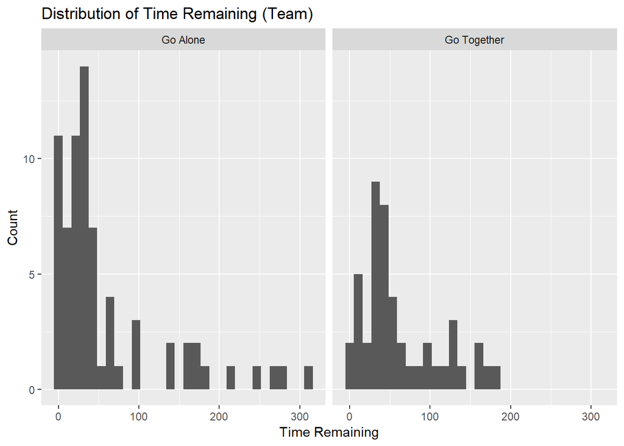

```r
y_label_team <- "Count"
x_label_team <- params$dependent_response_name_WithSpace
title_response_team <- paste("Distribution of", params$dependent_response_name_WithSpace, "(Team)")
plot_name <- paste("Histogram_", params$dependent_response_name_NoSpace, "_Team.png", sep = "")
setwd(figure_directory)

plot_data_team <- team_data %>%
  select(params$dependent_response_team,
         params$dependent_response_DominateStrategy,
         Target)

ggplot(data = plot_data_team) +
  geom_histogram(aes_string(x = params$dependent_response_team), bins = 30) +
  facet_grid( . ~ .data[[params$dependent_response_DominateStrategy]]) +
  labs(title = title_response_team, x = x_label_team, y = y_label_team) +
  ggsave(filename = plot_name)
```

```r
# Information about the N values in each condition
tableData <- team_data %>%
  group_by(.data[[params$dependent_response_DominateStrategy]]) %>%
  summarise(N = length(.data[[params$dependent_response_team]]))

tableData %>%
  kable() %>%
  kable_styling()
```

| Dominate.Strategy | N |
| --- | --- |
| Go Alone | 71 |
| Go Together | 46 |

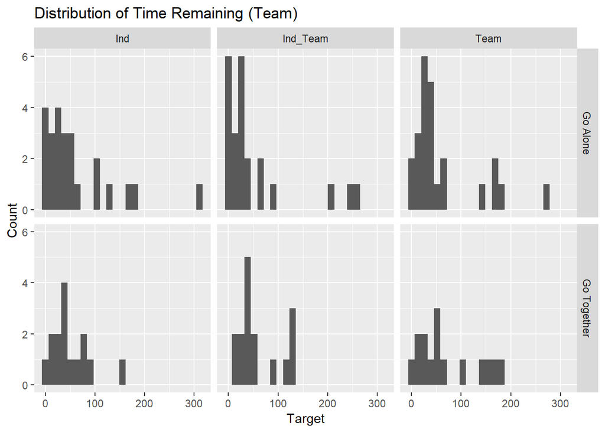

```r
y_label_team <- "Count"
x_label_team <- "Target"
title_response_team <- paste("Distribution of", params$dependent_response_name_WithSpace, "(Team)")
plot_name <- paste("Histogram_", params$dependent_response_name_NoSpace, "_ByTarget_Team.png", sep = "")
setwd(figure_directory)

plot_data_team <- team_data %>%
  select(params$dependent_response_team,
         params$dependent_response_DominateStrategy,
         Target)

ggplot(data = plot_data_team) +
  geom_histogram(aes_string(x = params$dependent_response_team), bins = 25) +
  facet_grid(.data[[params$dependent_response_DominateStrategy]] ~ Target) +
  labs(title = title_response_team, x = x_label_team, y = y_label_team) +
  ggsave(filename = plot_name)
```

```r
# Information about the N values in each condition
tableData <- team_data %>%
  group_by(Target, .data[[params$dependent_response_DominateStrategy]]) %>%
  summarise(N = length(.data[[params$dependent_response_team]]))

tableData %>%
  kable() %>%
  kable_styling()
```

| Target | Dominate.Strategy | N |
| --- | --- | --- |
| Ind | Go Alone | 24 |
| Ind | Go Together | 15 |
| Ind_Team | Go Alone | 23 |
| Ind_Team | Go Together | 16 |
| Team | Go Alone | 24 |
| Team | Go Together | 15 |

I see no obvious pattern.

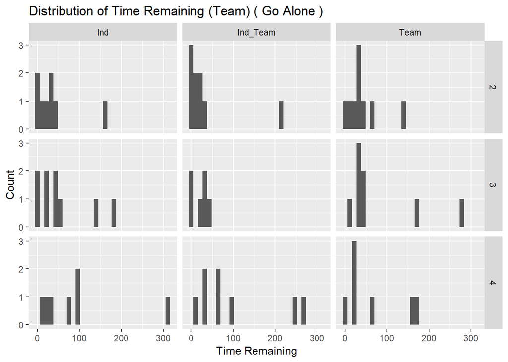

```r
y_label_team <- "Count"
x_label_team <- params$dependent_response_name_WithSpace
setwd(figure_directory)

plot_data_team <- team_data %>%
  select(params$dependent_response_team,
         params$dependent_response_DominateStrategy,
         Target,
         SessionOrder)

# Generate data by strategy
GA_plot_data_team <- plot_data_team %>%
  filter(.data[[params$dependent_response_DominateStrategy]] == params$Strategy_GA_name_WithSpace)

GT_plot_data_team <- plot_data_team %>%
  filter(.data[[params$dependent_response_DominateStrategy]] == params$Strategy_GT_name_WithSpace)

# Plot
 # GA
ggplot(data = GA_plot_data_team) +
  geom_histogram(aes_string(x = params$dependent_response_team), bins = 30) +
  labs(title = paste("Distribution of", params$dependent_response_name_WithSpace, "(Team)","(", params$Strategy_GA_name_WithSpace ,")" ), x = x_label_team, y = y_label_team) +
  facet_grid( SessionOrder ~ Target) +
  ggsave(filename = paste("Histogram_", params$dependent_response_name_NoSpace, "_ByTarget_BySessionOrder_", params$Strategy_GA_name_NoSpace, "_Team.png", sep = ""))
```

```r
    # Information about the N values in each condition
GA_tableData <- GA_plot_data_team %>%
  select(params$dependent_response_team, Target, SessionOrder) %>%
  group_by(Target, SessionOrder) %>%
  summarise(N = length(.data[[params$dependent_response_team]]))

GA_tableData %>%
  kable(caption = paste("Data for ", params$Strategy_GA_name_WithSpace)) %>%
  kable_styling()
```

Data for Go Alone

| Target | SessionOrder | N |
| --- | --- | --- |
| Ind | 2 | 8 |
| Ind | 3 | 9 |
| Ind | 4 | 7 |
| Ind_Team | 2 | 9 |
| Ind_Team | 3 | 6 |
| Ind_Team | 4 | 8 |
| Team | 2 | 9 |
| Team | 3 | 8 |
| Team | 4 | 7 |

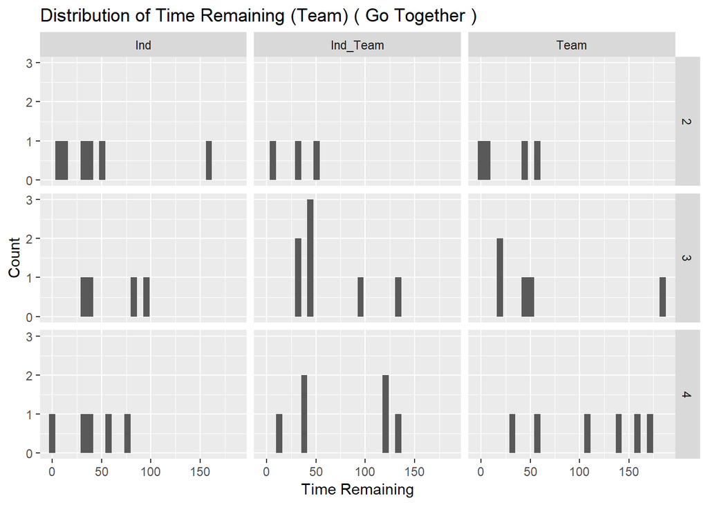

```r
 # GT
ggplot(data = GT_plot_data_team) +
  geom_histogram(aes_string(x = params$dependent_response_team), bins = 30) +
  labs(title = paste("Distribution of", params$dependent_response_name_WithSpace, "(Team)","(", params$Strategy_GT_name_WithSpace ,")" ), x = x_label_team, y = y_label_team) +
  facet_grid( SessionOrder ~ Target) +
  ggsave(filename = paste("Histogram_", params$dependent_response_name_NoSpace, "_ByTarget_BySessionOrder_", params$Strategy_GT_name_NoSpace, "_Team.png", sep = ""))
```

```r
    # Information about the N values in each condition
GT_tableData <- GT_plot_data_team %>%
  select(params$dependent_response_team, Target, SessionOrder) %>%
  group_by(Target, SessionOrder) %>%
  summarise(N = length(.data[[params$dependent_response_team]]))

GT_tableData %>%
  kable(caption = paste("Data for ", params$Strategy_GT_name_WithSpace)) %>%
  kable_styling()
```

Data for Go Together

| Target | SessionOrder | N |
| --- | --- | --- |
| Ind | 2 | 6 |
| Ind | 3 | 4 |
| Ind | 4 | 5 |
| Ind_Team | 2 | 3 |
| Ind_Team | 3 | 7 |
| Ind_Team | 4 | 6 |
| Team | 2 | 4 |
| Team | 3 | 5 |
| Team | 4 | 6 |

In the Go Together group, session 4, it looks like there is are a number of teams that have a lt of time remaining. However, I see no obvious pattern.

## Individual

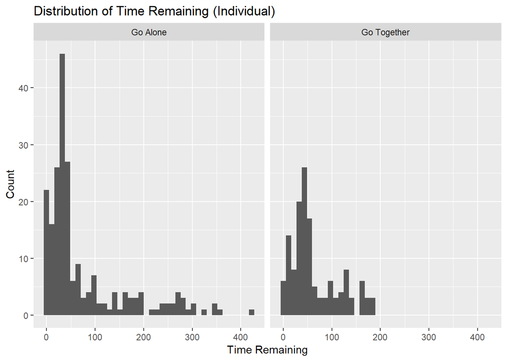

```r
y_label_ind <- "Count"
x_label_ind <- params$dependent_response_name_WithSpace
title_response_ind <- paste("Distribution of", params$dependent_response_name_WithSpace, "(Individual)")
plot_name <- paste("Histogram_", params$dependent_response_name_NoSpace, "_Ind.png", sep = "")
setwd(figure_directory)

plot_data_ind <- ind_data %>%
  select(params$dependent_response_ind, params$dependent_response_DominateStrategy, Target)

ggplot(data = plot_data_ind) +
  geom_histogram(aes_string(x = params$dependent_response_ind), bins = 40) +
  facet_grid(. ~ .data[[params$dependent_response_DominateStrategy]]) +
  labs(title = title_response_ind, x = x_label_ind, y = y_label_ind) +
  ggsave(filename = plot_name)
```

```r
# Information about the N values in each condition
tableData <- plot_data_ind %>%
  group_by(.data[[params$dependent_response_DominateStrategy]]) %>%
  summarise(N = length(.data[[params$dependent_response_ind]]))

tableData %>%
  kable() %>%
  kable_styling()
```

| Dominate.Strategy | N |
| --- | --- |
| Go Alone | 213 |
| Go Together | 138 |

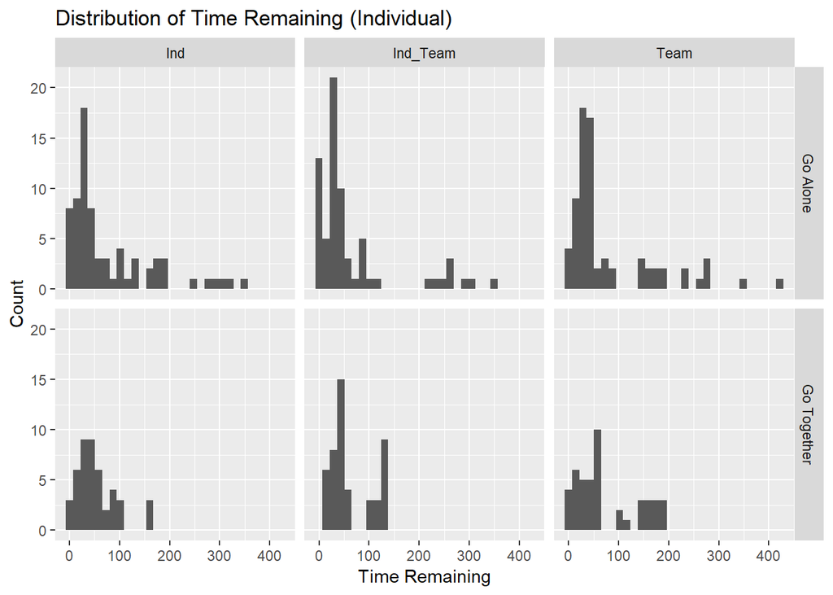

```r
y_label_ind <- "Count"
x_label_ind <- params$dependent_response_name_WithSpace
title_response_ind <- paste("Distribution of", params$dependent_response_name_WithSpace, "(Individual)")
plot_name <- paste("Histogram_", params$dependent_response_name_NoSpace, "_ByTarget_Ind.png", sep = "")
setwd(figure_directory)

plot_data_ind <- ind_data %>%
  select(params$dependent_response_ind, params$dependent_response_DominateStrategy, Target)

ggplot(data = plot_data_ind) +
  geom_histogram(aes_string(x = params$dependent_response_ind), bins = 30) +
  facet_grid(.data[[params$dependent_response_DominateStrategy]] ~ Target) +
  labs(title = title_response_ind, x = x_label_ind, y = y_label_ind) +
  ggsave(filename = plot_name)
```

```r
# Information about the N values in each condition
tableData <- ind_data %>%
  group_by(Target, .data[[params$dependent_response_DominateStrategy]]) %>%
  summarise(N = length(.data[[params$dependent_response_ind]]))

tableData %>%
  kable() %>%
  kable_styling()
```

| Target | Dominate.Strategy | N |
| --- | --- | --- |
| Ind | Go Alone | 72 |
| Ind | Go Together | 45 |
| Ind_Team | Go Alone | 69 |
| Ind_Team | Go Together | 48 |
| Team | Go Alone | 72 |
| Team | Go Together | 45 |

The distributions when grouped by target and strategy is similar to the overall distribution.

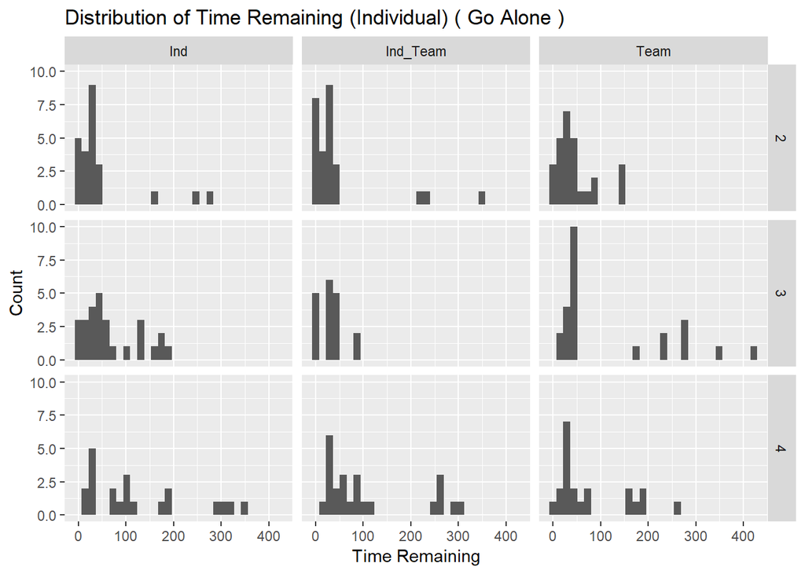

```r
y_label_ind <- "Count"
x_label_ind <- params$dependent_response_name_WithSpace
setwd(figure_directory)

plot_data_ind <- ind_data %>%
  select(params$dependent_response_ind,
         params$dependent_response_DominateStrategy,
         Target,
         SessionOrder)

# Generate data by strategy
GA_plot_data_ind <- plot_data_ind %>%
  filter(.data[[params$dependent_response_DominateStrategy]] == params$Strategy_GA_name_WithSpace)

GT_plot_data_ind <- plot_data_ind %>%
  filter(.data[[params$dependent_response_DominateStrategy]] == params$Strategy_GT_name_WithSpace)

# plot
  # GA
ggplot(data = GA_plot_data_ind) +
  geom_histogram(aes_string(x = params$dependent_response_ind), bins = 30) +
  facet_grid(SessionOrder ~ Target) +
  labs(title = paste("Distribution of", params$dependent_response_name_WithSpace, "(Individual)","(", params$Strategy_GA_name_WithSpace ,")" ), x = x_label_ind, y = y_label_ind) +
  ggsave(filename = paste("Histogram_", params$dependent_response_name_NoSpace, "_ByTarget_BySessionOrder_", params$Strategy_GA_name_NoSpace, "_Ind.png", sep = ""))
```

```r
    # Information about the N values in each condition
GA_tableData <- GA_plot_data_ind %>%
  select(params$dependent_response_ind, Target, SessionOrder) %>%
  group_by(Target, SessionOrder) %>%
  summarise(N = length(.data[[params$dependent_response_ind]]))

GA_tableData %>%
  kable(caption =  paste("Data for ", params$Strategy_GA_name_WithSpace)) %>%
  kable_styling()
```

Data for Go Alone

| Target | SessionOrder | N |
| --- | --- | --- |
| Ind | 2 | 24 |
| Ind | 3 | 27 |
| Ind | 4 | 21 |
| Ind_Team | 2 | 27 |
| Ind_Team | 3 | 18 |
| Ind_Team | 4 | 24 |
| Team | 2 | 27 |
| Team | 3 | 24 |
| Team | 4 | 21 |

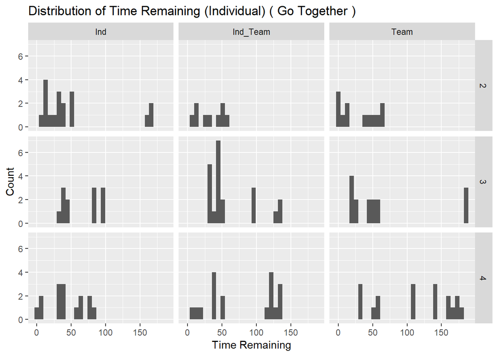

```r
  # GT
ggplot(data = GT_plot_data_ind) +
  geom_histogram(aes_string(x = params$dependent_response_ind), bins = 30) +
  facet_grid(SessionOrder ~ Target) +
  labs(title = paste("Distribution of", params$dependent_response_name_WithSpace, "(Individual)","(", params$Strategy_GT_name_WithSpace ,")" ), x = x_label_ind, y = y_label_ind) +
  ggsave(filename = paste("Histogram_", params$dependent_response_name_NoSpace, "_ByTarget_BySessionOrder_", params$Strategy_GT_name_NoSpace, "_Ind.png", sep = ""))
```

```r
# Information about the N values in each condition
GT_tableData <- GT_plot_data_ind %>%
  select(params$dependent_response_ind, Target, SessionOrder) %>%
  group_by(Target, SessionOrder) %>%
  summarise(N = length(.data[[params$dependent_response_ind]]))

GT_tableData %>%
  kable(caption = paste("Data for ", params$Strategy_GT_name_WithSpace)) %>%
  kable_styling()
```

Data for Go Together

| Target | SessionOrder | N |
| --- | --- | --- |
| Ind | 2 | 18 |
| Ind | 3 | 12 |
| Ind | 4 | 15 |
| Ind_Team | 2 | 9 |
| Ind_Team | 3 | 21 |
| Ind_Team | 4 | 18 |
| Team | 2 | 12 |
| Team | 3 | 15 |
| Team | 4 | 18 |

In the Go Alone group, the bulk of time remaining seems only move slightly, if at all, to the right. Where as the distribution of time reamining in the Go Togetherseems to flatten over time.

## Summary

Overall, there were no obvious patterns at the team level. At the individual level, when grouped by Target, session order, and Go Together, the distributions faltten over time, as oppsed to staying the same. The distribution at the individiual level, grouped by target, session order, and Go Alone, seems to change only a little but not much.

I am getting the sense that strategy may have a significant effect on the time remaining, even if it is small. However, there may not be enough teams to detect the effect.

# Q: Is there an interaction between the Target and Session Order for the *Time Remaining* that is statistically significant?

I am interested in determining if a linear mixed effect model should include the interaction effect between the Target and Session Order variable.

A note on the effect size ($R^2$). This method generates two types of ($R^2$) values called marginal ($R_{m}^2$) and conditional ($R_{c}^2$) effect size. The $R_{m}^2$ calculates how much of the variance is described by the fixed effect variables (feedback condition and session order) while the $R_{c}^2$ calculates how much of the variance is described by both the fixed and random effect variables.

## Full Models Used for Team and Individual

The next two sections below describe the full model for team and individual level analysis. Five models were fitted and then compared. One model was the null model, one model was the full model, and the last three are a subset of the full model.

### Team Full Model

$$y_{ijt} = \mu + \alpha_{i} + \beta_{j} + \alpha_{i} \beta_{j} + \gamma_{t} + \epsilon_{ijt}$$

### Individual Team Full Model

$$y_{ijtp} = \mu + \alpha_{i} + \beta_{j} + \alpha_{i} \beta_{j} + \gamma_{t} + \theta_{p} + \epsilon_{ijtp}$$

## Team

### GA

```r
# Data to fit
data_modified_team <- team_data %>%
  select(TeamScore,
         params$dependent_response_team,
         params$dependent_response_DominateStrategy,
         Target,
         SessionOrder,
         Team)

# Generate models with variable response
GA_data_focus_team <- data_modified_team %>%
  filter(.data[[params$dependent_response_DominateStrategy]] == params$Strategy_GA_name_WithSpace)

model.null <- model_data_Target_Session(df = GA_data_focus_team, dependent =  params$dependent_response_team, model.type =  "null", is.team = TRUE, is.robust =FALSE)
model.All <- model_data_Target_Session(df = GA_data_focus_team, dependent =  params$dependent_response_team, model.type =  "All", is.team = TRUE, is.robust = FALSE)
model.NoInteraction <- model_data_Target_Session(df = GA_data_focus_team, dependent =  params$dependent_response_team, model.type =  "NoInteraction", is.team = TRUE, is.robust = FALSE)
model.NoInteraction.NoTarget <- model_data_Target_Session(df = GA_data_focus_team, dependent =  params$dependent_response_team, model.type =  "NoInteraction_NoTarget", is.team = TRUE, is.robust = FALSE)
model.NoInteraction.NoSession <- model_data_Target_Session(df = GA_data_focus_team, dependent =  params$dependent_response_team, model.type =  "NoInteraction_NoSession", is.team = TRUE, is.robust = FALSE)

# There is an option to compare all the models with the anova(). However, the function does not compare all models to model.null
anova(model.null,
      model.All) %>%
  kable(caption = "ANOVA: Null and All") %>%
  kable_styling()
```

```
## refitting model(s) with ML (instead of REML)
```

ANOVA: Null and All

|  | Df | AIC | BIC | logLik | deviance | Chisq | Chi Df | Pr(>Chisq) |
| --- | --- | --- | --- | --- | --- | --- | --- | --- |
| model.null | 3 | 778.0651 | 784.8531 | -386.0325 | 772.0651 | NA | NA | NA |
| model.All | 11 | 768.5713 | 793.4608 | -373.2857 | 746.5713 | 25.49376 | 8 | 0.0012815 |

```r
anova(model.null,
      model.NoInteraction) %>%
  kable(caption = "ANOVA: Null and No.Interaction") %>%
  kable_styling()
```

```
## refitting model(s) with ML (instead of REML)
```

ANOVA: Null and No.Interaction

|  | Df | AIC | BIC | logLik | deviance | Chisq | Chi Df | Pr(>Chisq) |
| --- | --- | --- | --- | --- | --- | --- | --- | --- |
| model.null | 3 | 778.0651 | 784.8531 | -386.0325 | 772.0651 | NA | NA | NA |
| model.NoInteraction | 7 | 762.5300 | 778.3688 | -374.2650 | 748.5300 | 23.53504 | 4 | 9.9e-05 |

```r
anova(model.null,
      model.NoInteraction.NoTarget) %>%
  kable(caption = "ANOVA: Null and No.Interaction.No.Target") %>%
  kable_styling()
```

```
## refitting model(s) with ML (instead of REML)
```

ANOVA: Null and No.Interaction.No.Target

|  | Df | AIC | BIC | logLik | deviance | Chisq | Chi Df | Pr(>Chisq) |
| --- | --- | --- | --- | --- | --- | --- | --- | --- |
| model.null | 3 | 778.0651 | 784.8531 | -386.0325 | 772.0651 | NA | NA | NA |
| model.NoInteraction.NoTarget | 5 | 759.4804 | 770.7938 | -374.7402 | 749.4804 | 22.58473 | 2 | 1.25e-05 |

```r
anova(model.null,
      model.NoInteraction.NoSession) %>%
  kable(caption = "ANOVA: Null and No.Interaction.No.Session") %>%
  kable_styling()
```

```
## refitting model(s) with ML (instead of REML)
```

ANOVA: Null and No.Interaction.No.Session

|  | Df | AIC | BIC | logLik | deviance | Chisq | Chi Df | Pr(>Chisq) |
| --- | --- | --- | --- | --- | --- | --- | --- | --- |
| model.null | 3 | 778.0651 | 784.8531 | -386.0325 | 772.0651 | NA | NA | NA |
| model.NoInteraction.NoSession | 5 | 781.4341 | 792.7475 | -385.7170 | 771.4341 | 0.6309918 | 2 | 0.7294271 |

The following models were significantly different from the null model: model.All, model.NoInteraction, model.NoInteraction.NoTarget.

model.All: Session Order, Target, and the interaction are included in this model.

model.NoInteraction: Session order and target are the fixed effects in this model.

model.NoInteraction.NoTarget: Session order is the only fixed effect in this model.

```r
# Data to fit
data_modified_team <- team_data %>%
  select(TeamScore,
         params$dependent_response_team,
         params$dependent_response_DominateStrategy,
         Target,
         SessionOrder,
         Team)

# Generate models with variable response
GA_data_focus_team <- data_modified_team %>%
  filter(.data[[params$dependent_response_DominateStrategy]] == params$Strategy_GA_name_WithSpace)

model.All <- model_data_Target_Session(df = GA_data_focus_team, dependent =  params$dependent_response_team, model.type =  "All", is.team = TRUE, is.robust = FALSE)
model.NoInteraction <- model_data_Target_Session(df = GA_data_focus_team, dependent =  params$dependent_response_team, model.type =  "NoInteraction", is.team = TRUE, is.robust = FALSE)
model.NoInteraction.NoTarget <- model_data_Target_Session(df = GA_data_focus_team, dependent =  params$dependent_response_team, model.type =  "NoInteraction_NoTarget", is.team = TRUE, is.robust = FALSE)

# Compare all of the models
anova(model.All,
      model.NoInteraction) %>%
  kable(caption = "ANOVA: model.All and model.NoInteraction") %>%
  kable_styling()
```

```
## refitting model(s) with ML (instead of REML)
```

ANOVA: model.All and model.NoInteraction

|  | Df | AIC | BIC | logLik | deviance | Chisq | Chi Df | Pr(>Chisq) |
| --- | --- | --- | --- | --- | --- | --- | --- | --- |
| model.NoInteraction | 7 | 762.5300 | 778.3688 | -374.2650 | 748.5300 | NA | NA | NA |
| model.All | 11 | 768.5713 | 793.4608 | -373.2857 | 746.5713 | 1.958716 | 4 | 0.743352 |

```r
anova(model.All,
      model.NoInteraction.NoTarget) %>%
  kable(caption = "ANOVA: model.All and model.NoInteraction.NoTarget") %>%
  kable_styling()
```

```
## refitting model(s) with ML (instead of REML)
```

ANOVA: model.All and model.NoInteraction.NoTarget

|  | Df | AIC | BIC | logLik | deviance | Chisq | Chi Df | Pr(>Chisq) |
| --- | --- | --- | --- | --- | --- | --- | --- | --- |
| model.NoInteraction.NoTarget | 5 | 759.4804 | 770.7938 | -374.7402 | 749.4804 | NA | NA | NA |
| model.All | 11 | 768.5713 | 793.4608 | -373.2857 | 746.5713 | 2.909032 | 6 | 0.8201746 |

```r
anova(model.NoInteraction,
      model.NoInteraction.NoTarget) %>%
  kable(caption = "ANOVA: model.NoInteraction and model.NoInteraction.NoTarget") %>%
  kable_styling()
```

```
## refitting model(s) with ML (instead of REML)
```

ANOVA: model.NoInteraction and model.NoInteraction.NoTarget

|  | Df | AIC | BIC | logLik | deviance | Chisq | Chi Df | Pr(>Chisq) |
| --- | --- | --- | --- | --- | --- | --- | --- | --- |
| model.NoInteraction.NoTarget | 5 | 759.4804 | 770.7938 | -374.7402 | 749.4804 | NA | NA | NA |
| model.NoInteraction | 7 | 762.5300 | 778.3688 | -374.2650 | 748.5300 | 0.9503157 | 2 | 0.6217869 |

Overall, model.All is not signifcantly different from model.NoInteraction.NoTarget or model.NoInteraction, indicating that the interaction effect can be ignored. The model model.NoInteraction is not significantly different from model.NoInteraction.NoTarget. However, the AIC and the BIC values are very similar.

```r
# Data to fit
data_modified_team <- team_data %>%
  select(TeamScore,
         params$dependent_response_team,
         params$dependent_response_DominateStrategy,
         Target,
         SessionOrder,
         Team)

# Generate models with variable response
GA_data_focus_team <- data_modified_team %>%
  filter(.data[[params$dependent_response_DominateStrategy]] == params$Strategy_GA_name_WithSpace)

model.NoInteraction <- model_data_Target_Session(df = GA_data_focus_team, dependent =  params$dependent_response_team, model.type =  "NoInteraction", is.team = TRUE, is.robust = FALSE)
model.NoInteraction.NoTarget <- model_data_Target_Session(df = GA_data_focus_team, dependent =  params$dependent_response_team, model.type =  "NoInteraction_NoTarget", is.team = TRUE, is.robust = FALSE)

# Effect size (R^2)

r.squaredGLMM(model.NoInteraction.NoTarget) %>%
  kable(caption = "Table: Effect size for *No Interaction and No Target*") %>%
   kable_styling(full_width = F)
```

Table: Effect size for *No Interaction and No Target*

| R2m | R2c |
| --- | --- |
| 0.0794581 | 0.8135268 |

```r
r.squaredGLMM(model.NoInteraction) %>%
  kable(caption = "Table: Effect size for *No Interaction*") %>%
   kable_styling(full_width = F)
```

Table: Effect size for *No Interaction*

| R2m | R2c |
| --- | --- |
| 0.0804038 | 0.8092349 |

I see no noticeable difference. The rule of thumb is to use the simplest model to represent the data. However, in this analysis I will examine **model.NoInteraction.NoTarget** and **model.NoInteraction** because the AIC and BIC values are close and the effect sizes are close.

### GT

```r
# Data to fit
data_modified_team <- team_data %>%
  select(TeamScore,
         params$dependent_response_team,
         params$dependent_response_DominateStrategy,
         Target,
         SessionOrder,
         Team)

# Generate models with variable response
GT_data_focus_team <- data_modified_team %>%
  filter(.data[[params$dependent_response_DominateStrategy]] == params$Strategy_GT_name_WithSpace)

model.null <- model_data_Target_Session(df = GT_data_focus_team, dependent =  params$dependent_response_team, model.type =  "null", is.team = TRUE, is.robust =FALSE)
model.All <- model_data_Target_Session(df = GT_data_focus_team, dependent =  params$dependent_response_team, model.type =  "All", is.team = TRUE, is.robust = FALSE)
model.NoInteraction <- model_data_Target_Session(df = GT_data_focus_team, dependent =  params$dependent_response_team, model.type =  "NoInteraction", is.team = TRUE, is.robust = FALSE)
model.NoInteraction.NoTarget <- model_data_Target_Session(df = GT_data_focus_team, dependent =  params$dependent_response_team, model.type =  "NoInteraction_NoTarget", is.team = TRUE, is.robust = FALSE)
model.NoInteraction.NoSession <- model_data_Target_Session(df = GT_data_focus_team, dependent =  params$dependent_response_team, model.type =  "NoInteraction_NoSession", is.team = TRUE, is.robust = FALSE)

# There is an option to compare all the models with the anova(). However, the function does not compare all models to model.null
anova(model.null,
      model.All) %>%
  kable(caption = "ANOVA: Null and All") %>%
  kable_styling()
```

```
## refitting model(s) with ML (instead of REML)
```

ANOVA: Null and All

|  | Df | AIC | BIC | logLik | deviance | Chisq | Chi Df | Pr(>Chisq) |
| --- | --- | --- | --- | --- | --- | --- | --- | --- |
| model.null | 3 | 489.3308 | 494.8167 | -241.6654 | 483.3308 | NA | NA | NA |
| model.All | 11 | 484.8339 | 504.9489 | -231.4169 | 462.8339 | 20.49695 | 8 | 0.0086109 |

```r
anova(model.null,
      model.NoInteraction) %>%
  kable(caption = "ANOVA: Null and No.Interaction") %>%
  kable_styling()
```

```
## refitting model(s) with ML (instead of REML)
```

ANOVA: Null and No.Interaction

|  | Df | AIC | BIC | logLik | deviance | Chisq | Chi Df | Pr(>Chisq) |
| --- | --- | --- | --- | --- | --- | --- | --- | --- |
| model.null | 3 | 489.3308 | 494.8167 | -241.6654 | 483.3308 | NA | NA | NA |
| model.NoInteraction | 7 | 483.2075 | 496.0080 | -234.6038 | 469.2075 | 14.1233 | 4 | 0.0069117 |

```r
anova(model.null,
      model.NoInteraction.NoTarget) %>%
  kable(caption = "ANOVA: Null and No.Interaction.No.Target") %>%
  kable_styling()
```

```
## refitting model(s) with ML (instead of REML)
```

ANOVA: Null and No.Interaction.No.Target

|  | Df | AIC | BIC | logLik | deviance | Chisq | Chi Df | Pr(>Chisq) |
| --- | --- | --- | --- | --- | --- | --- | --- | --- |
| model.null | 3 | 489.3308 | 494.8167 | -241.6654 | 483.3308 | NA | NA | NA |
| model.NoInteraction.NoTarget | 5 | 481.4621 | 490.6053 | -235.7310 | 471.4621 | 11.86875 | 2 | 0.0026469 |

```r
anova(model.null,
      model.NoInteraction.NoSession) %>%
  kable(caption = "ANOVA: Null and No.Interaction.No.Session") %>%
  kable_styling()
```

```
## refitting model(s) with ML (instead of REML)
```

ANOVA: Null and No.Interaction.No.Session

|  | Df | AIC | BIC | logLik | deviance | Chisq | Chi Df | Pr(>Chisq) |
| --- | --- | --- | --- | --- | --- | --- | --- | --- |
| model.null | 3 | 489.3308 | 494.8167 | -241.6654 | 483.3308 | NA | NA | NA |
| model.NoInteraction.NoSession | 5 | 490.6936 | 499.8368 | -240.3468 | 480.6936 | 2.637183 | 2 | 0.2675118 |

The following models were significantly different from the null model: model.All, model.NoInteraction, model.NoInteraction.NoTarget.

model.All: Session Order, Target, and the interaction are included in this model.

model.NoInteraction: Session order and target are the fixed effects in this model.

model.NoInteraction.NoTarget: Session order is the only fixed effect in this model.

```r
# Data to fit
data_modified_team <- team_data %>%
  select(TeamScore,
         params$dependent_response_team,
         params$dependent_response_DominateStrategy,
         Target,
         SessionOrder,
         Team)

# Generate models with variable response
GT_data_focus_team <- data_modified_team %>%
  filter(.data[[params$dependent_response_DominateStrategy]] == params$Strategy_GT_name_WithSpace)

model.All <- model_data_Target_Session(df = GT_data_focus_team, dependent =  params$dependent_response_team, model.type =  "All", is.team = TRUE, is.robust = FALSE)
model.NoInteraction <- model_data_Target_Session(df = GT_data_focus_team, dependent =  params$dependent_response_team, model.type =  "NoInteraction", is.team = TRUE, is.robust = FALSE)
model.NoInteraction.NoTarget <- model_data_Target_Session(df = GT_data_focus_team, dependent =  params$dependent_response_team, model.type =  "NoInteraction_NoTarget", is.team = TRUE, is.robust = FALSE)

# Compare all of the models
anova(model.All,
      model.NoInteraction) %>%
  kable(caption = "ANOVA: model.All and model.NoInteraction") %>%
  kable_styling()
```

```
## refitting model(s) with ML (instead of REML)
```

ANOVA: model.All and model.NoInteraction

|  | Df | AIC | BIC | logLik | deviance | Chisq | Chi Df | Pr(>Chisq) |
| --- | --- | --- | --- | --- | --- | --- | --- | --- |
| model.NoInteraction | 7 | 483.2075 | 496.0080 | -234.6038 | 469.2075 | NA | NA | NA |
| model.All | 11 | 484.8339 | 504.9489 | -231.4169 | 462.8339 | 6.37365 | 4 | 0.1729276 |

```r
anova(model.All,
      model.NoInteraction.NoTarget) %>%
  kable(caption = "ANOVA: model.All and model.NoInteraction.NoTarget") %>%
  kable_styling()
```

```
## refitting model(s) with ML (instead of REML)
```

ANOVA: model.All and model.NoInteraction.NoTarget

|  | Df | AIC | BIC | logLik | deviance | Chisq | Chi Df | Pr(>Chisq) |
| --- | --- | --- | --- | --- | --- | --- | --- | --- |
| model.NoInteraction.NoTarget | 5 | 481.4621 | 490.6053 | -235.7310 | 471.4621 | NA | NA | NA |
| model.All | 11 | 484.8339 | 504.9489 | -231.4169 | 462.8339 | 8.628203 | 6 | 0.1955924 |

```r
anova(model.NoInteraction,
      model.NoInteraction.NoTarget) %>%
  kable(caption = "ANOVA: model.NoInteraction and model.NoInteraction.NoTarget") %>%
  kable_styling()
```

```
## refitting model(s) with ML (instead of REML)
```

ANOVA: model.NoInteraction and model.NoInteraction.NoTarget

|  | Df | AIC | BIC | logLik | deviance | Chisq | Chi Df | Pr(>Chisq) |
| --- | --- | --- | --- | --- | --- | --- | --- | --- |
| model.NoInteraction.NoTarget | 5 | 481.4621 | 490.6053 | -235.7310 | 471.4621 | NA | NA | NA |
| model.NoInteraction | 7 | 483.2075 | 496.0080 | -234.6038 | 469.2075 | 2.254553 | 2 | 0.3239142 |

Overall, model.All is not signifcantly different from model.NoInteraction.NoTarget or model.NoInteraction, indicating that the interaction effect can be ignored. The model model.NoInteraction is not significantly different from model.NoInteraction.NoTarget. However, the AIC and the BIC values are very similar.

```r
# Data to fit
data_modified_team <- team_data %>%
  select(TeamScore,
         params$dependent_response_team,
         params$dependent_response_DominateStrategy,
         Target,
         SessionOrder,
         Team)

# Generate models with variable response
GT_data_focus_team <- data_modified_team %>%
  filter(.data[[params$dependent_response_DominateStrategy]] == params$Strategy_GT_name_WithSpace)

model.NoInteraction <- model_data_Target_Session(df = GT_data_focus_team, dependent =  params$dependent_response_team, model.type =  "NoInteraction", is.team = TRUE, is.robust = FALSE)
model.NoInteraction.NoTarget <- model_data_Target_Session(df = GT_data_focus_team, dependent =  params$dependent_response_team, model.type =  "NoInteraction_NoTarget", is.team = TRUE, is.robust = FALSE)

# Effect size (R^2)

r.squaredGLMM(model.NoInteraction.NoTarget) %>%
  kable(caption = "Table: Effect size for *No Interaction and No Target*") %>%
   kable_styling(full_width = F)
```

Table: Effect size for *No Interaction and No Target*

| R2m | R2c |
| --- | --- |
| 0.1327687 | 0.6184722 |

```r
r.squaredGLMM(model.NoInteraction) %>%
  kable(caption = "Table: Effect size for *No Interaction*") %>%
   kable_styling(full_width = F)
```

Table: Effect size for *No Interaction*

| R2m | R2c |
| --- | --- |
| 0.1450223 | 0.6185274 |

I see no noticeable difference. The rule of thumb is to use the simplest model to represent the data. However, in this analysis I will examine **model.NoInteraction.NoTarget** and **model.NoInteraction** because the AIC and BIC values are close and the effect sizes are close.

## Individual

### GA

```r
# Data to model
data_modified_ind <- ind_data %>%
  select(params$dependent_response_ind,
         params$dependent_response_DominateStrategy,
         Target,
         SessionOrder,
         Team,
         Player_ID)

# Generate models with variable response
GA_data_focus_ind <- data_modified_ind %>%
  filter(.data[[params$dependent_response_DominateStrategy]] == params$Strategy_GA_name_WithSpace)

model.null <- model_data_Target_Session(df = GA_data_focus_ind, dependent =  params$dependent_response_ind, model.type =  "null", is.team = FALSE, is.robust = FALSE)
```

```
## boundary (singular) fit: see ?isSingular
```

```r
model.All <- model_data_Target_Session(df = GA_data_focus_ind, dependent =  params$dependent_response_ind, model.type =  "All", is.team = FALSE, is.robust = FALSE)
```

```
## boundary (singular) fit: see ?isSingular
```

```r
model.NoInteraction <- model_data_Target_Session(df = GA_data_focus_ind, dependent =  params$dependent_response_ind, model.type =  "NoInteraction", is.team = FALSE, is.robust = FALSE)
```

```
## boundary (singular) fit: see ?isSingular
```

```r
model.NoInteraction.NoTarget <- model_data_Target_Session(df = GA_data_focus_ind, dependent =  params$dependent_response_ind, model.type =  "NoInteraction_NoTarget", is.team = FALSE, is.robust = FALSE)
```

```
## boundary (singular) fit: see ?isSingular
```

```r
model.NoInteraction.NoSession <- model_data_Target_Session(df = GA_data_focus_ind, dependent =  params$dependent_response_ind, model.type =  "NoInteraction_NoSession", is.team = FALSE, is.robust = FALSE)
```

```
## boundary (singular) fit: see ?isSingular
```

```r
# There is an option to compare all the models with the anova(). However, the function does not compare all models to model.null
anova(model.null,
      model.All) %>%
  kable(caption = "ANOVA: model.null and model.All") %>%
  kable_styling()
```

```
## refitting model(s) with ML (instead of REML)
```

ANOVA: model.null and model.All

|  | Df | AIC | BIC | logLik | deviance | Chisq | Chi Df | Pr(>Chisq) |
| --- | --- | --- | --- | --- | --- | --- | --- | --- |
| model.null | 4 | 2333.225 | 2346.670 | -1162.612 | 2325.225 | NA | NA | NA |
| model.All | 12 | 2285.730 | 2326.065 | -1130.865 | 2261.730 | 63.495 | 8 | 0 |

```r
anova(model.null,
      model.NoInteraction) %>%
  kable(caption = "ANOVA: model.null and model.NoInteraction") %>%
  kable_styling()
```

```
## refitting model(s) with ML (instead of REML)
```

ANOVA: model.null and model.NoInteraction

|  | Df | AIC | BIC | logLik | deviance | Chisq | Chi Df | Pr(>Chisq) |
| --- | --- | --- | --- | --- | --- | --- | --- | --- |
| model.null | 4 | 2333.225 | 2346.670 | -1162.612 | 2325.225 | NA | NA | NA |
| model.NoInteraction | 8 | 2279.080 | 2305.971 | -1131.540 | 2263.080 | 62.14429 | 4 | 0 |

```r
anova(model.null,
      model.NoInteraction.NoTarget) %>%
  kable(caption = "ANOVA: model.null and model.NoInteraction.NoTarget") %>%
  kable_styling()
```

```
## refitting model(s) with ML (instead of REML)
```

ANOVA: model.null and model.NoInteraction.NoTarget

|  | Df | AIC | BIC | logLik | deviance | Chisq | Chi Df | Pr(>Chisq) |
| --- | --- | --- | --- | --- | --- | --- | --- | --- |
| model.null | 4 | 2333.225 | 2346.670 | -1162.612 | 2325.225 | NA | NA | NA |
| model.NoInteraction.NoTarget | 6 | 2280.511 | 2300.678 | -1134.255 | 2268.511 | 56.71401 | 2 | 0 |

```r
anova(model.null,
      model.NoInteraction.NoSession) %>%
  kable(caption = "ANOVA: model.null and model.NoInteraction.NoSession") %>%
  kable_styling()
```

```
## refitting model(s) with ML (instead of REML)
```

ANOVA: model.null and model.NoInteraction.NoSession

|  | Df | AIC | BIC | logLik | deviance | Chisq | Chi Df | Pr(>Chisq) |
| --- | --- | --- | --- | --- | --- | --- | --- | --- |
| model.null | 4 | 2333.225 | 2346.670 | -1162.612 | 2325.225 | NA | NA | NA |
| model.NoInteraction.NoSession | 6 | 2332.246 | 2352.414 | -1160.123 | 2320.246 | 4.978224 | 2 | 0.0829836 |

The following models were significantly different from the null model: model.All, model.NoInteraction, model.NoInteraction.NoTarget.

model.All: Session Order, Target, and the interaction are included in this model.

model.NoInteraction: Session order and target are the fixed effects in this model.

model.NoInteraction.NoTarget: Session order is the only fixed effect in this model.

However, it is important to note that **model.NoInteraction.NoSession** is marginally significantly (p < 0.1) different from model.null.

```r
# Data to model
data_modified_ind <- ind_data %>%
  select(params$dependent_response_ind,
         params$dependent_response_DominateStrategy,
         Target,
         SessionOrder,
         Team,
         Player_ID)

# Generate models with variable response
GA_data_focus_ind <- data_modified_ind %>%
  filter(.data[[params$dependent_response_DominateStrategy]] == params$Strategy_GA_name_WithSpace)

model.All <- model_data_Target_Session(df = GA_data_focus_ind, dependent =  params$dependent_response_ind, model.type =  "All", is.team = FALSE, is.robust = FALSE)
```

```
## boundary (singular) fit: see ?isSingular
```

```r
model.NoInteraction <- model_data_Target_Session(df = GA_data_focus_ind, dependent =  params$dependent_response_ind, model.type =  "NoInteraction", is.team = FALSE, is.robust = FALSE)
```

```
## boundary (singular) fit: see ?isSingular
```

```r
model.NoInteraction.NoTarget <- model_data_Target_Session(df = GA_data_focus_ind, dependent =  params$dependent_response_ind, model.type =  "NoInteraction_NoTarget", is.team = FALSE, is.robust = FALSE)
```

```
## boundary (singular) fit: see ?isSingular
```

```r
anova(model.All,
      model.NoInteraction) %>%
  kable(caption = "ANOVA: All and No.Interaction") %>%
  kable_styling()
```

```
## refitting model(s) with ML (instead of REML)
```

ANOVA: All and No.Interaction

|  | Df | AIC | BIC | logLik | deviance | Chisq | Chi Df | Pr(>Chisq) |
| --- | --- | --- | --- | --- | --- | --- | --- | --- |
| model.NoInteraction | 8 | 2279.08 | 2305.971 | -1131.540 | 2263.08 | NA | NA | NA |
| model.All | 12 | 2285.73 | 2326.065 | -1130.865 | 2261.73 | 1.350709 | 4 | 0.8527152 |

```r
anova(model.All,
      model.NoInteraction.NoTarget) %>%
  kable(caption = "ANOVA: All and NoInteraction.NoTarget") %>%
  kable_styling()
```

```
## refitting model(s) with ML (instead of REML)
```

ANOVA: All and NoInteraction.NoTarget

|  | Df | AIC | BIC | logLik | deviance | Chisq | Chi Df | Pr(>Chisq) |
| --- | --- | --- | --- | --- | --- | --- | --- | --- |
| model.NoInteraction.NoTarget | 6 | 2280.511 | 2300.678 | -1134.255 | 2268.511 | NA | NA | NA |
| model.All | 12 | 2285.730 | 2326.065 | -1130.865 | 2261.730 | 6.780994 | 6 | 0.3415766 |

```r
anova(model.NoInteraction,
      model.NoInteraction.NoTarget) %>%
  kable(caption = "ANOVA: No.Interaction and NoInteraction.NoTarget") %>%
  kable_styling()
```

```
## refitting model(s) with ML (instead of REML)
```

ANOVA: No.Interaction and NoInteraction.NoTarget

|  | Df | AIC | BIC | logLik | deviance | Chisq | Chi Df | Pr(>Chisq) |
| --- | --- | --- | --- | --- | --- | --- | --- | --- |
| model.NoInteraction.NoTarget | 6 | 2280.511 | 2300.678 | -1134.255 | 2268.511 | NA | NA | NA |
| model.NoInteraction | 8 | 2279.080 | 2305.971 | -1131.540 | 2263.080 | 5.430285 | 2 | 0.0661955 |

Overall, model.All is not signifcantly different from model.NoInteraction.NoTarget or model.NoInteraction, indicating that the interaction effect can be ignored. The model model.NoInteraction is not significantly different from model.NoInteraction.NoTarget. However, the AIC and the BIC values are very similar.

It is important to note that model.NoInteraction is **marginially significantly** different from the model.NoInteraction.NoTarget.

```r
# Data to model
data_modified_ind <- ind_data %>%
  select(params$dependent_response_ind,
         params$dependent_response_DominateStrategy,
         Target,
         SessionOrder,
         Team,
         Player_ID)

# Generate models with variable response
GA_data_focus_ind <- data_modified_ind %>%
  filter(.data[[params$dependent_response_DominateStrategy]] == params$Strategy_GA_name_WithSpace)

model.NoInteraction.NoTarget <- model_data_Target_Session(df = GA_data_focus_ind, dependent =  params$dependent_response_ind, model.type =  "NoInteraction_NoTarget", is.team = FALSE, is.robust = FALSE)
```

```
## boundary (singular) fit: see ?isSingular
```

```r
model.NoInteraction <- model_data_Target_Session(df = GA_data_focus_ind, dependent =  params$dependent_response_ind, model.type =  "NoInteraction", is.team = FALSE, is.robust = FALSE)
```

```
## boundary (singular) fit: see ?isSingular
```

```r
# Effect size (R^2)

r.squaredGLMM(model.NoInteraction) %>%
  kable(caption = "Table: Effect size for *No Interaction*") %>%
   kable_styling(full_width = F)
```

Table: Effect size for *No Interaction*

| R2m | R2c |
| --- | --- |
| 0.0823109 | 0.7725237 |

```r
r.squaredGLMM(model.NoInteraction.NoTarget) %>%
  kable(caption = "Table: Effect size for *No Interaction No Target*") %>%
   kable_styling(full_width = F)
```

Table: Effect size for *No Interaction No Target*

| R2m | R2c |
| --- | --- |
| 0.0784984 | 0.7687513 |

I see no noticeable difference. The rule of thumb is to use the simplest model to represent the data. However, in this analysis I will examine **model.NoInteraction.NoTarget** and **model.NoInteraction** because the AIC and BIC values are close and the effect sizes are close.

### GT

```r
# Data to model
data_modified_ind <- ind_data %>%
  select(params$dependent_response_ind,
         params$dependent_response_DominateStrategy,
         Target,
         SessionOrder,
         Team,
         Player_ID)

# Generate models with variable response
GT_data_focus_ind <- data_modified_ind %>%
  filter(.data[[params$dependent_response_DominateStrategy]] == params$Strategy_GT_name_WithSpace)

model.null <- model_data_Target_Session(df = GT_data_focus_ind, dependent =  params$dependent_response_ind, model.type =  "null", is.team = FALSE, is.robust = FALSE)
```

```
## boundary (singular) fit: see ?isSingular
```

```r
model.All <- model_data_Target_Session(df = GT_data_focus_ind, dependent =  params$dependent_response_ind, model.type =  "All", is.team = FALSE, is.robust = FALSE)
```

```
## boundary (singular) fit: see ?isSingular
```

```r
model.NoInteraction <- model_data_Target_Session(df = GT_data_focus_ind, dependent =  params$dependent_response_ind, model.type =  "NoInteraction", is.team = FALSE, is.robust = FALSE)
```

```
## boundary (singular) fit: see ?isSingular
```

```r
model.NoInteraction.NoTarget <- model_data_Target_Session(df = GT_data_focus_ind, dependent =  params$dependent_response_ind, model.type =  "NoInteraction_NoTarget", is.team = FALSE, is.robust = FALSE)
```

```
## boundary (singular) fit: see ?isSingular
```

```r
model.NoInteraction.NoSession <- model_data_Target_Session(df = GT_data_focus_ind, dependent =  params$dependent_response_ind, model.type =  "NoInteraction_NoSession", is.team = FALSE, is.robust = FALSE)
```

```
## boundary (singular) fit: see ?isSingular
```

```r
# There is an option to compare all the models with the anova(). However, the function does not compare all models to model.null
anova(model.null,
      model.All) %>%
  kable(caption = "ANOVA: model.null and model.All") %>%
  kable_styling()
```

```
## refitting model(s) with ML (instead of REML)
```

ANOVA: model.null and model.All

|  | Df | AIC | BIC | logLik | deviance | Chisq | Chi Df | Pr(>Chisq) |
| --- | --- | --- | --- | --- | --- | --- | --- | --- |
| model.null | 4 | 1402.835 | 1414.544 | -697.4174 | 1394.835 | NA | NA | NA |
| model.All | 12 | 1336.554 | 1371.681 | -656.2769 | 1312.554 | 82.281 | 8 | 0 |

```r
anova(model.null,
      model.NoInteraction) %>%
  kable(caption = "ANOVA: model.null and model.NoInteraction") %>%
  kable_styling()
```

```
## refitting model(s) with ML (instead of REML)
```

ANOVA: model.null and model.NoInteraction

|  | Df | AIC | BIC | logLik | deviance | Chisq | Chi Df | Pr(>Chisq) |
| --- | --- | --- | --- | --- | --- | --- | --- | --- |
| model.null | 4 | 1402.835 | 1414.544 | -697.4174 | 1394.835 | NA | NA | NA |
| model.NoInteraction | 8 | 1349.933 | 1373.351 | -666.9664 | 1333.933 | 60.90186 | 4 | 0 |

```r
anova(model.null,
      model.NoInteraction.NoTarget) %>%
  kable(caption = "ANOVA: model.null and model.NoInteraction.NoTarget") %>%
  kable_styling()
```

```
## refitting model(s) with ML (instead of REML)
```

ANOVA: model.null and model.NoInteraction.NoTarget

|  | Df | AIC | BIC | logLik | deviance | Chisq | Chi Df | Pr(>Chisq) |
| --- | --- | --- | --- | --- | --- | --- | --- | --- |
| model.null | 4 | 1402.835 | 1414.544 | -697.4174 | 1394.835 | NA | NA | NA |
| model.NoInteraction.NoTarget | 6 | 1354.774 | 1372.338 | -671.3872 | 1342.774 | 52.06042 | 2 | 0 |

```r
anova(model.null,
      model.NoInteraction.NoSession) %>%
  kable(caption = "ANOVA: model.null and model.NoInteraction.NoSession") %>%
  kable_styling()
```

```
## refitting model(s) with ML (instead of REML)
```

ANOVA: model.null and model.NoInteraction.NoSession

|  | Df | AIC | BIC | logLik | deviance | Chisq | Chi Df | Pr(>Chisq) |
| --- | --- | --- | --- | --- | --- | --- | --- | --- |
| model.null | 4 | 1402.835 | 1414.544 | -697.4174 | 1394.835 | NA | NA | NA |
| model.NoInteraction.NoSession | 6 | 1395.045 | 1412.609 | -691.5226 | 1383.045 | 11.78952 | 2 | 0.0027538 |

All of the models were significantly different from the null model: model.All, model.NoInteraction, model.NoInteraction.NoTarget.

model.All: Session Order, Target, and the interaction are included in this model.

model.NoInteraction: Session order and target are the fixed effects in this model.

model.NoInteraction.NoTarget: Session order is the only fixed effect in this model.

model.NoInteraction.NoSession: Target is the only fixed effect in this model.

```r
# Data to model
data_modified_ind <- ind_data %>%
  select(params$dependent_response_ind,
         params$dependent_response_DominateStrategy,
         Target,
         SessionOrder,
         Team,
         Player_ID)

# Generate models with variable response
GT_data_focus_ind <- data_modified_ind %>%
  filter(.data[[params$dependent_response_DominateStrategy]] == params$Strategy_GT_name_WithSpace)

model.All <- model_data_Target_Session(df = GT_data_focus_ind, dependent =  params$dependent_response_ind, model.type =  "All", is.team = FALSE, is.robust = FALSE)
```

```
## boundary (singular) fit: see ?isSingular
```

```r
model.NoInteraction <- model_data_Target_Session(df = GT_data_focus_ind, dependent =  params$dependent_response_ind, model.type =  "NoInteraction", is.team = FALSE, is.robust = FALSE)
```

```
## boundary (singular) fit: see ?isSingular
```

```r
model.NoInteraction.NoTarget <- model_data_Target_Session(df = GT_data_focus_ind, dependent =  params$dependent_response_ind, model.type =  "NoInteraction_NoTarget", is.team = FALSE, is.robust = FALSE)
```

```
## boundary (singular) fit: see ?isSingular
```

```r
model.NoInteraction.NoSession <- model_data_Target_Session(df = GT_data_focus_ind, dependent =  params$dependent_response_ind, model.type =  "NoInteraction_NoSession", is.team = FALSE, is.robust = FALSE)
```

```
## boundary (singular) fit: see ?isSingular
```

```r
anova(model.All,
      model.NoInteraction) %>%
  kable(caption = "ANOVA: All and No.Interaction") %>%
  kable_styling()
```

```
## refitting model(s) with ML (instead of REML)
```

ANOVA: All and No.Interaction

|  | Df | AIC | BIC | logLik | deviance | Chisq | Chi Df | Pr(>Chisq) |
| --- | --- | --- | --- | --- | --- | --- | --- | --- |
| model.NoInteraction | 8 | 1349.933 | 1373.351 | -666.9664 | 1333.933 | NA | NA | NA |
| model.All | 12 | 1336.554 | 1371.681 | -656.2769 | 1312.554 | 21.37913 | 4 | 0.0002663 |

```r
anova(model.All,
      model.NoInteraction.NoTarget) %>%
  kable(caption = "ANOVA: All and NoInteraction.NoTarget") %>%
  kable_styling()
```

```
## refitting model(s) with ML (instead of REML)
```

ANOVA: All and NoInteraction.NoTarget

|  | Df | AIC | BIC | logLik | deviance | Chisq | Chi Df | Pr(>Chisq) |
| --- | --- | --- | --- | --- | --- | --- | --- | --- |
| model.NoInteraction.NoTarget | 6 | 1354.774 | 1372.338 | -671.3872 | 1342.774 | NA | NA | NA |
| model.All | 12 | 1336.554 | 1371.681 | -656.2769 | 1312.554 | 30.22058 | 6 | 3.57e-05 |

```r
anova(model.All,
      model.NoInteraction.NoSession) %>%
  kable(caption = "ANOVA: All and model.NoInteraction.NoSession") %>%
  kable_styling()
```

```
## refitting model(s) with ML (instead of REML)
```

ANOVA: All and model.NoInteraction.NoSession

|  | Df | AIC | BIC | logLik | deviance | Chisq | Chi Df | Pr(>Chisq) |
| --- | --- | --- | --- | --- | --- | --- | --- | --- |
| model.NoInteraction.NoSession | 6 | 1395.045 | 1412.609 | -691.5226 | 1383.045 | NA | NA | NA |
| model.All | 12 | 1336.554 | 1371.681 | -656.2769 | 1312.554 | 70.49148 | 6 | 0 |

```r
anova(model.NoInteraction,
      model.NoInteraction.NoTarget) %>%
  kable(caption = "ANOVA: No.Interaction and NoInteraction.NoTarget") %>%
  kable_styling()
```

```
## refitting model(s) with ML (instead of REML)
```

ANOVA: No.Interaction and NoInteraction.NoTarget

|  | Df | AIC | BIC | logLik | deviance | Chisq | Chi Df | Pr(>Chisq) |
| --- | --- | --- | --- | --- | --- | --- | --- | --- |
| model.NoInteraction.NoTarget | 6 | 1354.774 | 1372.338 | -671.3872 | 1342.774 | NA | NA | NA |
| model.NoInteraction | 8 | 1349.933 | 1373.351 | -666.9664 | 1333.933 | 8.841446 | 2 | 0.0120255 |

```r
anova(model.NoInteraction,
      model.NoInteraction.NoSession) %>%
  kable(caption = "ANOVA: No.Interaction and model.NoInteraction.NoSession") %>%
  kable_styling()
```

```
## refitting model(s) with ML (instead of REML)
```

ANOVA: No.Interaction and model.NoInteraction.NoSession

|  | Df | AIC | BIC | logLik | deviance | Chisq | Chi Df | Pr(>Chisq) |
| --- | --- | --- | --- | --- | --- | --- | --- | --- |
| model.NoInteraction.NoSession | 6 | 1395.045 | 1412.609 | -691.5226 | 1383.045 | NA | NA | NA |
| model.NoInteraction | 8 | 1349.933 | 1373.351 | -666.9664 | 1333.933 | 49.11234 | 2 | 0 |

```r
anova(model.NoInteraction.NoTarget,
      model.NoInteraction.NoSession) %>%
  kable(caption = "ANOVA: model.NoInteraction.NoTarget and model.NoInteraction.NoSession") %>%
  kable_styling()
```

```
## refitting model(s) with ML (instead of REML)
```

ANOVA: model.NoInteraction.NoTarget and model.NoInteraction.NoSession

|  | Df | AIC | BIC | logLik | deviance | Chisq | Chi Df | Pr(>Chisq) |
| --- | --- | --- | --- | --- | --- | --- | --- | --- |
| model.NoInteraction.NoTarget | 6 | 1354.774 | 1372.338 | -671.3872 | 1342.774 | NA | NA | NA |
| model.NoInteraction.NoSession | 6 | 1395.045 | 1412.609 | -691.5226 | 1383.045 | 0 | 0 | 1 |

Overall, the model.All was significantly different from each of its submodels, idicating that the interaction term is significant and should be included in the model for individual time reamining when teams are using the Go Together strategy. However, the AIC and BIC values are similar to those in model.NoInteraction.

```r
# Data to model
data_modified_ind <- ind_data %>%
  select(params$dependent_response_ind,
         params$dependent_response_DominateStrategy,
         Target,
         SessionOrder,
         Team,
         Player_ID)

# Generate models with variable response
GT_data_focus_ind <- data_modified_ind %>%
  filter(.data[[params$dependent_response_DominateStrategy]] == params$Strategy_GT_name_WithSpace)

model.All <- model_data_Target_Session(df = GT_data_focus_ind, dependent =  params$dependent_response_ind, model.type =  "All", is.team = FALSE, is.robust = FALSE)
```

```
## boundary (singular) fit: see ?isSingular
```

```r
model.NoInteraction <- model_data_Target_Session(df = GT_data_focus_ind, dependent =  params$dependent_response_ind, model.type =  "NoInteraction", is.team = FALSE, is.robust = FALSE)
```

```
## boundary (singular) fit: see ?isSingular
```

```r
# Effect size (R^2)

r.squaredGLMM(model.All) %>%
  kable(caption = "Table: Effect size for *model.All*") %>%
   kable_styling(full_width = F)
```

Table: Effect size for *model.All*

| R2m | R2c |
| --- | --- |
| 0.2358296 | 0.7892502 |

```r
r.squaredGLMM(model.NoInteraction) %>%
  kable(caption = "Table: Effect size for *No Interaction*") %>%
   kable_styling(full_width = F)
```

Table: Effect size for *No Interaction*

| R2m | R2c |
| --- | --- |
| 0.1488192 | 0.7545084 |

Overall, the effect size of the entire model $(R^{2}_{c})$ for model.All is about 3% higher than the model.NoInteraction. As well, the effect size for the fixed effects ($(R^{2}_{m})$) for model.All is about 9% higher than the model.NoInteraction. Indicating that the model.All is a slightly better model to use when modeling the time remaining at the individual level when teams are using the go Go Together strategy.

Overall, it looks like model.ALL does a significantly better job at describing the data. However, I think it is a good idea to analyse the model.NoInteraction as well. I will analyses the **model.All** and the **model.NoInteraction**.

## Summary

Overall, **model.NoInteraction.NoTarget** and **model.NoInteraction** best describes the data at the team level for both strategies.

At the individual level, **model.NoInteraction.NoTarget** and **model.NoInteraction** best described the data when using a Go Alone strategy. The results show that **model.All** seemed to best describes the data when teams used the Go Together strategies. However, I will analyze **model.NoInteraction** as well.

# Q: Do the models satisfy the assumptions?

The purpose of this question is to see what we can learn from these models. Before I examine the model by generating diagnostic plots for the models. The assumptions are as follows (Galwey, 2014):

1. The residuals should have an approximately normal distribution (i.e., a bell curve) when plotted on a histogram.
2. A fitted-value plot should show an almost constant width when viewed from left to right.
3. The points on a normal plot should lie on an almost straight line from the bottom left to the top right.

The models may violate some of the assumptions. According to Field & Wilcox (2017), the best way to examine the influence of assumption violations is to compare a robust model to a standard model. When models violate assumptions, I will compare a robust model to a classic model. If there is a noticeable difference between the two models (i.e., if the estimated coefficient are noticeably different) then I will use a step on the power ladder to transform (Tukey (1977)), or re-express, the data to address the assumption violation.

## Team

### Model.NoInteraction

#### GA

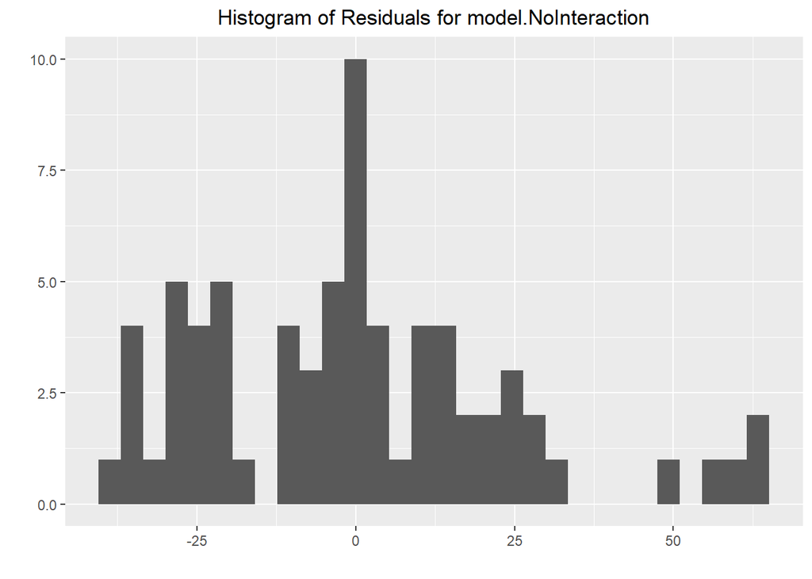

```r
# Plot location
setwd(figure_directory)

# Data to fit
data_modified_team <- team_data %>%
  select(TeamScore,
         params$dependent_response_team,
         params$dependent_response_DominateStrategy,
         Target,
         SessionOrder,
         Team)

# Generate models with variable response
GA_data_focus_team <- data_modified_team %>%
  filter(.data[[params$dependent_response_DominateStrategy]] == params$Strategy_GA_name_WithSpace)

model.NoInteraction <- model_data_Target_Session(df = GA_data_focus_team, dependent =  params$dependent_response_team, model.type =  "NoInteraction", is.team = TRUE, is.robust = FALSE)

# Histogram of Residuals - model.NoInteraction
ggplot(model.NoInteraction, aes(x = .resid)) +
  geom_histogram(bins = 30) +
  labs(title = paste("Histogram of Residuals for model.NoInteraction"), x = "", y = "") +
  theme(plot.title = element_text(hjust = 0.5)) +
  ggsave(filename = paste("Histogram_Residuals_", params$dependent_response_name_NoSpace, "_NoInteraction_", params$Strategy_GA_name_NoSpace, "_Team.png", sep = ""))
```

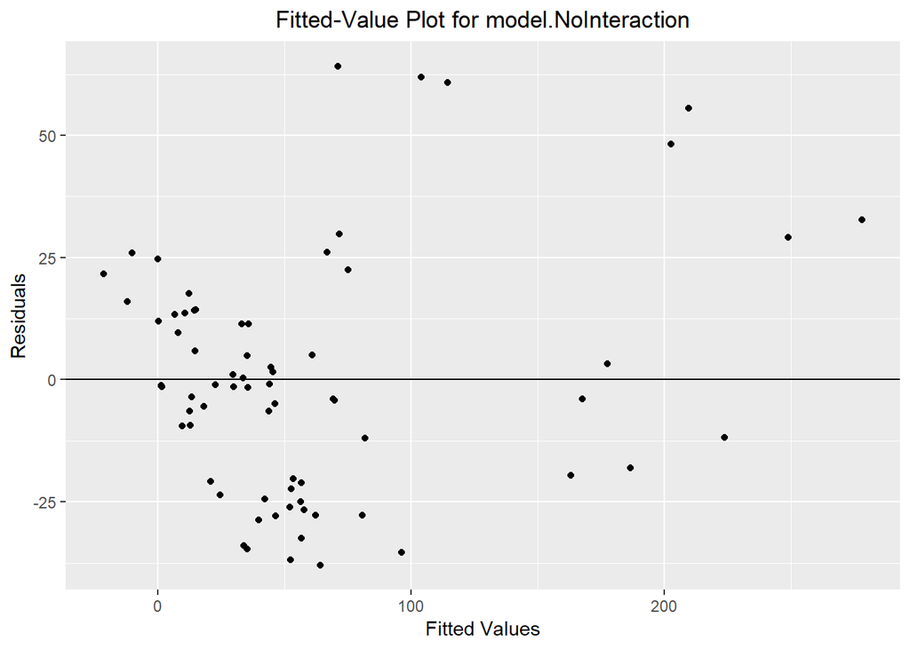

```r
# Fitted values - model.NoInteraction
ggplot(model.NoInteraction, aes(x = .fitted, y = .resid)) +
  geom_point() +
  geom_hline(yintercept = 0)+
  labs(title = paste("Fitted-Value Plot for model.NoInteraction"), x = "Fitted Values", y = "Residuals") +
  theme(plot.title = element_text(hjust = 0.5)) +
  ggsave(filename = paste("FitteValue_Residuals_", params$dependent_response_name_NoSpace, "_NoInteraction_", params$Strategy_GA_name_NoSpace, "_Team.png", sep = ""))
```

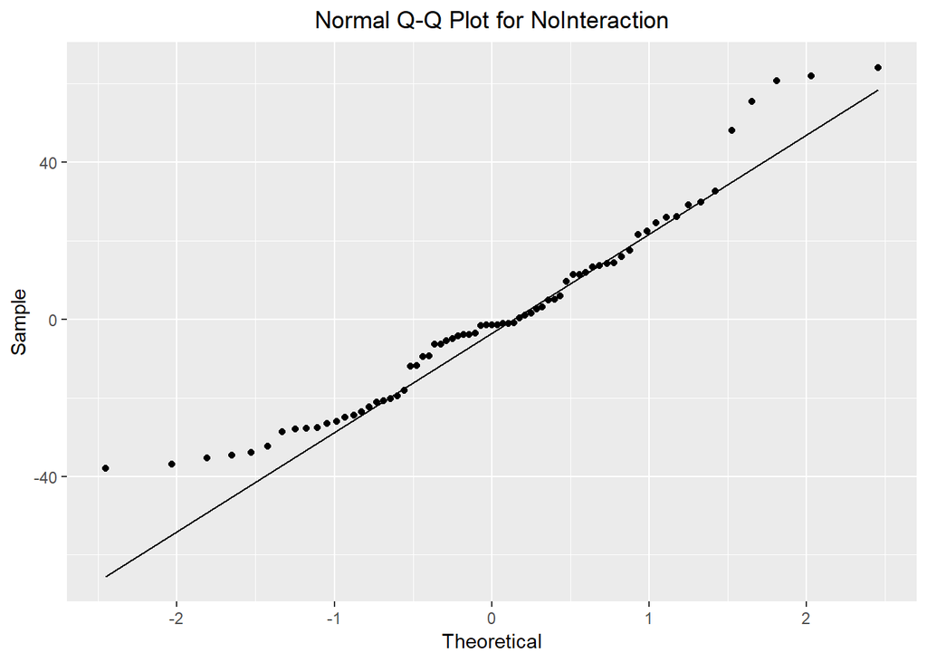

```r
# QQ plots - model.NoInteraction
ggplot(model.NoInteraction, aes(sample = .resid)) +
  stat_qq() +
  stat_qq_line()+
  labs(title = "Normal Q-Q Plot for NoInteraction", x = "Theoretical", y = "Sample") +
   theme(plot.title = element_text(hjust = 0.5)) +
  ggsave(filename = paste("QQ_Residuals_", params$dependent_response_name_NoSpace, "_NoInteraction_", params$Strategy_GA_name_NoSpace, "_Team.png", sep = ""))
```

It looks like assumption 2 and 3 are violated. Need to analysis the influence of the violation.

#### GT

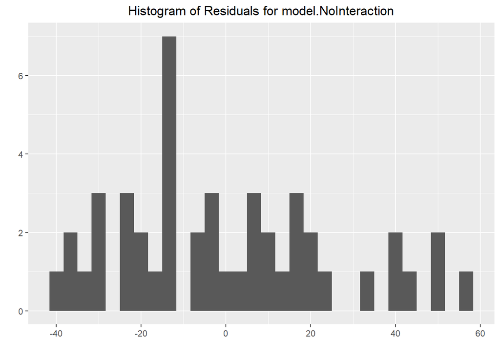

```r
# Plot location
setwd(figure_directory)

# Data to fit
data_modified_team <- team_data %>%
  select(TeamScore,
         params$dependent_response_team,
         params$dependent_response_DominateStrategy,
         Target,
         SessionOrder,
         Team)

# Generate models with variable response
GT_data_focus_team <- data_modified_team %>%
  filter(.data[[params$dependent_response_DominateStrategy]] == params$Strategy_GT_name_WithSpace)

model.NoInteraction <- model_data_Target_Session(df = GT_data_focus_team, dependent =  params$dependent_response_team, model.type =  "NoInteraction", is.team = TRUE, is.robust = FALSE)

# Histogram of Residuals - model.NoInteraction
ggplot(model.NoInteraction, aes(x = .resid)) +
  geom_histogram(bins = 30) +
  labs(title = paste("Histogram of Residuals for model.NoInteraction"), x = "", y = "") +
  theme(plot.title = element_text(hjust = 0.5)) +
  ggsave(filename = paste("Histogram_Residuals_", params$dependent_response_name_NoSpace, "_NoInteraction_", params$Strategy_GT_name_NoSpace, "_Team.png", sep = ""))
```

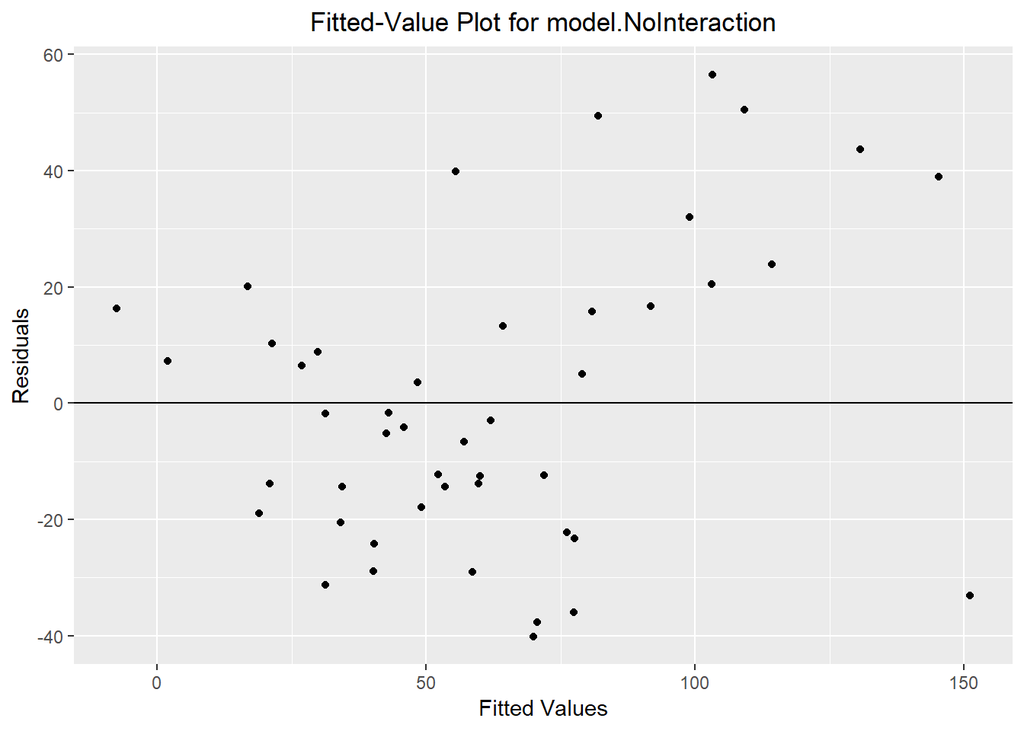

```r
# Fitted values - model.NoInteraction
ggplot(model.NoInteraction, aes(x = .fitted, y = .resid)) +
  geom_point() +
  geom_hline(yintercept = 0)+
  labs(title = paste("Fitted-Value Plot for model.NoInteraction"), x = "Fitted Values", y = "Residuals") +
  theme(plot.title = element_text(hjust = 0.5)) +
  ggsave(filename = paste("FitteValue_Residuals_", params$dependent_response_name_NoSpace, "_NoInteraction_", params$Strategy_GT_name_NoSpace, "_Team.png", sep = ""))
```

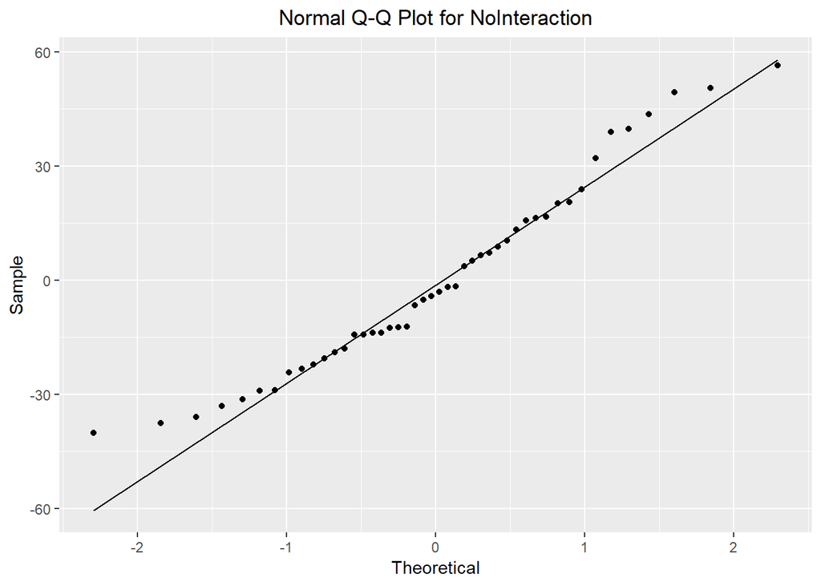

```r
# QQ plots - model.NoInteraction
ggplot(model.NoInteraction, aes(sample = .resid)) +
  stat_qq() +
  stat_qq_line()+
  labs(title = "Normal Q-Q Plot for NoInteraction", x = "Theoretical", y = "Sample") +
   theme(plot.title = element_text(hjust = 0.5)) +
  ggsave(filename = paste("QQ_Residuals_", params$dependent_response_name_NoSpace, "_NoInteraction_", params$Strategy_GT_name_NoSpace, "_Team.png", sep = ""))
```

It looks like assumption 2 and 3 are violated. Need to analysis the influence of the violation.

### Model.NoInteraction.NoTarget

#### GA

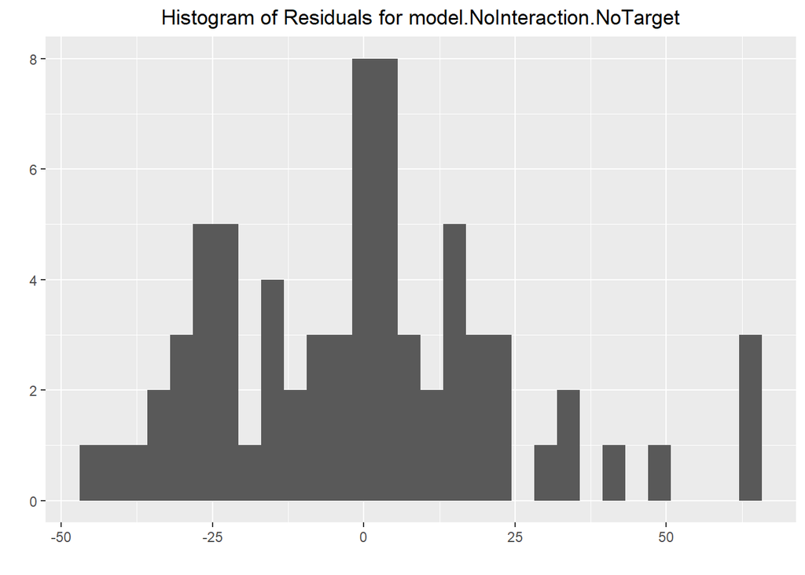

```r
# Plot location
setwd(figure_directory)

# Data to fit
data_modified_team <- team_data %>%
  select(TeamScore,
         params$dependent_response_team,
         params$dependent_response_DominateStrategy,
         Target,
         SessionOrder,
         Team)

# Generate models with variable response
GA_data_focus_team <- data_modified_team %>%
  filter(.data[[params$dependent_response_DominateStrategy]] == params$Strategy_GA_name_WithSpace)

model.NoInteraction.NoTarget <- model_data_Target_Session(df = GA_data_focus_team, dependent =  params$dependent_response_team, model.type =  "NoInteraction_NoTarget", is.team = TRUE, is.robust = FALSE)

# Histogram of Residuals - model.NoInteraction.NoTarget
ggplot(model.NoInteraction.NoTarget, aes(x = .resid)) +
  geom_histogram(bins = 30) +
  labs(title = paste("Histogram of Residuals for model.NoInteraction.NoTarget"), x = "", y = "") +
  theme(plot.title = element_text(hjust = 0.5)) +
  ggsave(filename = paste("Histogram_Residuals_", params$dependent_response_name_NoSpace, "_NoInteraction_", params$Strategy_GA_name_NoSpace, "_Team.png", sep = ""))
```

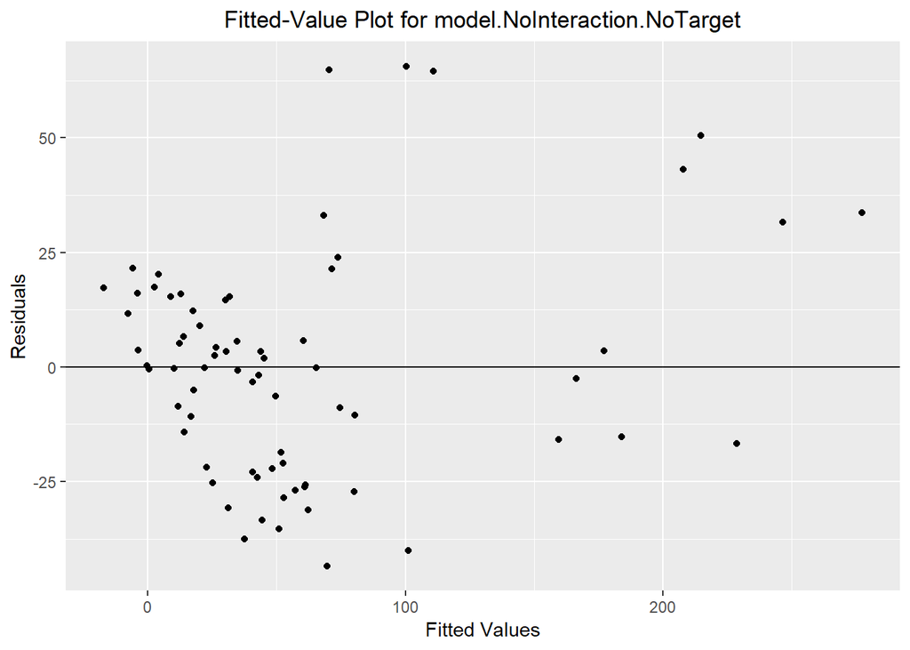

```r
# Fitted values - model.NoInteraction.NoTarget
ggplot(model.NoInteraction.NoTarget, aes(x = .fitted, y = .resid)) +
  geom_point() +
  geom_hline(yintercept = 0)+
  labs(title = paste("Fitted-Value Plot for model.NoInteraction.NoTarget"), x = "Fitted Values", y = "Residuals") +
  theme(plot.title = element_text(hjust = 0.5)) +
  ggsave(filename = paste("FitteValue_Residuals_", params$dependent_response_name_NoSpace, "_NoInteraction_", params$Strategy_GA_name_NoSpace, "_Team.png", sep = ""))
```

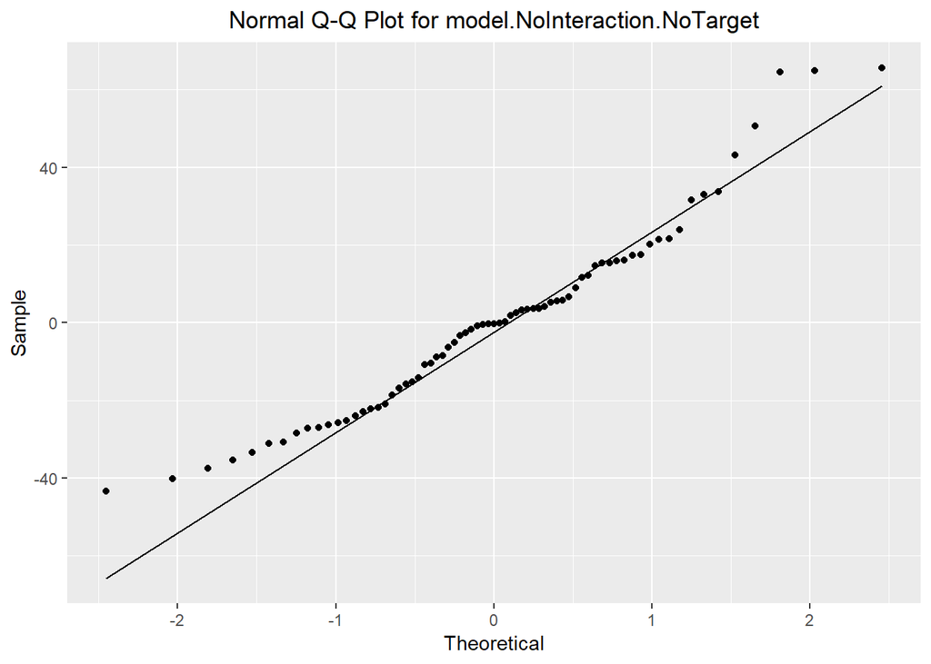

```r
# QQ plots - model.NoInteraction.NoTarget
ggplot(model.NoInteraction.NoTarget, aes(sample = .resid)) +
  stat_qq() +
  stat_qq_line()+
  labs(title = "Normal Q-Q Plot for model.NoInteraction.NoTarget", x = "Theoretical", y = "Sample") +
   theme(plot.title = element_text(hjust = 0.5)) +
  ggsave(filename = paste("QQ_Residuals_", params$dependent_response_name_NoSpace, "_NoInteraction_", params$Strategy_GA_name_NoSpace, "_Team.png", sep = ""))
```

It looks like assumption 2 and 3 are violated. Need to analysis the influence of the violation.

#### GT

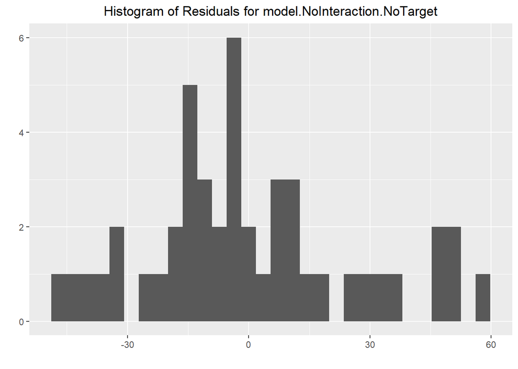

```r
# Plot location
setwd(figure_directory)

# Data to fit
data_modified_team <- team_data %>%
  select(TeamScore,
         params$dependent_response_team,
         params$dependent_response_DominateStrategy,
         Target,
         SessionOrder,
         Team)

# Generate models with variable response
GT_data_focus_team <- data_modified_team %>%
  filter(.data[[params$dependent_response_DominateStrategy]] == params$Strategy_GT_name_WithSpace)

model.NoInteraction.NoTarget <- model_data_Target_Session(df = GT_data_focus_team, dependent =  params$dependent_response_team, model.type =  "NoInteraction_NoTarget", is.team = TRUE, is.robust = FALSE)

# Histogram of Residuals - model.NoInteraction.NoTarget
ggplot(model.NoInteraction.NoTarget, aes(x = .resid)) +
  geom_histogram(bins = 30) +
  labs(title = paste("Histogram of Residuals for model.NoInteraction.NoTarget"), x = "", y = "") +
  theme(plot.title = element_text(hjust = 0.5)) +
  ggsave(filename = paste("Histogram_Residuals_", params$dependent_response_name_NoSpace, "_NoInteraction_", params$Strategy_GT_name_NoSpace, "_Team.png", sep = ""))
```

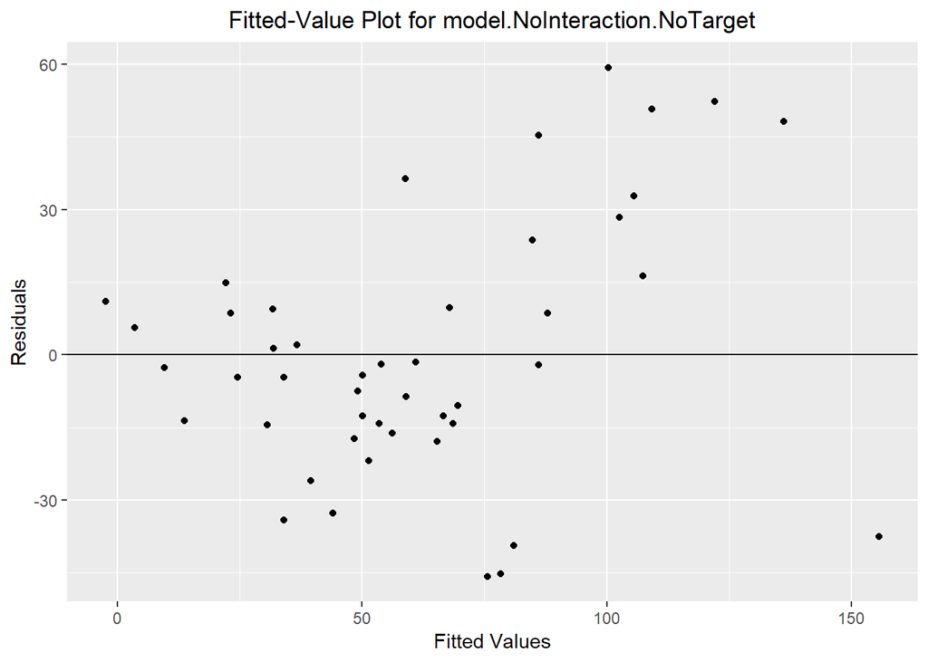

```r
# Fitted values - model.NoInteraction.NoTarget
ggplot(model.NoInteraction.NoTarget, aes(x = .fitted, y = .resid)) +
  geom_point() +
  geom_hline(yintercept = 0)+
  labs(title = paste("Fitted-Value Plot for model.NoInteraction.NoTarget"), x = "Fitted Values", y = "Residuals") +
  theme(plot.title = element_text(hjust = 0.5)) +
  ggsave(filename = paste("FitteValue_Residuals_", params$dependent_response_name_NoSpace, "_NoInteraction_", params$Strategy_GT_name_NoSpace, "_Team.png", sep = ""))
```

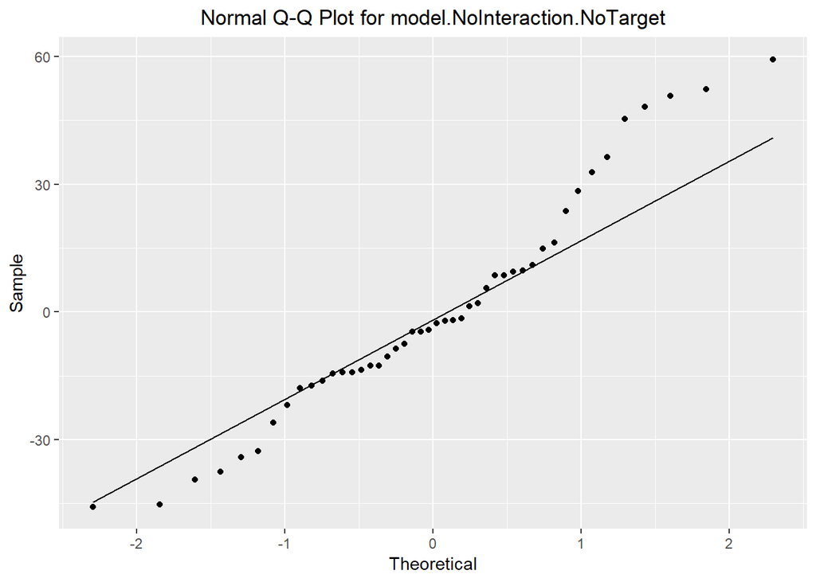

```r
# QQ plots - model.NoInteraction.NoTarget
ggplot(model.NoInteraction.NoTarget, aes(sample = .resid)) +
  stat_qq() +
  stat_qq_line()+
  labs(title = "Normal Q-Q Plot for model.NoInteraction.NoTarget", x = "Theoretical", y = "Sample") +
   theme(plot.title = element_text(hjust = 0.5)) +
  ggsave(filename = paste("QQ_Residuals_", params$dependent_response_name_NoSpace, "_NoInteraction_", params$Strategy_GT_name_NoSpace, "_Team.png", sep = ""))
```

It looks like assumption 2 and 3 are violated. Need to analysis the influence of the violation.

## Individual

### GA

#### Model.NoInteraction

```r
# Plot location
setwd(figure_directory)

# Data to model
data_modified_ind <- ind_data %>%
  select(params$dependent_response_ind,
         params$dependent_response_DominateStrategy,
         Target,
         SessionOrder,
         Team,
         Player_ID)

# Generate models with variable response
GA_data_focus_ind <- data_modified_ind %>%
  filter(.data[[params$dependent_response_DominateStrategy]] == params$Strategy_GA_name_WithSpace)

model.NoInteraction <- model_data_Target_Session(df = GA_data_focus_ind, dependent =  params$dependent_response_ind, model.type =  "NoInteraction", is.team = FALSE, is.robust = FALSE)
```

```
## boundary (singular) fit: see ?isSingular
```

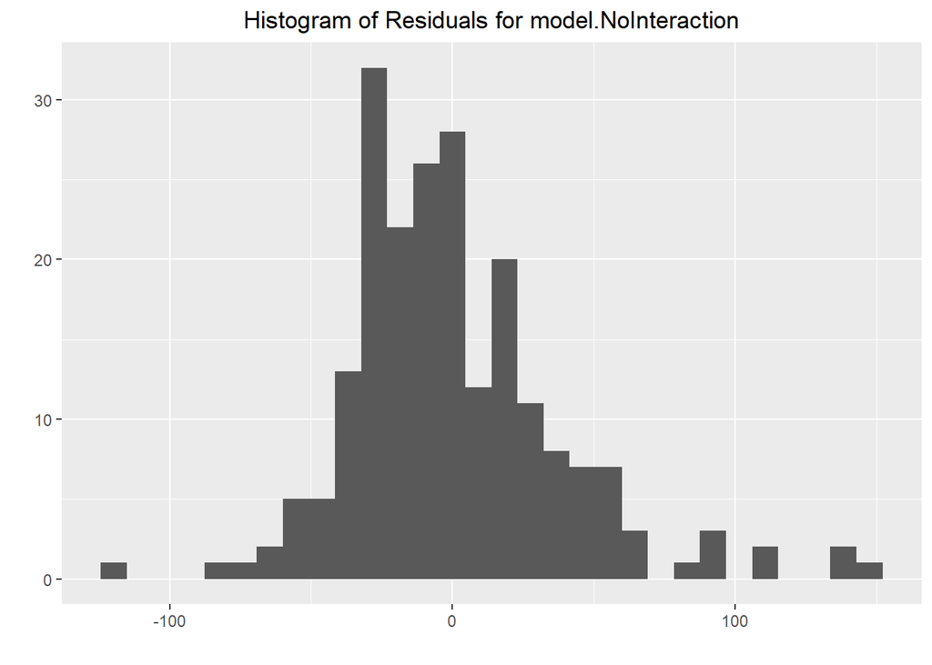

```r
# Histogram of Residuals - model.NoInteraction
ggplot(model.NoInteraction, aes(x = .resid)) +
  geom_histogram(bins = 30) +
  labs(title = paste("Histogram of Residuals for model.NoInteraction"), x = "", y = "") +
  theme(plot.title = element_text(hjust = 0.5)) +
  ggsave(paste("Histogram_Residuals_", params$dependent_response_name_NoSpace, "_NoInteraction_", params$Strategy_GA_name_NoSpace, "_Ind.png", sep =""))
```

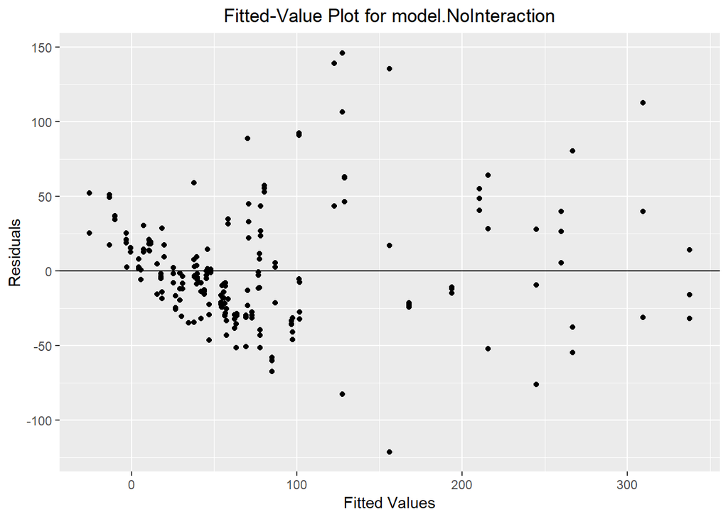

```r
# Fitted values - model.NoInteraction
ggplot(model.NoInteraction, aes(x = .fitted, y = .resid)) +
  geom_point() +
  geom_hline(yintercept = 0)+
  labs(title = paste("Fitted-Value Plot for model.NoInteraction"), x = "Fitted Values", y = "Residuals") +
  theme(plot.title = element_text(hjust = 0.5)) +
  ggsave(paste("FittedValue_Residuals_", params$dependent_response_name_NoSpace, "_NoInteraction_", params$Strategy_GA_name_NoSpace, "_Ind.png", sep =""))
```

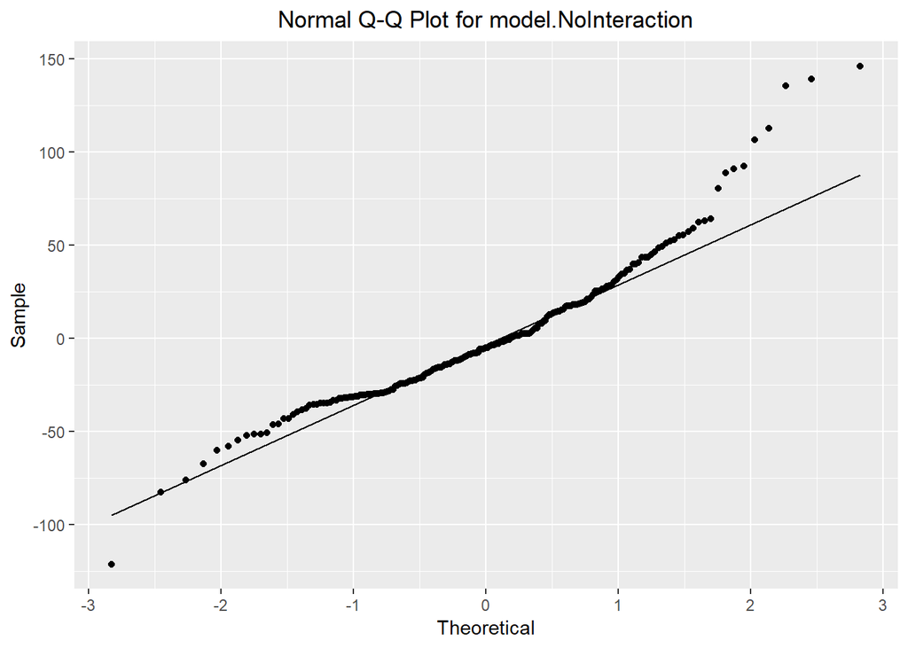

```r
# QQ plots - model.NoInteraction
ggplot(model.NoInteraction, aes(sample = .resid)) +
  stat_qq() +
  stat_qq_line()+
  labs(title = "Normal Q-Q Plot for model.NoInteraction", x = "Theoretical", y = "Sample") +
   theme(plot.title = element_text(hjust = 0.5)) +
  ggsave(paste("QQ_Residuals_", params$dependent_response_name_NoSpace, "_NoInteraction_", params$Strategy_GA_name_NoSpace, "_Ind.png", sep =""))
```

It looks like assumption 2 and 3 are violated. Need to analysis the influence of the violation.

#### Model.NoInteraction.NoTarget

```r
# Plot location
setwd(figure_directory)

# Data to model
data_modified_ind <- ind_data %>%
  select(params$dependent_response_ind,
         params$dependent_response_DominateStrategy,
         Target,
         SessionOrder,
         Team,
         Player_ID)

# Generate models with variable response
GA_data_focus_ind <- data_modified_ind %>%
  filter(.data[[params$dependent_response_DominateStrategy]] == params$Strategy_GA_name_WithSpace)

model.NoInteraction.NoTarget <- model_data_Target_Session(df = GA_data_focus_ind, dependent =  params$dependent_response_ind, model.type =  "NoInteraction_NoTarget", is.team = FALSE, is.robust = FALSE)
```

```
## boundary (singular) fit: see ?isSingular
```

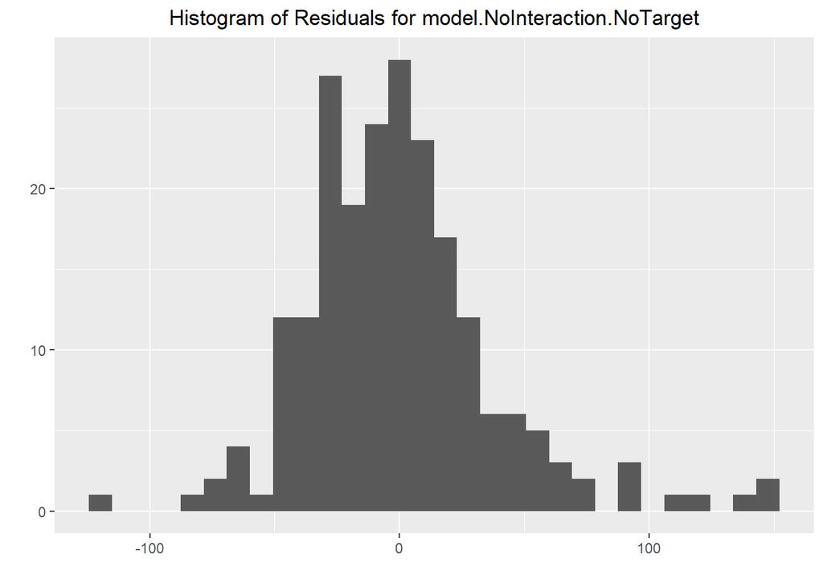

```r
# Histogram of Residuals - model.NoInteraction.NoTarget
ggplot(model.NoInteraction.NoTarget, aes(x = .resid)) +
  geom_histogram(bins = 30) +
  labs(title = paste("Histogram of Residuals for model.NoInteraction.NoTarget"), x = "", y = "") +
  theme(plot.title = element_text(hjust = 0.5)) +
  ggsave(paste("Histogram_Residuals_", params$dependent_response_name_NoSpace, "_NoInteractionNoTarget_", params$Strategy_GA_name_NoSpace, "_Ind.png", sep =""))
```

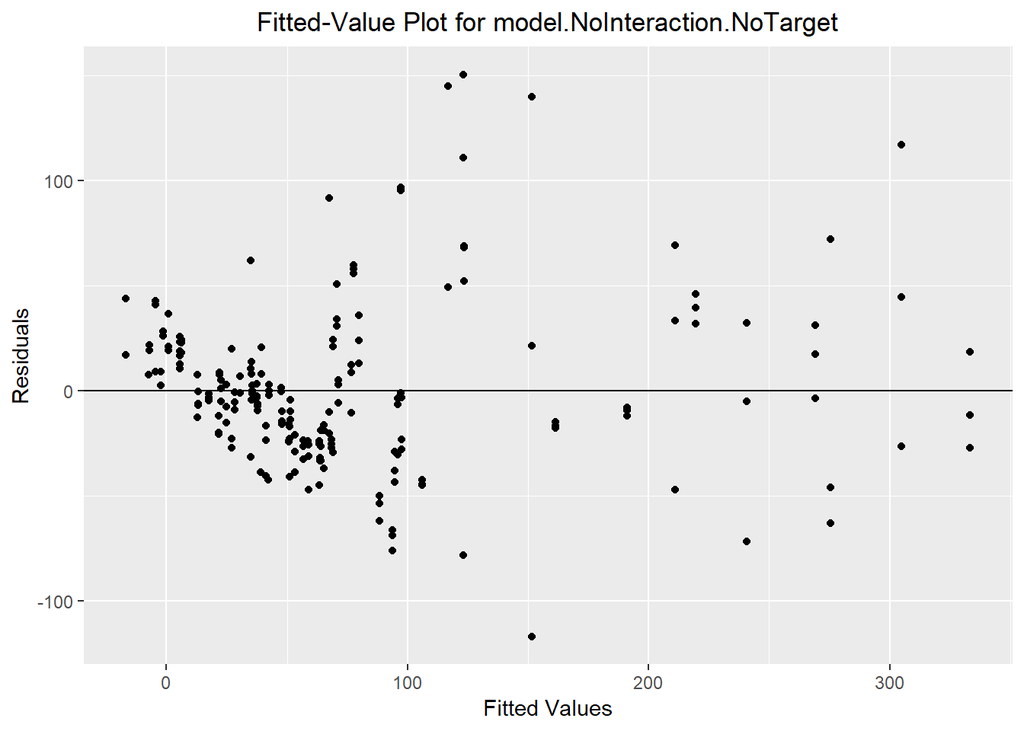

```r
# Fitted values - model.NoInteraction.NoTarget
ggplot(model.NoInteraction.NoTarget, aes(x = .fitted, y = .resid)) +
  geom_point() +
  geom_hline(yintercept = 0)+
  labs(title = paste("Fitted-Value Plot for model.NoInteraction.NoTarget"), x = "Fitted Values", y = "Residuals") +
  theme(plot.title = element_text(hjust = 0.5)) +
  ggsave(paste("FittedValue_Residuals_", params$dependent_response_name_NoSpace, "_NoInteractionNoTarget_", params$Strategy_GA_name_NoSpace, "_Ind.png", sep =""))
```

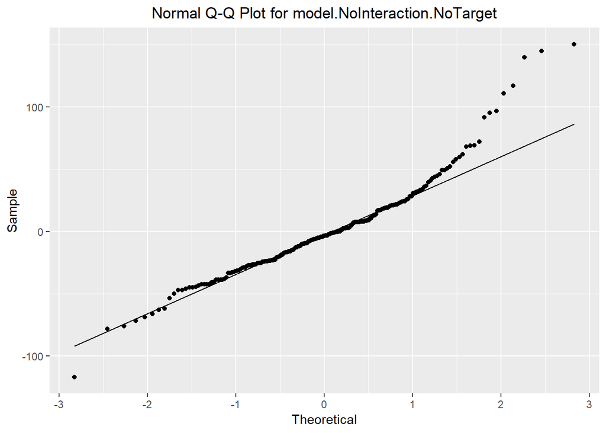

```r
# QQ plots - model.NoInteraction.NoTarget
ggplot(model.NoInteraction.NoTarget, aes(sample = .resid)) +
  stat_qq() +
  stat_qq_line()+
  labs(title = "Normal Q-Q Plot for model.NoInteraction.NoTarget", x = "Theoretical", y = "Sample") +
   theme(plot.title = element_text(hjust = 0.5)) +
  ggsave(paste("QQ_Residuals_", params$dependent_response_name_NoSpace, "_NoInteractionNoTarget_", params$Strategy_GA_name_NoSpace, "_Ind.png", sep =""))
```

It looks like assumption 2 and 3 are violated. Need to analysis the influence of the violation.

### GT

#### model.All

```r
# Plot location
setwd(figure_directory)

# Data to model
data_modified_ind <- ind_data %>%
  select(params$dependent_response_ind,
         params$dependent_response_DominateStrategy,
         Target,
         SessionOrder,
         Team,
         Player_ID)

# Generate models with variable response
GT_data_focus_ind <- data_modified_ind %>%
  filter(.data[[params$dependent_response_DominateStrategy]] == params$Strategy_GT_name_WithSpace)

model.All <- model_data_Target_Session(df = GT_data_focus_ind, dependent =  params$dependent_response_ind, model.type =  "All", is.team = FALSE, is.robust = FALSE)
```

```
## boundary (singular) fit: see ?isSingular
```

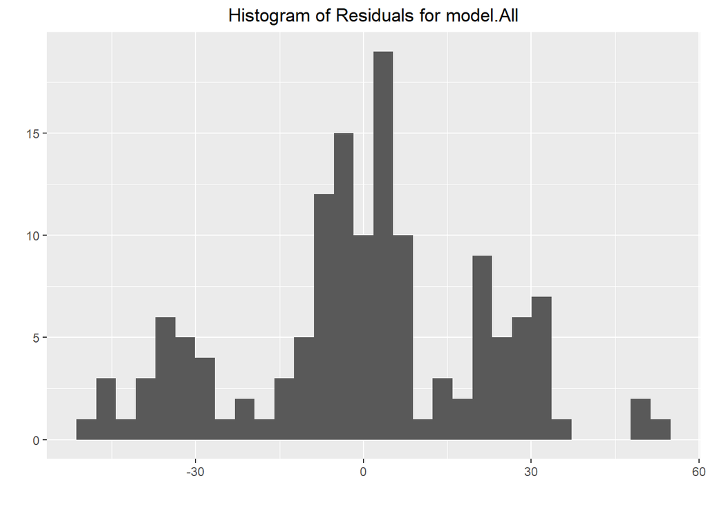

```r
# Histogram of Residuals -
ggplot(model.All, aes(x = .resid)) +
  geom_histogram(bins = 30) +
  labs(title = paste("Histogram of Residuals for model.All"), x = "", y = "") +
  theme(plot.title = element_text(hjust = 0.5)) +
  ggsave(paste("Histogram_Residuals_", params$dependent_response_name_NoSpace, "_All_", params$Strategy_GT_name_NoSpace , "Ind.png", sep =""))
```

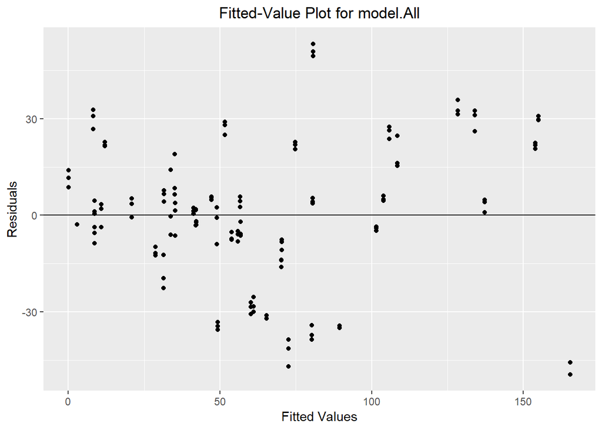

```r
# Fitted values - model.All
ggplot(model.All, aes(x = .fitted, y = .resid)) +
  geom_point() +
  geom_hline(yintercept = 0)+
  labs(title = paste("Fitted-Value Plot for model.All"), x = "Fitted Values", y = "Residuals") +
  theme(plot.title = element_text(hjust = 0.5)) +
  ggsave(paste("FittedValue_Residuals_", params$dependent_response_name_NoSpace, "_All_", params$Strategy_GT_name_NoSpace , "Ind.png", sep =""))
```

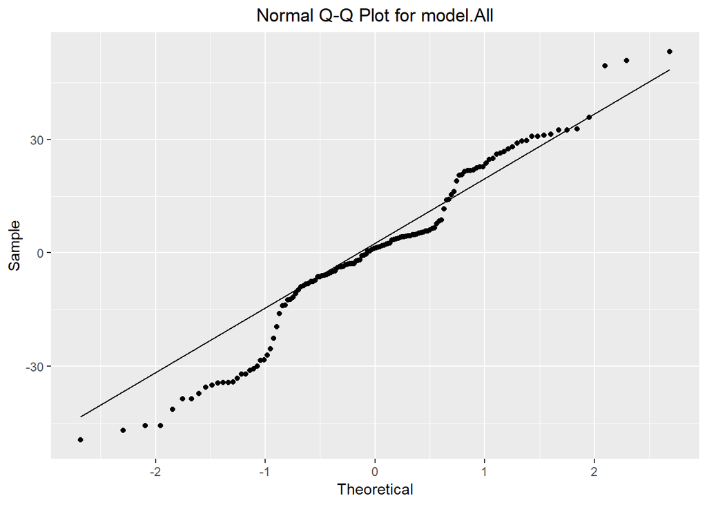

```r
# QQ plots - model.All
ggplot(model.All, aes(sample = .resid)) +
  stat_qq() +
  stat_qq_line()+
  labs(title = "Normal Q-Q Plot for model.All", x = "Theoretical", y = "Sample") +
   theme(plot.title = element_text(hjust = 0.5)) +
  ggsave(paste("QQ_Residuals_", params$dependent_response_name_NoSpace, "_All_", params$Strategy_GT_name_NoSpace , "Ind.png", sep =""))
```

It looks like assumption 2 and 3 are violated. Need to analysis the influence of the violation.

#### model.NoInteraction

```r
# Plot location
setwd(figure_directory)

# Data to model
data_modified_ind <- ind_data %>%
  select(params$dependent_response_ind,
         params$dependent_response_DominateStrategy,
         Target,
         SessionOrder,
         Team,
         Player_ID)

# Generate models with variable response
GT_data_focus_ind <- data_modified_ind %>%
  filter(.data[[params$dependent_response_DominateStrategy]] == params$Strategy_GT_name_WithSpace)

model.NoInteraction <- model_data_Target_Session(df = GT_data_focus_ind, dependent =  params$dependent_response_ind, model.type =  "NoInteraction", is.team = FALSE, is.robust = FALSE)
```

```
## boundary (singular) fit: see ?isSingular
```

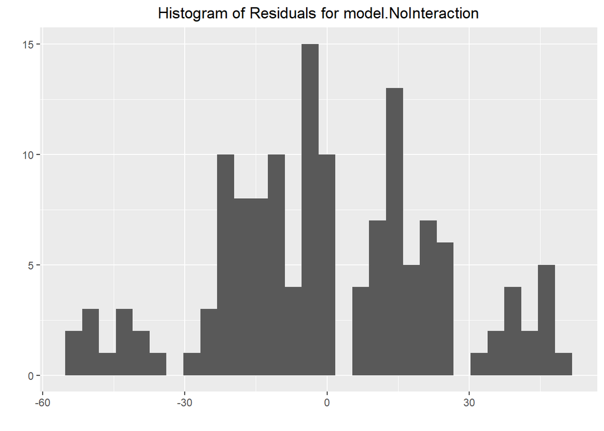

```r
# Histogram of Residuals - model.NoInteraction
ggplot(model.NoInteraction, aes(x = .resid)) +
  geom_histogram(bins = 30) +
  labs(title = paste("Histogram of Residuals for model.NoInteraction"), x = "", y = "") +
  theme(plot.title = element_text(hjust = 0.5)) +
  ggsave(paste("Histogram_Residuals_", params$dependent_response_name_NoSpace, "_NoInteraction_", params$Strategy_GT_name_NoSpace , "Ind.png", sep =""))
```

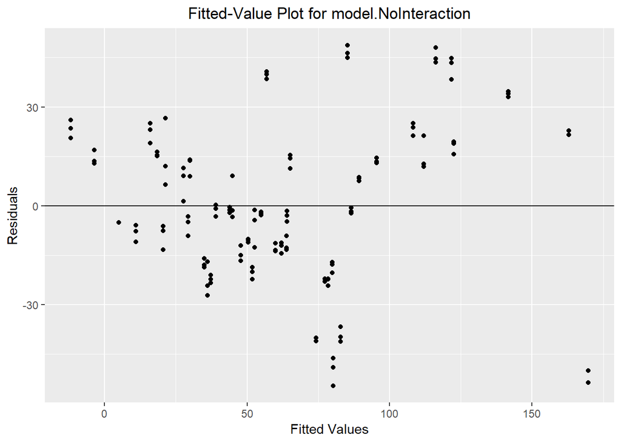

```r
# Fitted values - model.NoInteraction
ggplot(model.NoInteraction, aes(x = .fitted, y = .resid)) +
  geom_point() +
  geom_hline(yintercept = 0)+
  labs(title = paste("Fitted-Value Plot for model.NoInteraction"), x = "Fitted Values", y = "Residuals") +
  theme(plot.title = element_text(hjust = 0.5)) +
  ggsave(paste("FittedValue_Residuals_", params$dependent_response_name_NoSpace, "_NoInteraction_", params$Strategy_GT_name_NoSpace , "Ind.png", sep =""))
```

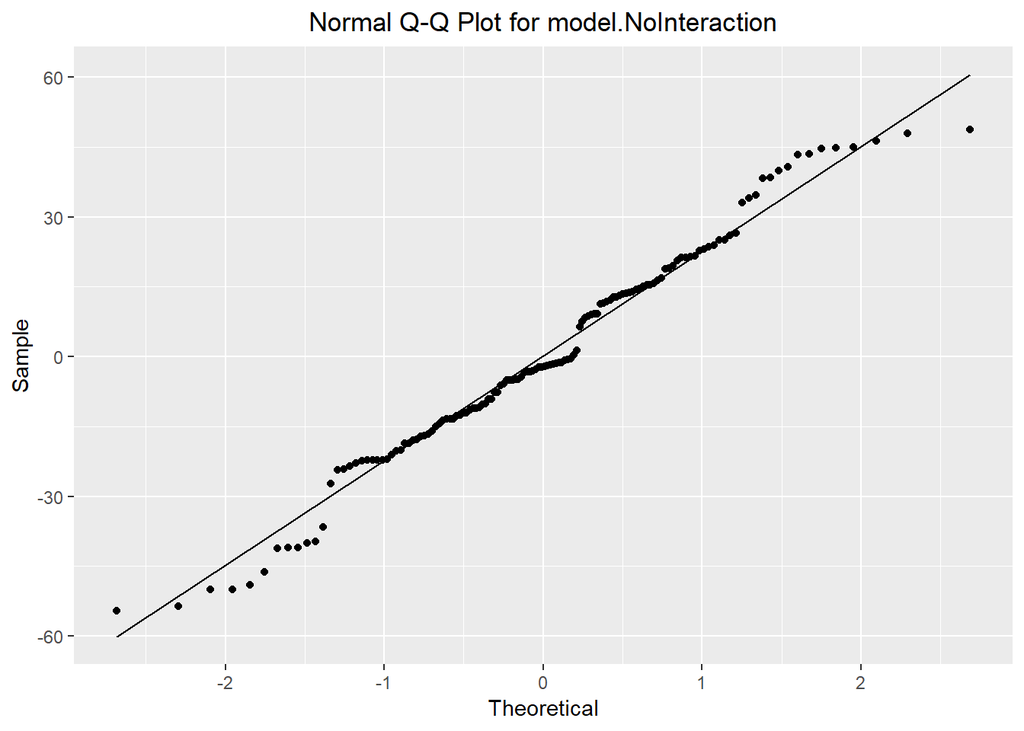

```r
# QQ plots - model.NoInteraction
ggplot(model.NoInteraction, aes(sample = .resid)) +
  stat_qq() +
  stat_qq_line()+
  labs(title = "Normal Q-Q Plot for model.NoInteraction", x = "Theoretical", y = "Sample") +
   theme(plot.title = element_text(hjust = 0.5)) +
  ggsave(paste("QQ_Residuals_", params$dependent_response_name_NoSpace, "_NoInteraction_", params$Strategy_GT_name_NoSpace , "Ind.png", sep =""))
```

It looks like all assumptions are violated. Need to analysis the influence of the violation.

## Summary

Overall, it looks like every model violates the assumptions and I need to compare them to the robust model to see if I need to transform the model.

# Q: Does the violation influence the linear model estimation?

## Team

### Model.NoInteraction

#### GA

```r
# Data to fit
data_modified_team <- team_data %>%
  select(TeamScore,
         params$dependent_response_team,
         params$dependent_response_DominateStrategy,
         Target,
         SessionOrder,
         Team)

# Generate models with variable response
GA_data_focus_team <- data_modified_team %>%
  filter(.data[[params$dependent_response_DominateStrategy]] == params$Strategy_GA_name_WithSpace)

# Generate robust and non-robust models - NoInteraction
model.NoInteraction <- model_data_Target_Session(df = GA_data_focus_team, dependent =  params$dependent_response_team, model.type =  "NoInteraction", is.team = TRUE, is.robust = FALSE)
rmodel.NoInteraction <- model_data_Target_Session(df = GA_data_focus_team, dependent =  params$dependent_response_team, model.type =  "NoInteraction", is.team = TRUE, is.robust = TRUE)

comparision_results <- compare(model.NoInteraction, rmodel.NoInteraction, show.rho.functions = FALSE)

comparision_results %>%
  kable(caption = "model.NoInteraction") %>%
  kable_styling()
```

model.NoInteraction

|  | model.NoInteraction | rmodel.NoInteraction |
| --- | --- | --- |
| Coef |  |  |
| (Intercept) | 39.29 (14.41) | 27.052 (8.31) |
| TargetInd_Team | -6.13 ( 9.40) | -8.010 (7.57) |
| TargetTeam | 2.35 ( 9.43) | -0.336 (7.55) |
| SessionOrder3 | 16.83 ( 9.36) | 13.315 (7.49) |
| SessionOrder4 | 48.25 ( 9.44) | 38.712 (7.56) |
| VarComp |  |  |
| (Intercept) \| Team | 61.0 | 24.6 |
| sigma | 31.2 | 24.8 |
| REML | 717 |  |

There is a concerable difference betwee the classic model and the robust model. I will transform the data.

#### GT

```r
# Data to fit
data_modified_team <- team_data %>%
  select(TeamScore,
         params$dependent_response_team,
         params$dependent_response_DominateStrategy,
         Target,
         SessionOrder,
         Team)

# Generate models with variable response
GT_data_focus_team <- data_modified_team %>%
  filter(.data[[params$dependent_response_DominateStrategy]] == params$Strategy_GT_name_WithSpace)

# Generate robust and non-robust models - NoInteraction
model.NoInteraction <- model_data_Target_Session(df = GT_data_focus_team, dependent =  params$dependent_response_team, model.type =  "NoInteraction", is.team = TRUE, is.robust = FALSE)
rmodel.NoInteraction <- model_data_Target_Session(df = GT_data_focus_team, dependent =  params$dependent_response_team, model.type =  "NoInteraction", is.team = TRUE, is.robust = TRUE)

comparision_results <- compare(model.NoInteraction, rmodel.NoInteraction, show.rho.functions = FALSE)

comparision_results %>%
  kable(caption = "model.NoInteraction") %>%
  kable_styling()
```

model.NoInteraction

|  | model.NoInteraction | rmodel.NoInteraction |
| --- | --- | --- |
| Coef |  |  |
| (Intercept) | 25.81 (13.7) | 23.56 (14.4) |
| TargetInd_Team | 3.56 (12.0) | 3.83 (13.2) |
| TargetTeam | 16.54 (12.4) | 16.40 (13.6) |
| SessionOrder3 | 25.48 (12.6) | 25.97 (13.9) |
| SessionOrder4 | 44.25 (12.5) | 43.32 (13.7) |
| VarComp |  |  |
| (Intercept) \| Team | 35.6 | 33.5 |
| sigma | 32 | 34.4 |
| REML | 437 |  |

I do not see a concerning difference. I will not transform the data.

### Model.NoInteraction.NoTarget

#### GA

```r
# Data to fit
data_modified_team <- team_data %>%
  select(TeamScore,
         params$dependent_response_team,
         params$dependent_response_DominateStrategy,
         Target,
         SessionOrder,
         Team)

# Generate models with variable response
GA_data_focus_team <- data_modified_team %>%
  filter(.data[[params$dependent_response_DominateStrategy]] == params$Strategy_GA_name_WithSpace)

# Generate robust and non-robust models - NoInteraction
model.NoInteraction.NoTarget <- model_data_Target_Session(df = GA_data_focus_team, dependent =  params$dependent_response_team, model.type =  "NoInteraction_NoTarget", is.team = TRUE, is.robust = FALSE)
rmodel.NoInteraction.NoTarget <- model_data_Target_Session(df = GA_data_focus_team, dependent =  params$dependent_response_team, model.type =  "NoInteraction_NoTarget", is.team = TRUE, is.robust = TRUE)

comparision_results <- compare(model.NoInteraction.NoTarget, rmodel.NoInteraction.NoTarget, show.rho.functions = FALSE)

comparision_results %>%
  kable(caption = "model.NoInteraction.NoTarget") %>%
  kable_styling()
```

model.NoInteraction.NoTarget

|  | model.NoInteraction.NoTarget | rmodel.NoInteraction.NoTarget |
| --- | --- | --- |
| Coef |  |  |
| (Intercept) | 37.9 (13.25) | 24.0 (7.00) |
| SessionOrder3 | 17.8 ( 9.16) | 14.4 (7.40) |
| SessionOrder4 | 48.5 ( 9.31) | 38.8 (7.51) |
| VarComp |  |  |
| (Intercept) \| Team | 61.1 | 24.9 |
| sigma | 30.8 | 24.6 |
| REML | 730 |  |

I see a concerable difference. I will transform the data.

#### GT

```r
# Data to fit
data_modified_team <- team_data %>%
  select(TeamScore,
         params$dependent_response_team,
         params$dependent_response_DominateStrategy,
         Target,
         SessionOrder,
         Team)

# Generate models with variable response
GT_data_focus_team <- data_modified_team %>%
  filter(.data[[params$dependent_response_DominateStrategy]] == params$Strategy_GT_name_WithSpace)

# Generate robust and non-robust models - NoInteraction
model.NoInteraction.NoTarget <- model_data_Target_Session(df = GT_data_focus_team, dependent =  params$dependent_response_team, model.type =  "NoInteraction_NoTarget", is.team = TRUE, is.robust = FALSE)
rmodel.NoInteraction.NoTarget <- model_data_Target_Session(df = GT_data_focus_team, dependent =  params$dependent_response_team, model.type =  "NoInteraction_NoTarget", is.team = TRUE, is.robust = TRUE)

comparision_results <- compare(model.NoInteraction.NoTarget, rmodel.NoInteraction.NoTarget, show.rho.functions = FALSE)

comparision_results %>%
  kable(caption = "model.NoInteraction.NoTarget") %>%
  kable_styling()
```

model.NoInteraction.NoTarget

|  | model.NoInteraction.NoTarget | rmodel.NoInteraction.NoTarget |
| --- | --- | --- |
| Coef |  |  |
| (Intercept) | 31.1 (12.6) | 29.2 (12.5) |
| SessionOrder3 | 27.0 (12.3) | 26.8 (12.8) |
| SessionOrder4 | 46.4 (12.3) | 43.0 (12.7) |
| VarComp |  |  |
| (Intercept) \| Team | 35.9 | 33.1 |
| sigma | 31.9 | 32.3 |
| REML | 452 |  |

I see no concerable difference. I will not transform the data.

## Individual

### GA

#### Model.NoInteraction

```r
#response_variable <- "II_ind"

# Data to model
data_modified_ind <- ind_data %>%
  select(params$dependent_response_ind,
         params$dependent_response_DominateStrategy,
         Target,
         SessionOrder,
         Team,
         Player_ID)

# Generate models with variable response
GA_data_focus_ind <- data_modified_ind %>%
  filter(.data[[params$dependent_response_DominateStrategy]] == params$Strategy_GA_name_WithSpace)

model.NoInteraction <- model_data_Target_Session(df = GA_data_focus_ind, dependent =  params$dependent_response_ind, model.type =  "NoInteraction", is.team = FALSE, is.robust = FALSE)
```

```
## boundary (singular) fit: see ?isSingular
```

```r
rmodel.NoInteraction <- model_data_Target_Session(df = GA_data_focus_ind, dependent =  params$dependent_response_ind, model.type =  "NoInteraction", is.team = FALSE, is.robust = TRUE)
```

```
## boundary (singular) fit: see ?isSingular
```

```r
comparision_results <- compare(model.NoInteraction, rmodel.NoInteraction, show.rho.functions = FALSE)

comparision_results %>%
  kable(caption = "model.NoInteraction") %>%
  kable_styling()
```

model.NoInteraction

|  | model.NoInteraction | rmodel.NoInteraction |
| --- | --- | --- |
| Coef |  |  |
| (Intercept) | 50.0 (15.01) | 32.79 (7.64) |
| TargetInd_Team | -13.4 ( 7.08) | -8.69 (5.20) |
| TargetTeam | 1.5 ( 7.13) | -1.72 (5.21) |
| SessionOrder3 | 27.5 ( 7.07) | 20.26 (5.17) |
| SessionOrder4 | 57.5 ( 7.13) | 47.03 (5.22) |
| VarComp |  |  |
| (Intercept) \| Player_ID | 0.0 | 0.0 |
| (Intercept) \| Team | 70.8 | 30.8 |
| sigma | 40.6 | 29.2 |
| REML | 2234 |  |

I do see a concernable difference. I will transform the data.

#### Model.NoInteraction.NoTarget

```r
#response_variable <- "II_ind"

# Data to model
data_modified_ind <- ind_data %>%
  select(params$dependent_response_ind,
         params$dependent_response_DominateStrategy,
         Target,
         SessionOrder,
         Team,
         Player_ID)

# Generate models with variable response
GA_data_focus_ind <- data_modified_ind %>%
  filter(.data[[params$dependent_response_DominateStrategy]] == params$Strategy_GA_name_WithSpace)

model.NoInteraction.NoTarget <- model_data_Target_Session(df = GA_data_focus_ind, dependent =  params$dependent_response_ind, model.type =  "NoInteraction_NoTarget", is.team = FALSE, is.robust = FALSE)
```

```
## boundary (singular) fit: see ?isSingular
```

```r
rmodel.NoInteraction.NoTarget <- model_data_Target_Session(df = GA_data_focus_ind, dependent =  params$dependent_response_ind, model.type =  "NoInteraction_NoTarget", is.team = FALSE, is.robust = TRUE)
```

```
## boundary (singular) fit: see ?isSingular
```

```r
comparision_results <- compare(model.NoInteraction.NoTarget, rmodel.NoInteraction.NoTarget, show.rho.functions = FALSE)

comparision_results %>%
  kable(caption = "model.NoInteraction.NoTarget") %>%
  kable_styling()
```

model.NoInteraction.NoTarget

|  | model.NoInteraction.NoTarget | rmodel.NoInteraction.NoTarget |
| --- | --- | --- |
| Coef |  |  |
| (Intercept) | 45.7 (14.42) | 29.2 (6.85) |
| SessionOrder3 | 29.6 ( 7.07) | 20.7 (5.00) |
| SessionOrder4 | 58.1 ( 7.19) | 45.9 (5.08) |
| VarComp |  |  |
| (Intercept) \| Player_ID | 0.00243 | 0.00000 |
| (Intercept) \| Team | 70.85925 | 30.34622 |
| sigma | 41 | 28.4 |
| REML | 2250 |  |

I see a concerable difference, I will transform the data.

### GT

#### model.All

```r
#response_variable <- "II_ind"

# Data to model
data_modified_ind <- ind_data %>%
  select(params$dependent_response_ind,
         params$dependent_response_DominateStrategy,
         Target,
         SessionOrder,
         Team,
         Player_ID)

# Generate models with variable response
GT_data_focus_ind <- data_modified_ind %>%
  filter(.data[[params$dependent_response_DominateStrategy]] == params$Strategy_GT_name_WithSpace)

model.All <- model_data_Target_Session(df = GT_data_focus_ind, dependent =  params$dependent_response_ind, model.type =  "All", is.team = FALSE, is.robust = FALSE)
```

```
## boundary (singular) fit: see ?isSingular
```

```r
rmodel.All <- model_data_Target_Session(df = GT_data_focus_ind, dependent =  params$dependent_response_ind, model.type =  "All", is.team = FALSE, is.robust = TRUE)
```

```
## boundary (singular) fit: see ?isSingular
```

```r
comparision_results <- compare(model.All, rmodel.All, show.rho.functions = FALSE)

comparision_results %>%
  kable(caption = "rmodel.All") %>%
  kable_styling()
```

rmodel.All

|  | model.All | rmodel.All |
| --- | --- | --- |
| Coef |  |  |
| (Intercept) | 32.22 (11.4) | 31.70 (10.7) |
| TargetInd_Team | 0.74 (12.4) | -1.39 (11.5) |
| TargetTeam | -6.64 (12.3) | -11.03 (11.4) |
| SessionOrder3 | 24.48 (11.8) | 20.38 (10.9) |
| SessionOrder4 | 23.66 (11.4) | 23.17 (10.6) |
| TargetInd_Team:SessionOrder3 | 7.91 (18.5) | 10.26 (17.1) |
| TargetTeam:SessionOrder3 | 3.03 (19.3) | 9.85 (17.9) |
| TargetInd_Team:SessionOrder4 | 7.00 (18.9) | 4.90 (17.5) |
| TargetTeam:SessionOrder4 | 64.20 (18.2) | 63.75 (16.9) |
| VarComp |  |  |
| (Intercept) \| Player_ID | 0.0 | 0.0 |
| (Intercept) \| Team | 38.8 | 35.9 |
| sigma | 23.9 | 21.6 |
| REML | 1257 |  |

I see a concerable difference. I will transform the data.

#### Model.NoInteraction

```r
#response_variable <- "II_ind"

# Data to model
data_modified_ind <- ind_data %>%
  select(params$dependent_response_ind,
         params$dependent_response_DominateStrategy,
         Target,
         SessionOrder,
         Team,
         Player_ID)

# Generate models with variable response
GT_data_focus_ind <- data_modified_ind %>%
  filter(.data[[params$dependent_response_DominateStrategy]] == params$Strategy_GT_name_WithSpace)

model.NoInteraction <- model_data_Target_Session(df = GT_data_focus_ind, dependent =  params$dependent_response_ind, model.type =  "NoInteraction", is.team = FALSE, is.robust = FALSE)
```

```
## boundary (singular) fit: see ?isSingular
```

```r
rmodel.NoInteraction <- model_data_Target_Session(df = GT_data_focus_ind, dependent =  params$dependent_response_ind, model.type =  "NoInteraction", is.team = FALSE, is.robust = TRUE)
```

```
## boundary (singular) fit: see ?isSingular
```

```r
comparision_results <- compare(model.NoInteraction, rmodel.NoInteraction, show.rho.functions = FALSE)

comparision_results %>%
  kable(caption = "model.NoInteraction") %>%
  kable_styling()
```

model.NoInteraction

|  | model.NoInteraction | rmodel.NoInteraction |
| --- | --- | --- |
| Coef |  |  |
| (Intercept) | 26.14 (10.72) | 27.62 (10.33) |
| TargetInd_Team | 2.66 ( 5.59) | -1.17 ( 4.85) |
| TargetTeam | 15.97 ( 5.86) | 10.00 ( 5.09) |
| SessionOrder3 | 25.32 ( 5.93) | 22.47 ( 5.15) |
| SessionOrder4 | 45.36 ( 5.92) | 43.15 ( 5.14) |
| VarComp |  |  |
| (Intercept) \| Player_ID | 0.0 | 0.0 |
| (Intercept) \| Team | 40.1 | 38.7 |
| sigma | 25.5 | 21.6 |
| REML | 1307 |  |

I see a concerable difference. I will transform the data.

## Summary

I will need to transform some of the data.

At the team level, I will need to transform the data for **model.NoInteraction** and **model.NoInteraction.NoTarget** when teams use the Go Alone strategy.

At the individual level, I will need to transform the data for **model.NoInteraction** and **model.NoInteractionNoTarget** when teams use the Go Alone strategy. I will also need to transform the data for **model.All** and **model.NoInteraction** when teams use the Go Together strategy.

# Q: Does data transformation satisfy the assumptions of the residuals?

## Team

### Model.NoInteraction

#### GA

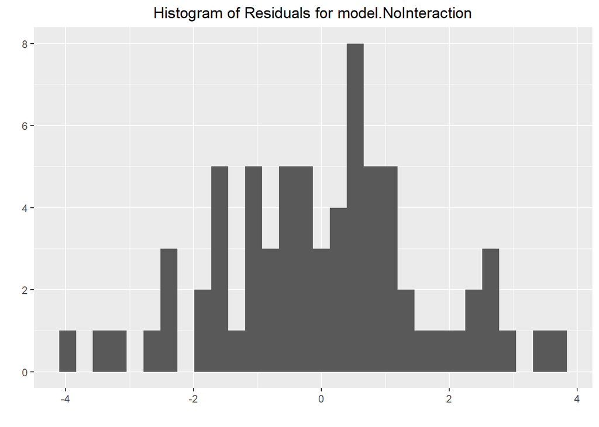

```r
#Plot location
setwd(figure_directory)

# Data to fit
data_modified_team <- team_data %>%
  select(TeamScore,
         params$dependent_response_team,
         params$dependent_response_DominateStrategy,
         Target,
         SessionOrder,
         Team) %>%
  mutate(sqrt.value = sqrt(.data[[params$dependent_response_team]]))

# Generate models with variable response
GA_data_focus_team <- data_modified_team %>%
  filter(.data[[params$dependent_response_DominateStrategy]] == params$Strategy_GA_name_WithSpace)

# Generate non-robust models - NoInteraction
model.NoInteraction <- model_data_Target_Session(df = GA_data_focus_team, dependent =  "sqrt.value", model.type =  "NoInteraction", is.team = TRUE, is.robust = FALSE)

# Histogram of Residuals - model.NoInteraction
ggplot(model.NoInteraction, aes(x = .resid)) +
  geom_histogram(bins = 30) +
  labs(title = paste("Histogram of Residuals for model.NoInteraction"), x = "", y = "") +
  theme(plot.title = element_text(hjust = 0.5)) +
  ggsave(paste("Histogram_Residuals_", params$dependent_response_name_NoSpace, "_sqrt_NoInteraction_", params$Strategy_GA_name_NoSpace, "_Team.png", sep = ""))
```

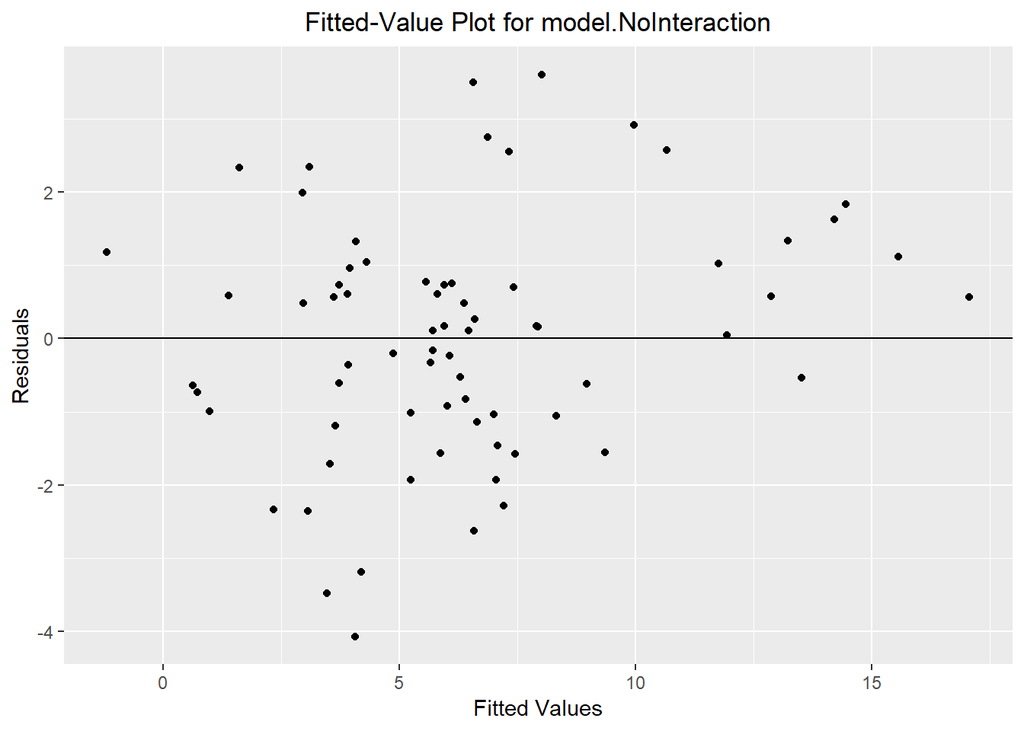

```r
# Fitted values - model.NoInteraction
ggplot(model.NoInteraction, aes(x = .fitted, y = .resid)) +
  geom_point() +
  geom_hline(yintercept = 0)+
  labs(title = paste("Fitted-Value Plot for model.NoInteraction"), x = "Fitted Values", y = "Residuals") +
  theme(plot.title = element_text(hjust = 0.5)) +
  ggsave(paste("FitteValue_Residuals_", params$dependent_response_name_NoSpace, "_sqrt_NoInteraction_", params$Strategy_GA_name_NoSpace, "_Team.png", sep = ""))
```

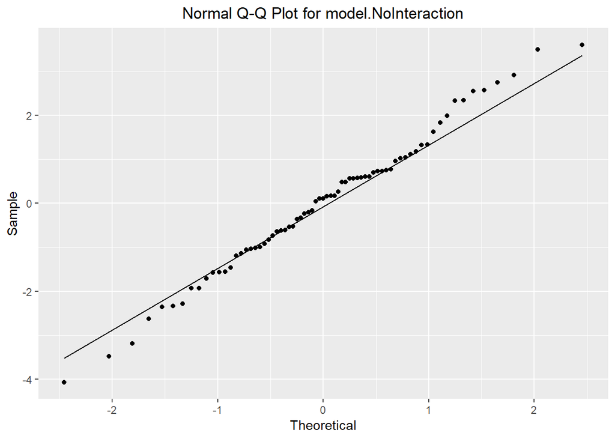

```r
# QQ plots - model.NoInteraction
ggplot(model.NoInteraction, aes(sample = .resid)) +
  stat_qq() +
  stat_qq_line()+
  labs(title = "Normal Q-Q Plot for model.NoInteraction", x = "Theoretical", y = "Sample") +
   theme(plot.title = element_text(hjust = 0.5)) +
  ggsave(paste("QQ_Residuals_", params$dependent_response_name_NoSpace, "_sqrt_NoInteraction_", params$Strategy_GA_name_NoSpace, "_Team.png", sep = ""))
```

There still seems to be a violation with assumption 3.

```r
# Data to fit
data_modified_team <- team_data %>%
  select(TeamScore,
         params$dependent_response_team,
         params$dependent_response_DominateStrategy,
         Target,
         SessionOrder,
         Team) %>%
  mutate(sqrt.value = sqrt(.data[[params$dependent_response_team]]))

# Generate models with variable response
GA_data_focus_team <- data_modified_team %>%
  filter(.data[[params$dependent_response_DominateStrategy]] == params$Strategy_GA_name_WithSpace)

# Generate robust and non-robust models - NoInteraction
model.NoInteraction <- model_data_Target_Session(df = GA_data_focus_team, dependent =  "sqrt.value", model.type =  "NoInteraction", is.team = TRUE, is.robust = FALSE)
rmodel.NoInteraction <- model_data_Target_Session(df = GA_data_focus_team, dependent =  "sqrt.value", model.type =  "NoInteraction", is.team = TRUE, is.robust = TRUE)

comparision_results <- compare(model.NoInteraction, rmodel.NoInteraction, show.rho.functions = FALSE)

comparision_results %>%
  kable(caption = "model.NoInteraction") %>%
  kable_styling()
```

model.NoInteraction

|  | model.NoInteraction | rmodel.NoInteraction |
| --- | --- | --- |
| Coef |  |  |
| (Intercept) | 4.976 (0.870) | 4.640 (0.708) |
| TargetInd_Team | -0.577 (0.617) | -0.364 (0.568) |
| TargetTeam | 0.413 (0.619) | 0.429 (0.568) |
| SessionOrder3 | 1.344 (0.614) | 1.200 (0.564) |
| SessionOrder4 | 3.267 (0.619) | 2.966 (0.569) |
| VarComp |  |  |
| (Intercept) \| Team | 3.51 | 2.52 |
| sigma | 2.05 | 1.85 |
| REML | 352 |  |

I see no concernable difference when I compared the classic model to the robust model.

#### GT

**Dont need to transform data.**

### Model.NoInteraction.NoTarget

#### GA

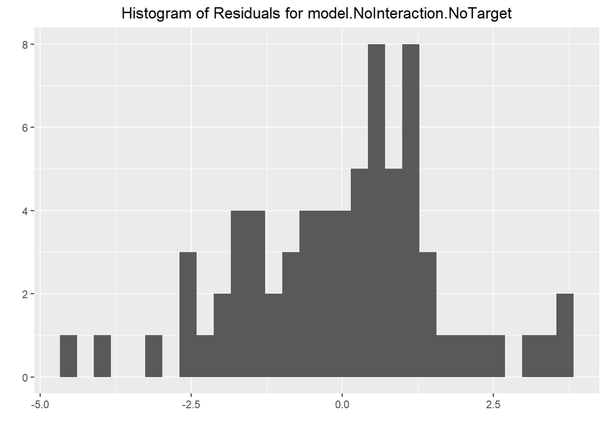

```r
#Plot location
setwd(figure_directory)

# Data to fit
data_modified_team <- team_data %>%
  select(TeamScore,
         params$dependent_response_team,
         params$dependent_response_DominateStrategy,
         Target,
         SessionOrder,
         Team) %>%
  mutate(sqrt.value = sqrt(.data[[params$dependent_response_team]]))

# Generate models with variable response
GA_data_focus_team <- data_modified_team %>%
  filter(.data[[params$dependent_response_DominateStrategy]] == params$Strategy_GA_name_WithSpace)

# Generate non-robust models - NoInteractionNoTarget
model.NoInteraction.NoTarget <- model_data_Target_Session(df = GA_data_focus_team, dependent =  "sqrt.value", model.type =  "NoInteraction_NoTarget", is.team = TRUE, is.robust = FALSE)

# Histogram of Residuals - model.NoInteraction.NoTarget
ggplot(model.NoInteraction.NoTarget, aes(x = .resid)) +
  geom_histogram(bins = 30) +
  labs(title = paste("Histogram of Residuals for model.NoInteraction.NoTarget"), x = "", y = "") +
  theme(plot.title = element_text(hjust = 0.5)) +
  ggsave(paste("Histogram_Residuals_", params$dependent_response_name_NoSpace, "_sqrt_NoInteractionNoTarget_", params$Strategy_GA_name_NoSpace,"_Team.png", sep = ""))
```

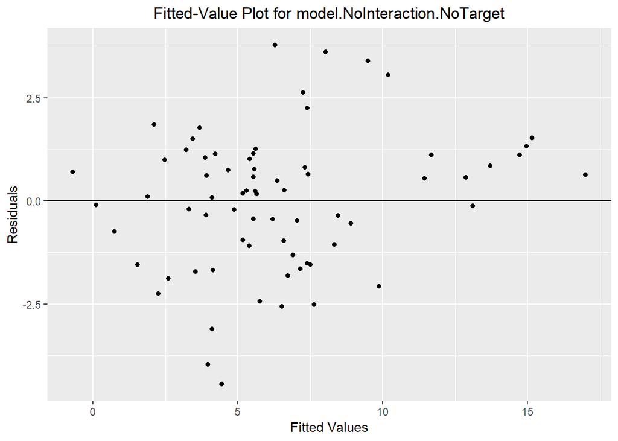

```r
# Fitted values - model.NoInteraction.NoTarget
ggplot(model.NoInteraction.NoTarget, aes(x = .fitted, y = .resid)) +
  geom_point() +
  geom_hline(yintercept = 0)+
  labs(title = paste("Fitted-Value Plot for model.NoInteraction.NoTarget"), x = "Fitted Values", y = "Residuals") +
  theme(plot.title = element_text(hjust = 0.5)) +
  ggsave(paste("FitteValue_Residuals_", params$dependent_response_name_NoSpace, "_sqrt_NoInteractionNoTarget_", params$Strategy_GA_name_NoSpace,"_Team.png", sep = ""))
```

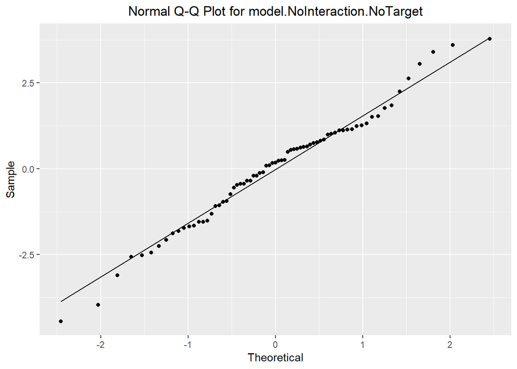

```r
# QQ plots - model.NoInteraction.NoTarget
ggplot(model.NoInteraction.NoTarget, aes(sample = .resid)) +
  stat_qq() +
  stat_qq_line()+
  labs(title = "Normal Q-Q Plot for model.NoInteraction.NoTarget", x = "Theoretical", y = "Sample") +
   theme(plot.title = element_text(hjust = 0.5)) +
  ggsave(paste("QQ_Residuals_", params$dependent_response_name_NoSpace, "_sqrt_NoInteractionNoTarget_", params$Strategy_GA_name_NoSpace,"_Team.png", sep = ""))
```

It looks like there may still be a violation with assumption 2 and 3.

```r
# Data to fit
data_modified_team <- team_data %>%
  select(TeamScore,
         params$dependent_response_team,
         params$dependent_response_DominateStrategy,
         Target,
         SessionOrder,
         Team) %>%
  mutate(sqrt.value = sqrt(.data[[params$dependent_response_team]]))

# Generate models with variable response
GA_data_focus_team <- data_modified_team %>%
  filter(.data[[params$dependent_response_DominateStrategy]] == params$Strategy_GA_name_WithSpace)

# Generate robust and non-robust models - model.NoInteraction.NoTarget
model.NoInteraction.NoTarget <- model_data_Target_Session(df = GA_data_focus_team, dependent =  "sqrt.value", model.type =  "NoInteraction_NoTarget", is.team = TRUE, is.robust = FALSE)
rmodel.NoInteraction.NoTarget <- model_data_Target_Session(df = GA_data_focus_team, dependent =  "sqrt.value", model.type =  "NoInteraction_NoTarget", is.team = TRUE, is.robust = TRUE)

comparision_results <- compare(model.NoInteraction.NoTarget, rmodel.NoInteraction.NoTarget, show.rho.functions = FALSE)

comparision_results %>%
  kable(caption = "model.NoInteraction.NoTarget") %>%
  kable_styling()
```

model.NoInteraction.NoTarget

|  | model.NoInteraction.NoTarget | rmodel.NoInteraction.NoTarget |
| --- | --- | --- |
| Coef |  |  |
| (Intercept) | 4.91 (0.792) | 4.72 (0.609) |
| SessionOrder3 | 1.44 (0.612) | 1.23 (0.523) |
| SessionOrder4 | 3.29 (0.622) | 2.83 (0.531) |
| VarComp |  |  |
| (Intercept) \| Team | 3.53 | 2.53 |
| sigma | 2.06 | 1.72 |
| REML | 356 |  |

I see no concernable difference when I compared the classic model to the robust model.

#### GT

**Dont need to transform data.**

## Individual

### GA

#### Model.NoInteraction

```r
# Plot location
setwd(figure_directory)

# Data to model
data_modified_ind <- ind_data %>%
  select(params$dependent_response_ind,
         params$dependent_response_DominateStrategy,
         Target,
         SessionOrder,
         Team,
         Player_ID) %>%
  mutate(sqrt.value = sqrt(ifelse(.data[[params$dependent_response_ind]] < 0, 0, .data[[params$dependent_response_ind]]))) # Some of the time remaining vaules are negative when the should be zero. I want to make sure those values are zero

# Generate models with variable response
GA_data_focus_ind <- data_modified_ind %>%
  filter(.data[[params$dependent_response_DominateStrategy]] == params$Strategy_GA_name_WithSpace)


# Generate models with variable response
model.NoInteraction <- model_data_Target_Session(df = GA_data_focus_ind, dependent =  "sqrt.value", model.type =  "NoInteraction", is.team = FALSE, is.robust = FALSE)
```

```
## boundary (singular) fit: see ?isSingular
```

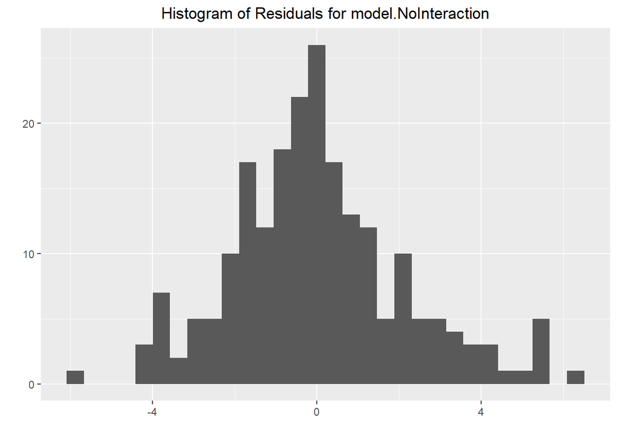

```r
# Histogram of Residuals - model.NoInteraction
ggplot(model.NoInteraction, aes(x = .resid)) +
  geom_histogram(bins = 30) +
  labs(title = paste("Histogram of Residuals for model.NoInteraction"), x = "", y = "") +
  theme(plot.title = element_text(hjust = 0.5)) +
  ggsave(paste("Histogram_Residuals_", params$dependent_response_name_NoSpace, "_sqrt_NoInteraction_", params$Strategy_GA_name_NoSpace ,"_Ind.png", sep =""))
```

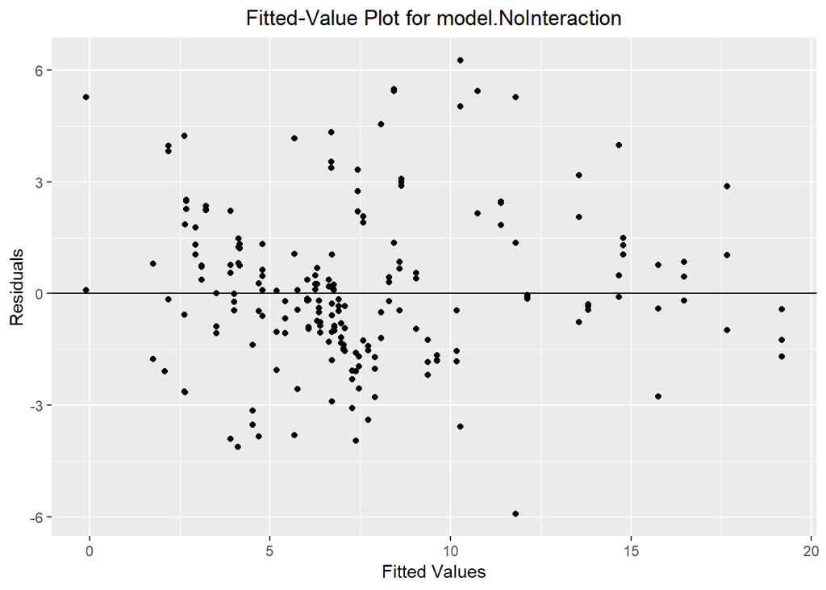

```r
# Fitted values - model.NoInteraction
ggplot(model.NoInteraction, aes(x = .fitted, y = .resid)) +
  geom_point() +
  geom_hline(yintercept = 0)+
  labs(title = paste("Fitted-Value Plot for model.NoInteraction"), x = "Fitted Values", y = "Residuals") +
  theme(plot.title = element_text(hjust = 0.5)) +
  ggsave(paste("FittedValue_Residuals_", params$dependent_response_name_NoSpace, "_sqrt_NoInteraction_", params$Strategy_GA_name_NoSpace ,"_Ind.png", sep =""))
```

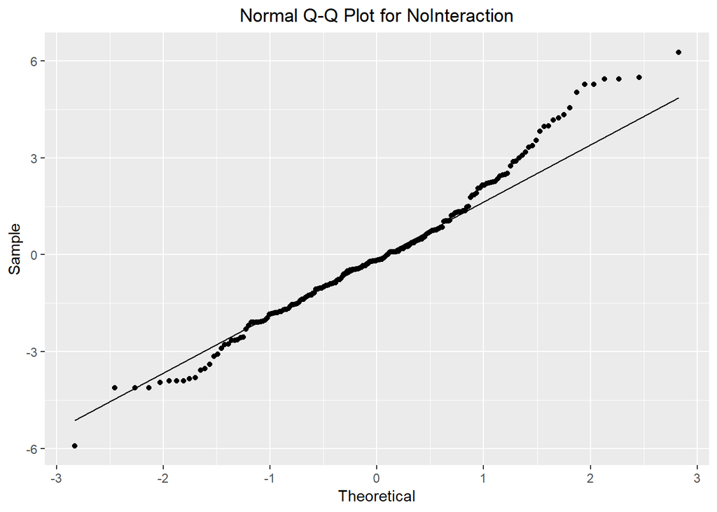

```r
# QQ plots - model.NoInteraction
ggplot(model.NoInteraction, aes(sample = .resid)) +
  stat_qq() +
  stat_qq_line()+
  labs(title = "Normal Q-Q Plot for NoInteraction", x = "Theoretical", y = "Sample") +
  theme(plot.title = element_text(hjust = 0.5)) +
  ggsave(paste("QQ_Residuals_", params$dependent_response_name_NoSpace, "_sqrt_NoInteraction_", params$Strategy_GA_name_NoSpace ,"_Ind.png", sep =""))
```

It looks like there may still be a violation with assumption 3.

```r
# Data to model
data_modified_ind <- ind_data %>%
  select(params$dependent_response_ind,
         params$dependent_response_DominateStrategy,
         Target,
         SessionOrder,
         Team,
         Player_ID) %>%
  mutate(sqrt.value = sqrt(ifelse(.data[[params$dependent_response_ind]] < 0, 0, .data[[params$dependent_response_ind]]))) # Some of the time remaining vaules are negative when the should be zero. I want to make sure those values are zero

# Generate models with variable response
GA_data_focus_ind <- data_modified_ind %>%
  filter(.data[[params$dependent_response_DominateStrategy]] == params$Strategy_GA_name_WithSpace)

model.NoInteraction <- model_data_Target_Session(df = GA_data_focus_ind, dependent =  "sqrt.value", model.type =  "NoInteraction", is.team = FALSE, is.robust = FALSE)
```

```
## boundary (singular) fit: see ?isSingular
```

```r
rmodel.NoInteraction <- model_data_Target_Session(df = GA_data_focus_ind, dependent =  "sqrt.value", model.type =  "NoInteraction", is.team = FALSE, is.robust = TRUE)
```

```
## boundary (singular) fit: see ?isSingular
```

```r
comparision_results <- compare(model.NoInteraction, rmodel.NoInteraction, show.rho.functions = FALSE)

comparision_results %>%
  kable(caption = "model.NoInteraction") %>%
  kable_styling()
```

model.NoInteraction

|  | model.NoInteraction | rmodel.NoInteraction |
| --- | --- | --- |
| Coef |  |  |
| (Intercept) | 5.674 (0.778) | 5.082 (0.627) |
| TargetInd_Team | -0.808 (0.398) | -0.596 (0.367) |
| TargetTeam | 0.253 (0.400) | 0.349 (0.369) |
| SessionOrder3 | 1.937 (0.397) | 1.826 (0.366) |
| SessionOrder4 | 3.719 (0.401) | 3.506 (0.369) |
| VarComp |  |  |
| (Intercept) \| Player_ID | 0.00 | 0.00 |
| (Intercept) \| Team | 3.60 | 2.72 |
| sigma | 2.29 | 2.06 |
| REML | 1031 |  |

I see no concernable difference when I compared the classic model to the robust model.

#### Model.NoInteraction.NoTarget

```r
# Plot location
setwd(figure_directory)

# Data to model
data_modified_ind <- ind_data %>%
  select(params$dependent_response_ind,
         params$dependent_response_DominateStrategy,
         Target,
         SessionOrder,
         Team,
         Player_ID) %>%
  mutate(sqrt.value = sqrt(ifelse(.data[[params$dependent_response_ind]] < 0, 0, .data[[params$dependent_response_ind]]))) # Some of the time remaining vaules are negative when the should be zero. I want to make sure those values are zero

# Generate models with variable response
GA_data_focus_ind <- data_modified_ind %>%
  filter(.data[[params$dependent_response_DominateStrategy]] == params$Strategy_GA_name_WithSpace)


# Generate models with variable response
model.NoInteraction.NoTarget <- model_data_Target_Session(df = GA_data_focus_ind, dependent =  "sqrt.value", model.type =  "NoInteraction_NoTarget", is.team = FALSE, is.robust = FALSE)
```

```
## boundary (singular) fit: see ?isSingular
```

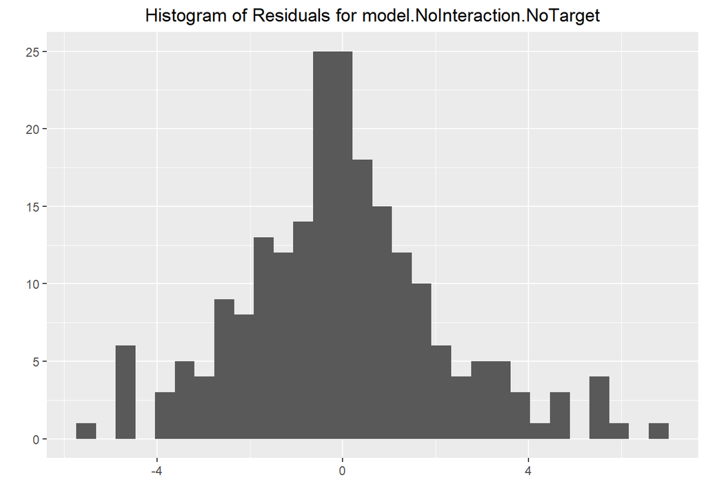

```r
# Histogram of Residuals - model.NoInteraction.NoTarget
ggplot(model.NoInteraction.NoTarget, aes(x = .resid)) +
  geom_histogram(bins = 30) +
  labs(title = paste("Histogram of Residuals for model.NoInteraction.NoTarget"), x = "", y = "") +
  theme(plot.title = element_text(hjust = 0.5)) +
  ggsave(paste("Histogram_Residuals_", params$dependent_response_name_NoSpace, "_sqrt_NoInteractionNoTarget_", params$Strategy_GA_name_NoSpace ,"_Ind.png", sep =""))
```

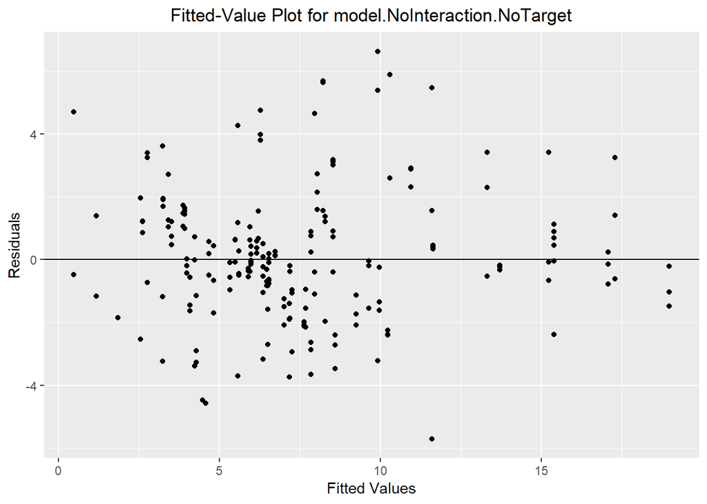

```r
# Fitted values - model.NoInteraction.NoTarget
ggplot(model.NoInteraction.NoTarget, aes(x = .fitted, y = .resid)) +
  geom_point() +
  geom_hline(yintercept = 0)+
  labs(title = paste("Fitted-Value Plot for model.NoInteraction.NoTarget"), x = "Fitted Values", y = "Residuals") +
  theme(plot.title = element_text(hjust = 0.5)) +
  ggsave(paste("FittedValue_Residuals_", params$dependent_response_name_NoSpace, "_sqrt_NoInteractionNoTarget_", params$Strategy_GA_name_NoSpace ,"_Ind.png", sep =""))
```

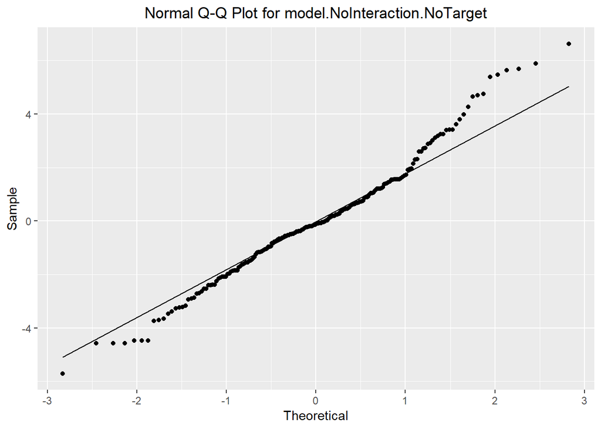

```r
# QQ plots - model.NoInteraction.NoTarget
ggplot(model.NoInteraction.NoTarget, aes(sample = .resid)) +
  stat_qq() +
  stat_qq_line()+
  labs(title = "Normal Q-Q Plot for model.NoInteraction.NoTarget", x = "Theoretical", y = "Sample") +
  theme(plot.title = element_text(hjust = 0.5)) +
  ggsave(paste("QQ_Residuals_", params$dependent_response_name_NoSpace, "_sqrt_NoInteractionNoTarget_", params$Strategy_GA_name_NoSpace ,"_Ind.png", sep =""))
```

It looks like there may still be a violation with assumption 3.

```r
# Data to model
data_modified_ind <- ind_data %>%
  select(params$dependent_response_ind,
         params$dependent_response_DominateStrategy,
         Target,
         SessionOrder,
         Team,
         Player_ID) %>%
  mutate(sqrt.value = sqrt(ifelse(.data[[params$dependent_response_ind]] < 0, 0, .data[[params$dependent_response_ind]]))) # Some of the time remaining vaules are negative when the should be zero. I want to make sure those values are zero

# Generate models with variable response
GA_data_focus_ind <- data_modified_ind %>%
  filter(.data[[params$dependent_response_DominateStrategy]] == params$Strategy_GA_name_WithSpace)

model.NoInteraction.NoTarget <- model_data_Target_Session(df = GA_data_focus_ind, dependent =  "sqrt.value", model.type =  "NoInteraction_NoTarget", is.team = FALSE, is.robust = FALSE)
```

```
## boundary (singular) fit: see ?isSingular
```

```r
rmodel.NoInteraction.NoTarget <- model_data_Target_Session(df = GA_data_focus_ind, dependent =  "sqrt.value", model.type =  "NoInteraction_NoTarget", is.team = FALSE, is.robust = TRUE)
```

```
## boundary (singular) fit: see ?isSingular
```

```r
comparision_results <- compare(model.NoInteraction.NoTarget, rmodel.NoInteraction.NoTarget, show.rho.functions = FALSE)

comparision_results %>%
  kable(caption = "model.NoInteraction.NoTarget") %>%
  kable_styling()
```

model.NoInteraction.NoTarget

|  | model.NoInteraction.NoTarget | rmodel.NoInteraction.NoTarget |
| --- | --- | --- |
| Coef |  |  |
| (Intercept) | 5.47 (0.747) | 5.07 (0.582) |
| SessionOrder3 | 2.07 (0.400) | 1.86 (0.358) |
| SessionOrder4 | 3.75 (0.406) | 3.38 (0.364) |
| VarComp |  |  |
| (Intercept) \| Player_ID | 0.00 | 0.00 |
| (Intercept) \| Team | 3.63 | 2.69 |
| sigma | 2.32 | 2.03 |
| REML | 1039 |  |

I see no concernable difference when I compared the classic model to the robust model.

### GT

#### Model.All

```r
# Plot location
setwd(figure_directory)

# Data to model
data_modified_ind <- ind_data %>%
  select(params$dependent_response_ind,
         params$dependent_response_DominateStrategy,
         Target,
         SessionOrder,
         Team,
         Player_ID) %>%
  mutate(sqrt.value = sqrt(ifelse(.data[[params$dependent_response_ind]] < 0, 0, .data[[params$dependent_response_ind]]))) # Some of the time remaining vaules are negative when the should be zero. I want to make sure those values are zero

# Generate models with variable response
GT_data_focus_ind <- data_modified_ind %>%
  filter(.data[[params$dependent_response_DominateStrategy]] == params$Strategy_GT_name_WithSpace)

# Generate models with variable response
model.All <- model_data_Target_Session(df = GT_data_focus_ind, dependent =  "sqrt.value", model.type =  "All", is.team = FALSE, is.robust = FALSE)
```

```
## boundary (singular) fit: see ?isSingular
```

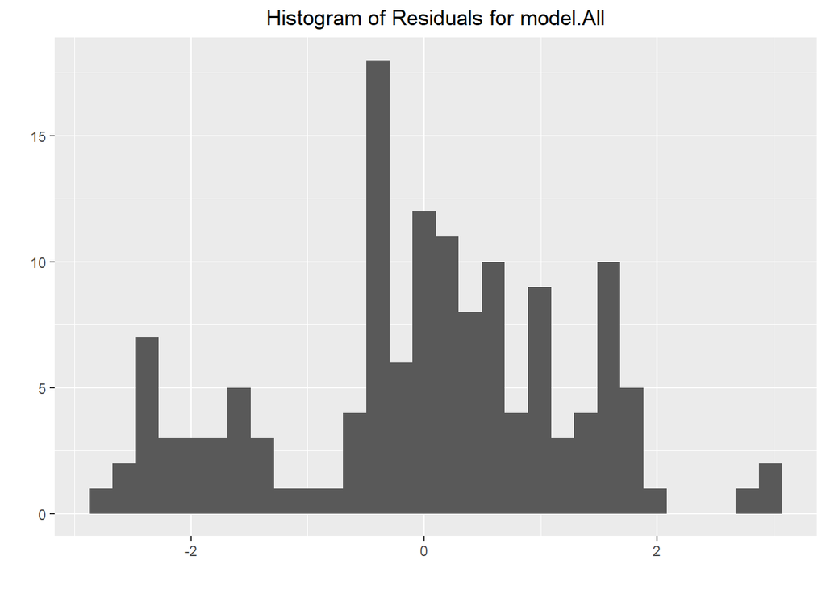

```r
# Histogram of Residuals - model.All
ggplot(model.All, aes(x = .resid)) +
  geom_histogram(bins = 30) +
  labs(title = paste("Histogram of Residuals for model.All"), x = "", y = "") +
  theme(plot.title = element_text(hjust = 0.5)) +
  ggsave(paste("Histogram_Residuals_", params$dependent_response_name_NoSpace, "_sqrt_All_", params$Strategy_GT_name_NoSpace,"_Ind.png", sep =""))
```

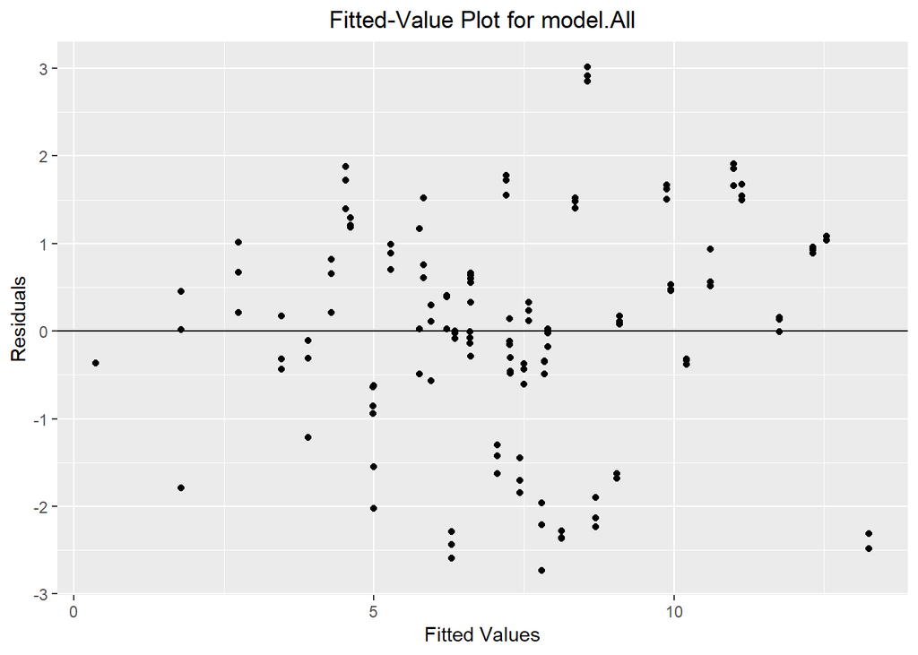

```r
# Fitted values - model.All
ggplot(model.All, aes(x = .fitted, y = .resid)) +
  geom_point() +
  geom_hline(yintercept = 0)+
  labs(title = paste("Fitted-Value Plot for model.All"), x = "Fitted Values", y = "Residuals") +
  theme(plot.title = element_text(hjust = 0.5)) +
  ggsave(paste("FittedValue_Residuals_", params$dependent_response_name_NoSpace, "_sqrt_All_", params$Strategy_GT_name_NoSpace,"_Ind.png", sep =""))
```

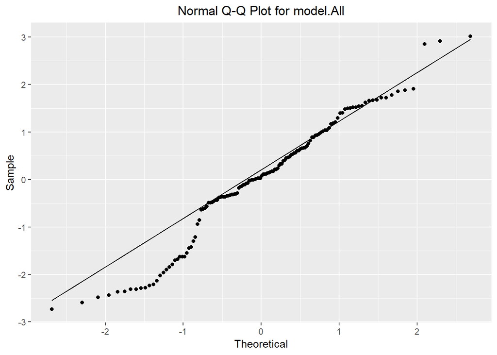

```r
# QQ plots - model.All
ggplot(model.All, aes(sample = .resid)) +
  stat_qq() +
  stat_qq_line()+
  labs(title = "Normal Q-Q Plot for model.All", x = "Theoretical", y = "Sample") +
  theme(plot.title = element_text(hjust = 0.5)) +
  ggsave(paste("QQ_Residuals_", params$dependent_response_name_NoSpace, "_sqrt_All_", params$Strategy_GT_name_NoSpace,"_Ind.png", sep =""))
```

It looks like there may still be a violation with assumption 2 and 3.

```r
# Data to model
data_modified_ind <- ind_data %>%
  select(params$dependent_response_ind,
         params$dependent_response_DominateStrategy,
         Target,
         SessionOrder,
         Team,
         Player_ID) %>%
  mutate(sqrt.value = sqrt(ifelse(.data[[params$dependent_response_ind]] < 0, 0, .data[[params$dependent_response_ind]]))) # Some of the time remaining vaules are negative when the should be zero. I want to make sure those values are zero

# Generate models with variable response
GT_data_focus_ind <- data_modified_ind %>%
  filter(.data[[params$dependent_response_DominateStrategy]] == params$Strategy_GT_name_WithSpace)

model.All <- model_data_Target_Session(df = GA_data_focus_ind, dependent =  "sqrt.value", model.type =  "All", is.team = FALSE, is.robust = FALSE)
```

```
## boundary (singular) fit: see ?isSingular
```

```r
rmodel.All <- model_data_Target_Session(df = GA_data_focus_ind, dependent =  "sqrt.value", model.type =  "All", is.team = FALSE, is.robust = TRUE)
```

```
## boundary (singular) fit: see ?isSingular
```

```r
comparision_results <- compare(model.All, rmodel.All, show.rho.functions = FALSE)

comparision_results %>%
  kable(caption = "model.All") %>%
  kable_styling()
```

model.All

|  | model.All | rmodel.All |
| --- | --- | --- |
| Coef |  |  |
| (Intercept) | 5.166 (0.921) | 4.647 (0.784) |
| TargetInd_Team | 0.270 (0.881) | 0.384 (0.816) |
| TargetTeam | 0.647 (0.911) | 0.735 (0.840) |
| SessionOrder3 | 2.665 (0.881) | 2.645 (0.815) |
| SessionOrder4 | 4.591 (0.923) | 4.096 (0.855) |
| TargetInd_Team:SessionOrder3 | -1.746 (1.366) | -1.674 (1.265) |
| TargetTeam:SessionOrder3 | -0.389 (1.364) | -0.848 (1.259) |
| TargetInd_Team:SessionOrder4 | -1.610 (1.376) | -1.307 (1.274) |
| TargetTeam:SessionOrder4 | -0.735 (1.338) | -0.282 (1.239) |
| VarComp |  |  |
| (Intercept) \| Player_ID | 3.72e-05 | 0.00e+00 |
| (Intercept) \| Team | 3.60e+00 | 2.77e+00 |
| sigma | 2.3 | 2.1 |
| REML | 1020 |  |

I see no concernable difference when I compared the classic model to the robust model.

#### Model.NoInteraction

```r
# Plot location
setwd(figure_directory)

# Data to model
data_modified_ind <- ind_data %>%
  select(params$dependent_response_ind,
         params$dependent_response_DominateStrategy,
         Target,
         SessionOrder,
         Team,
         Player_ID) %>%
  mutate(sqrt.value = sqrt(ifelse(.data[[params$dependent_response_ind]] < 0, 0, .data[[params$dependent_response_ind]]))) # Some of the time remaining vaules are negative when the should be zero. I want to make sure those values are zero

# Generate models with variable response
GT_data_focus_ind <- data_modified_ind %>%
  filter(.data[[params$dependent_response_DominateStrategy]] == params$Strategy_GT_name_WithSpace)

# Generate models with variable response
model.NoInteraction <- model_data_Target_Session(df = GT_data_focus_ind, dependent =  "sqrt.value", model.type =  "NoInteraction", is.team = FALSE, is.robust = FALSE)
```

```
## boundary (singular) fit: see ?isSingular
```

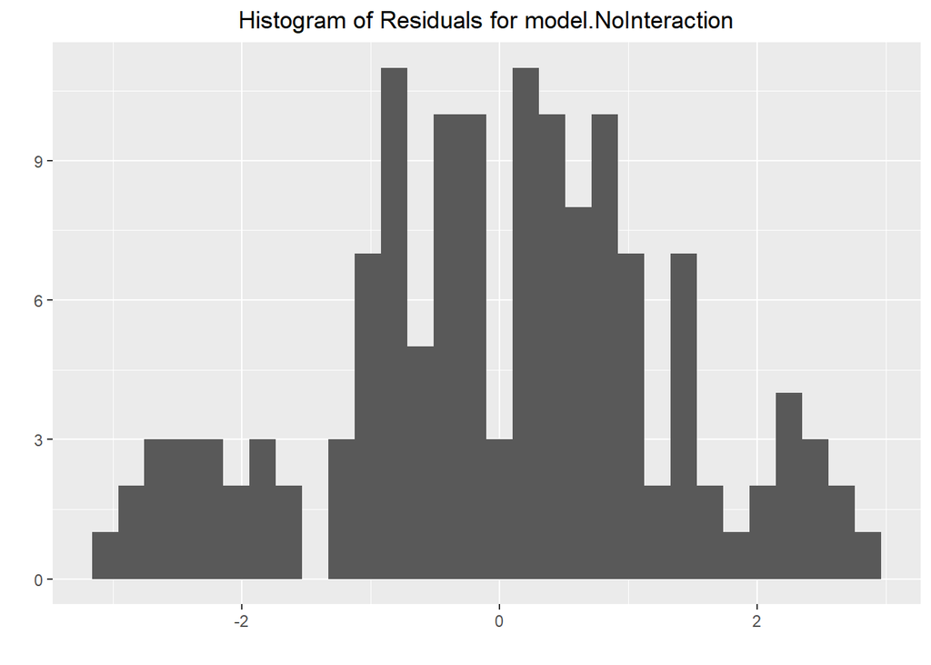

```r
# Histogram of Residuals - model.NoInteraction
ggplot(model.NoInteraction, aes(x = .resid)) +
  geom_histogram(bins = 30) +
  labs(title = paste("Histogram of Residuals for model.NoInteraction"), x = "", y = "") +
  theme(plot.title = element_text(hjust = 0.5)) +
  ggsave(paste("Histogram_Residuals_", params$dependent_response_name_NoSpace, "_sqrt_NoInteraction", params$Strategy_GT_name_NoSpace,"_Ind.png", sep =""))
```

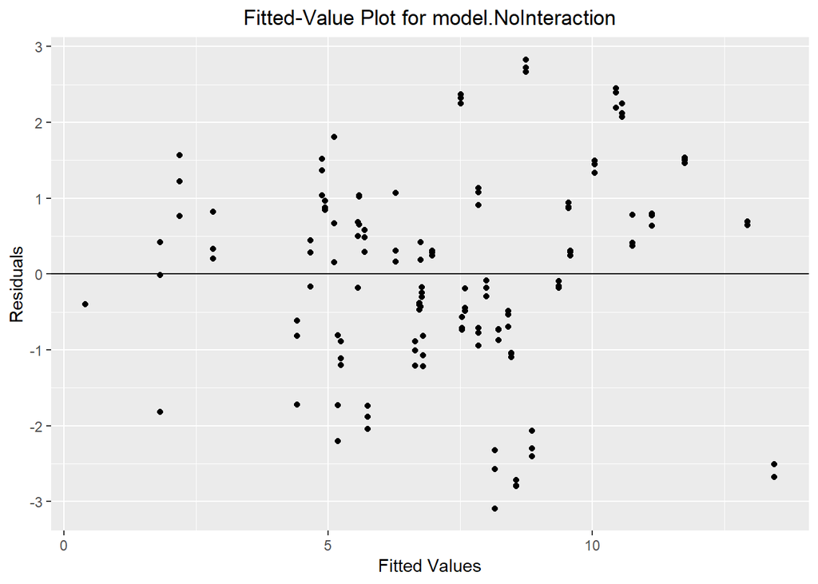

```r
# Fitted values - model.NoInteraction
ggplot(model.NoInteraction, aes(x = .fitted, y = .resid)) +
  geom_point() +
  geom_hline(yintercept = 0)+
  labs(title = paste("Fitted-Value Plot for model.NoInteraction"), x = "Fitted Values", y = "Residuals") +
  theme(plot.title = element_text(hjust = 0.5)) +
  ggsave(paste("FittedValue_Residuals_", params$dependent_response_name_NoSpace, "_sqrt_NoInteraction", params$Strategy_GT_name_NoSpace,"_Ind.png", sep =""))
```

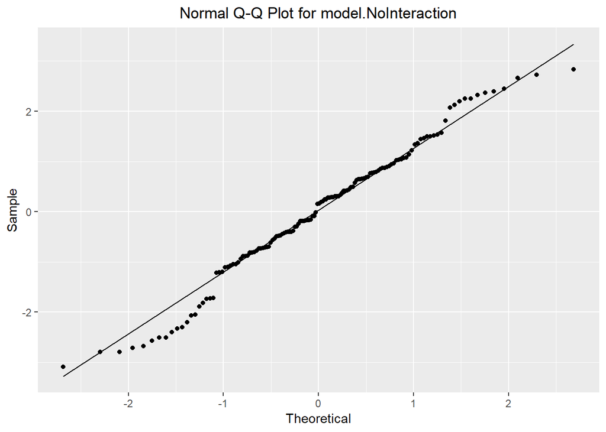

```r
# QQ plots - model.NoInteraction
ggplot(model.NoInteraction, aes(sample = .resid)) +
  stat_qq() +
  stat_qq_line()+
  labs(title = "Normal Q-Q Plot for model.NoInteraction", x = "Theoretical", y = "Sample") +
  theme(plot.title = element_text(hjust = 0.5)) +
  ggsave(paste("QQ_Residuals_", params$dependent_response_name_NoSpace, "_sqrt_NoInteraction", params$Strategy_GT_name_NoSpace,"_Ind.png", sep =""))
```

It looks like there may still be a violation with assumption 3.

```r
# Data to model
data_modified_ind <- ind_data %>%
  select(params$dependent_response_ind,
         params$dependent_response_DominateStrategy,
         Target,
         SessionOrder,
         Team,
         Player_ID) %>%
  mutate(sqrt.value = sqrt(ifelse(.data[[params$dependent_response_ind]] < 0, 0, .data[[params$dependent_response_ind]]))) # Some of the time remaining vaules are negative when the should be zero. I want to make sure those values are zero

# Generate models with variable response
GT_data_focus_ind <- data_modified_ind %>%
  filter(.data[[params$dependent_response_DominateStrategy]] == params$Strategy_GT_name_WithSpace)

model.NoInteraction <- model_data_Target_Session(df = GA_data_focus_ind, dependent =  "sqrt.value", model.type =  "NoInteraction", is.team = FALSE, is.robust = FALSE)
```

```
## boundary (singular) fit: see ?isSingular
```

```r
rmodel.NoInteraction <- model_data_Target_Session(df = GA_data_focus_ind, dependent =  "sqrt.value", model.type =  "NoInteraction", is.team = FALSE, is.robust = TRUE)
```

```
## boundary (singular) fit: see ?isSingular
```

```r
comparision_results <- compare(model.NoInteraction, rmodel.NoInteraction, show.rho.functions = FALSE)

comparision_results %>%
  kable(caption = "model.NoInteraction") %>%
  kable_styling()
```

model.NoInteraction

|  | model.NoInteraction | rmodel.NoInteraction |
| --- | --- | --- |
| Coef |  |  |
| (Intercept) | 5.674 (0.778) | 5.082 (0.627) |
| TargetInd_Team | -0.808 (0.398) | -0.596 (0.367) |
| TargetTeam | 0.253 (0.400) | 0.349 (0.369) |
| SessionOrder3 | 1.937 (0.397) | 1.826 (0.366) |
| SessionOrder4 | 3.719 (0.401) | 3.506 (0.369) |
| VarComp |  |  |
| (Intercept) \| Player_ID | 0.00 | 0.00 |
| (Intercept) \| Team | 3.60 | 2.72 |
| sigma | 2.29 | 2.06 |
| REML | 1031 |  |

I see no concernable difference when I compared the classic model to the robust model.

## Summary

Overall, transforming the data reduced the influnce of the violations. There were instances where the transformation seemed to not address the assumptions but comparing the classic model to the robust model showed no concernable difference.

# Q: Are there any effects that are significant?

## Team

### Model.NoInteraction

#### GA

```r
# Data to fit
data_modified_team <- team_data %>%
  select(TeamScore,
         params$dependent_response_team,
         params$dependent_response_DominateStrategy,
         Target,
         SessionOrder,
         Team) %>%
  mutate(sqrt.value = sqrt(.data[[params$dependent_response_team]]))

# Generate models with variable response
GA_data_focus_team <- data_modified_team %>%
  filter(.data[[params$dependent_response_DominateStrategy]] == params$Strategy_GA_name_WithSpace)

# Generate robust and non-robust models - NoInteraction
model.NoInteraction <- model_data_Target_Session(df = GA_data_focus_team, dependent =  "sqrt.value", model.type =  "NoInteraction", is.team = TRUE, is.robust = FALSE)

summary(model.NoInteraction)
```

```
## Linear mixed model fit by REML. t-tests use Satterthwaite's method [
## lmerModLmerTest]
## Formula:
## as.formula(paste(dependent, "~ Target + SessionOrder + (1|Team)"))
##    Data: df
##
## REML criterion at convergence: 351.8
##
## Scaled residuals:
##      Min       1Q   Median       3Q      Max
## -1.98063 -0.49861  0.05477  0.42168  1.75598
##
## Random effects:
##  Groups   Name        Variance Std.Dev.
##  Team     (Intercept) 12.320   3.510
##  Residual              4.221   2.055
## Number of obs: 71, groups:  Team, 27
##
## Fixed effects:
##                Estimate Std. Error      df t value Pr(>|t|)
## (Intercept)      4.9760     0.8703 48.5260   5.717 6.54e-07 ***
## TargetInd_Team  -0.5773     0.6173 42.0871  -0.935   0.3550
## TargetTeam       0.4129     0.6188 42.8586   0.667   0.5082
## SessionOrder3    1.3437     0.6141 42.8166   2.188   0.0342 *
## SessionOrder4    3.2671     0.6195 42.7223   5.274 4.17e-06 ***
## ---
## Signif. codes:  0 '***' 0.001 '**' 0.01 '*' 0.05 '.' 0.1 ' ' 1
##
## Correlation of Fixed Effects:
##             (Intr) TrgI_T TrgtTm SssnO3
## TargtInd_Tm -0.371
## TargetTeam  -0.365  0.505
## SessinOrdr3 -0.350  0.122  0.035
## SessinOrdr4 -0.315  0.023  0.003  0.497
```

The results show no significant effect from Target variables. The results show a significant effect from session 3 and 4.

```r
# Data to fit
data_modified_team <- team_data %>%
  select(TeamScore,
         params$dependent_response_team,
         params$dependent_response_DominateStrategy,
         Target,
         SessionOrder,
         Team) %>%
  mutate(sqrt.value = sqrt(.data[[params$dependent_response_team]]))

# Generate models with variable response
GA_data_focus_team <- data_modified_team %>%
  filter(.data[[params$dependent_response_DominateStrategy]] == params$Strategy_GA_name_WithSpace)

# Generate robust and non-robust models - NoInteraction
model.NoInteraction <- model_data_Target_Session(df = GA_data_focus_team, dependent =  "sqrt.value", model.type =  "NoInteraction", is.team = TRUE, is.robust = FALSE)

emmeans(model.NoInteraction, list(pairwise ~ Target), adjust = "tukey")
```

```
## $`emmeans of Target`
##  Target   emmean    SE   df lower.CL upper.CL
##  Ind        6.51 0.804 37.8     4.88     8.14
##  Ind_Team   5.94 0.817 39.2     4.28     7.59
##  Team       6.93 0.804 37.8     5.30     8.55
##
## Results are averaged over the levels of: SessionOrder
## Degrees-of-freedom method: kenward-roger
## Confidence level used: 0.95
##
## $`pairwise differences of Target`
##  contrast        estimate    SE   df t.ratio p.value
##  Ind - Ind_Team     0.577 0.618 41.2  0.934  0.6223
##  Ind - Team        -0.413 0.620 42.0 -0.666  0.7846
##  Ind_Team - Team   -0.990 0.616 41.1 -1.609  0.2535
##
## Results are averaged over the levels of: SessionOrder
## P value adjustment: tukey method for comparing a family of 3 estimates
```

The results showed no signifcant difference among the Target levels.

```r
# Data to fit
data_modified_team <- team_data %>%
  select(TeamScore,
         params$dependent_response_team,
         params$dependent_response_DominateStrategy,
         Target,
         SessionOrder,
         Team) %>%
  mutate(sqrt.value = sqrt(.data[[params$dependent_response_team]]))

# Generate models with variable response
GA_data_focus_team <- data_modified_team %>%
  filter(.data[[params$dependent_response_DominateStrategy]] == params$Strategy_GA_name_WithSpace)

# Generate robust and non-robust models - NoInteraction
model.NoInteraction <- model_data_Target_Session(df = GA_data_focus_team, dependent =  "sqrt.value", model.type =  "NoInteraction", is.team = TRUE, is.robust = FALSE)

emmeans(model.NoInteraction, list(pairwise ~ SessionOrder), adjust = "tukey")
```

```
## $`emmeans of SessionOrder`
##  SessionOrder emmean    SE   df lower.CL upper.CL
##  2              4.92 0.788 35.7     3.32     6.52
##  3              6.26 0.816 39.1     4.61     7.92
##  4              8.19 0.821 39.9     6.53     9.85
##
## Results are averaged over the levels of: Target
## Degrees-of-freedom method: kenward-roger
## Confidence level used: 0.95
##
## $`pairwise differences of SessionOrder`
##  contrast estimate    SE   df t.ratio p.value
##  2 - 3       -1.34 0.616 41.9 -2.183  0.0859
##  2 - 4       -3.27 0.621 41.9 -5.262  <.0001
##  3 - 4       -1.92 0.619 40.3 -3.108  0.0095
##
## Results are averaged over the levels of: Target
## P value adjustment: tukey method for comparing a family of 3 estimates
```

The results showed a significant difference between session 2 and 4, and between session 3 and 4. The difference beteen session 2 and 3 is marginally significant, indiciating that more data is needed to reach significance. Overall, this means that the time remaining increased over time.

#### GT

```r
# Data to fit
data_modified_team <- team_data %>%
  select(TeamScore,
         params$dependent_response_team,
         params$dependent_response_DominateStrategy,
         Target,
         SessionOrder,
         Team)

# Generate models with variable response
GT_data_focus_team <- data_modified_team %>%
  filter(.data[[params$dependent_response_DominateStrategy]] == params$Strategy_GT_name_WithSpace)

# Generate robust and non-robust models - NoInteraction
model.NoInteraction <- model_data_Target_Session(df = GT_data_focus_team, dependent =  params$dependent_response_team, model.type =  "NoInteraction", is.team = TRUE, is.robust = FALSE)

summary(model.NoInteraction)
```

```
## Linear mixed model fit by REML. t-tests use Satterthwaite's method [
## lmerModLmerTest]
## Formula:
## as.formula(paste(dependent, "~ Target + SessionOrder + (1|Team)"))
##    Data: df
##
## REML criterion at convergence: 436.5
##
## Scaled residuals:
##     Min      1Q  Median      3Q     Max
## -1.2541 -0.5835 -0.1122  0.5053  1.7687
##
## Random effects:
##  Groups   Name        Variance Std.Dev.
##  Team     (Intercept) 1269     35.62
##  Residual             1022     31.97
## Number of obs: 46, groups:  Team, 18
##
## Fixed effects:
##                Estimate Std. Error    df t value Pr(>|t|)
## (Intercept)       25.81      13.70 39.10   1.884  0.06703 .
## TargetInd_Team     3.56      11.98 25.29   0.297  0.76879
## TargetTeam        16.54      12.38 26.93   1.336  0.19270
## SessionOrder3     25.48      12.63 26.00   2.017  0.05413 .
## SessionOrder4     44.25      12.50 26.80   3.539  0.00149 **
## ---
## Signif. codes:  0 '***' 0.001 '**' 0.01 '*' 0.05 '.' 0.1 ' ' 1
##
## Correlation of Fixed Effects:
##             (Intr) TrgI_T TrgtTm SssnO3
## TargtInd_Tm -0.342
## TargetTeam  -0.357  0.534
## SessinOrdr3 -0.423 -0.195 -0.143
## SessinOrdr4 -0.444 -0.155 -0.159  0.599
```

The results show no significant effect from the Target variable. The results show a significant effect from session 4 and a marginally significant effect from session 3 (p = 0.0541).

```r
# Data to fit
data_modified_team <- team_data %>%
  select(TeamScore,
         params$dependent_response_team,
         params$dependent_response_DominateStrategy,
         Target,
         SessionOrder,
         Team)

# Generate models with variable response
GT_data_focus_team <- data_modified_team %>%
  filter(.data[[params$dependent_response_DominateStrategy]] == params$Strategy_GT_name_WithSpace)

# Generate robust and non-robust models - NoInteraction
model.NoInteraction <- model_data_Target_Session(df = GT_data_focus_team, dependent =  params$dependent_response_team, model.type =  "NoInteraction", is.team = TRUE, is.robust = FALSE)

emmeans(model.NoInteraction, list(pairwise ~ Target), adjust = "tukey")
```

```
## $`emmeans of Target`
##  Target   emmean   SE   df lower.CL upper.CL
##  Ind        49.1 12.0 32.0     24.5     73.6
##  Ind_Team   52.6 11.9 31.2     28.4     76.8
##  Team       65.6 12.1 32.0     41.0     90.2
##
## Results are averaged over the levels of: SessionOrder
## Degrees-of-freedom method: kenward-roger
## Confidence level used: 0.95
##
## $`pairwise differences of Target`
##  contrast        estimate   SE   df t.ratio p.value
##  Ind - Ind_Team     -3.56 12.0 25.3 -0.296  0.9529
##  Ind - Team        -16.54 12.5 26.9 -1.325  0.3938
##  Ind_Team - Team   -12.98 11.8 25.2 -1.100  0.5230
##
## Results are averaged over the levels of: SessionOrder
## P value adjustment: tukey method for comparing a family of 3 estimates
```

The results show no significant difference among the Target levels

```r
# Data to fit
data_modified_team <- team_data %>%
  select(TeamScore,
         params$dependent_response_team,
         params$dependent_response_DominateStrategy,
         Target,
         SessionOrder,
         Team)

# Generate models with variable response
GT_data_focus_team <- data_modified_team %>%
  filter(.data[[params$dependent_response_DominateStrategy]] == params$Strategy_GT_name_WithSpace)

# Generate robust and non-robust models - NoInteraction
model.NoInteraction <- model_data_Target_Session(df = GT_data_focus_team, dependent =  params$dependent_response_team, model.type =  "NoInteraction", is.team = TRUE, is.robust = FALSE)

emmeans(model.NoInteraction, list(pairwise ~ SessionOrder), adjust = "tukey")
```

```
## $`emmeans of SessionOrder`
##  SessionOrder emmean   SE   df lower.CL upper.CL
##  2              32.5 12.7 34.9     6.66     58.4
##  3              58.0 11.8 30.9    33.87     82.1
##  4              76.8 11.5 29.4    53.17    100.4
##
## Results are averaged over the levels of: Target
## Degrees-of-freedom method: kenward-roger
## Confidence level used: 0.95
##
## $`pairwise differences of SessionOrder`
##  contrast estimate   SE   df t.ratio p.value
##  2 - 3       -25.5 12.7 26.0 -2.006  0.1308
##  2 - 4       -44.3 12.6 26.8 -3.512  0.0044
##  3 - 4       -18.8 11.3 24.7 -1.666  0.2380
##
## Results are averaged over the levels of: Target
## P value adjustment: tukey method for comparing a family of 3 estimates
```

The results only show a significant difference between sesson 2 and 4. Indicating the time remaining at the team level significantly increased when compared from start to finish.

### Model.NoInteraction.NoTarget

#### GA

```r
# Data to fit
data_modified_team <- team_data %>%
  select(TeamScore,
         params$dependent_response_team,
         params$dependent_response_DominateStrategy,
         Target,
         SessionOrder,
         Team) %>%
  mutate(sqrt.value = sqrt(.data[[params$dependent_response_team]]))

# Generate models with variable response
GA_data_focus_team <- data_modified_team %>%
  filter(.data[[params$dependent_response_DominateStrategy]] == params$Strategy_GA_name_WithSpace)

# Generate robust and non-robust models - NoInteraction
model.NoInteraction.NoTarget <- model_data_Target_Session(df = GA_data_focus_team, dependent =  "sqrt.value", model.type =  "NoInteraction_NoTarget", is.team = TRUE, is.robust = FALSE)

summary(model.NoInteraction.NoTarget)
```

```
## Linear mixed model fit by REML. t-tests use Satterthwaite's method [
## lmerModLmerTest]
## Formula: as.formula(paste(dependent, "~ SessionOrder + (1|Team)"))
##    Data: df
##
## REML criterion at convergence: 355.9
##
## Scaled residuals:
##      Min       1Q   Median       3Q      Max
## -2.14938 -0.52098  0.08547  0.50087  1.83225
##
## Random effects:
##  Groups   Name        Variance Std.Dev.
##  Team     (Intercept) 12.448   3.528
##  Residual              4.257   2.063
## Number of obs: 71, groups:  Team, 27
##
## Fixed effects:
##               Estimate Std. Error      df t value Pr(>|t|)
## (Intercept)     4.9098     0.7921 36.6548   6.199 3.51e-07 ***
## SessionOrder3   1.4383     0.6118 44.5354   2.351   0.0232 *
## SessionOrder4   3.2892     0.6219 44.6394   5.289 3.57e-06 ***
## ---
## Signif. codes:  0 '***' 0.001 '**' 0.01 '*' 0.05 '.' 0.1 ' ' 1
##
## Correlation of Fixed Effects:
##             (Intr) SssnO3
## SessinOrdr3 -0.346
## SessinOrdr4 -0.340  0.498
```

The results show a significant effect from session 3 and 4, in reference to session 2.

```r
# Data to fit
data_modified_team <- team_data %>%
  select(TeamScore,
         params$dependent_response_team,
         params$dependent_response_DominateStrategy,
         Target,
         SessionOrder,
         Team) %>%
  mutate(sqrt.value = sqrt(.data[[params$dependent_response_team]]))

# Generate models with variable response
GA_data_focus_team <- data_modified_team %>%
  filter(.data[[params$dependent_response_DominateStrategy]] == params$Strategy_GA_name_WithSpace)

# Generate robust and non-robust models - NoInteraction
model.NoInteraction.NoTarget <- model_data_Target_Session(df = GA_data_focus_team, dependent =  "sqrt.value", model.type =  "NoInteraction_NoTarget", is.team = TRUE, is.robust = FALSE)

emmeans(model.NoInteraction.NoTarget, list(pairwise ~ SessionOrder), adjust = "tukey")
```

```
## $`emmeans of SessionOrder`
##  SessionOrder emmean    SE   df lower.CL upper.CL
##  2              4.91 0.792 35.8     3.30     6.52
##  3              6.35 0.817 39.0     4.69     8.00
##  4              8.20 0.825 40.0     6.53     9.87
##
## Degrees-of-freedom method: kenward-roger
## Confidence level used: 0.95
##
## $`pairwise differences of SessionOrder`
##  contrast estimate    SE   df t.ratio p.value
##  2 - 3       -1.44 0.613 43.8 -2.346  0.0599
##  2 - 4       -3.29 0.623 43.9 -5.277  <.0001
##  3 - 4       -1.85 0.618 42.2 -2.993  0.0125
##
## P value adjustment: tukey method for comparing a family of 3 estimates
```

#### GT

DONT TRANSFORM

```r
# Data to fit
data_modified_team <- team_data %>%
  select(TeamScore,
         params$dependent_response_team,
         params$dependent_response_DominateStrategy,
         Target,
         SessionOrder,
         Team)

# Generate models with variable response
GT_data_focus_team <- data_modified_team %>%
  filter(.data[[params$dependent_response_DominateStrategy]] == params$Strategy_GT_name_WithSpace)

# Generate robust and non-robust models - NoInteraction
model.NoInteraction.NoTarget <- model_data_Target_Session(df = GT_data_focus_team, dependent =  params$dependent_response_team, model.type =  "NoInteraction_NoTarget", is.team = TRUE, is.robust = FALSE)

summary(model.NoInteraction.NoTarget)
```

```
## Linear mixed model fit by REML. t-tests use Satterthwaite's method [
## lmerModLmerTest]
## Formula: as.formula(paste(dependent, "~ SessionOrder + (1|Team)"))
##    Data: df
##
## REML criterion at convergence: 451.9
##
## Scaled residuals:
##     Min      1Q  Median      3Q     Max
## -1.4356 -0.4532 -0.1065  0.3367  1.8616
##
## Random effects:
##  Groups   Name        Variance Std.Dev.
##  Team     (Intercept) 1292     35.95
##  Residual             1015     31.86
## Number of obs: 46, groups:  Team, 18
##
## Fixed effects:
##               Estimate Std. Error    df t value Pr(>|t|)
## (Intercept)      31.07      12.59 34.94   2.467 0.018664 *
## SessionOrder3    27.03      12.34 27.83   2.191 0.036968 *
## SessionOrder4    46.44      12.26 28.30   3.787 0.000732 ***
## ---
## Signif. codes:  0 '***' 0.001 '**' 0.01 '*' 0.05 '.' 0.1 ' ' 1
##
## Correlation of Fixed Effects:
##             (Intr) SssnO3
## SessinOrdr3 -0.553
## SessinOrdr4 -0.568  0.586
```

The results show a significant effect from session 3 and 4, inreference to session 2.

```r
# Data to fit
data_modified_team <- team_data %>%
  select(TeamScore,
         params$dependent_response_team,
         params$dependent_response_DominateStrategy,
         Target,
         SessionOrder,
         Team)

# Generate models with variable response
GT_data_focus_team <- data_modified_team %>%
  filter(.data[[params$dependent_response_DominateStrategy]] == params$Strategy_GT_name_WithSpace)

# Generate robust and non-robust models - NoInteraction
model.NoInteraction.NoTarget <- model_data_Target_Session(df = GT_data_focus_team, dependent =  params$dependent_response_team, model.type =  "NoInteraction_NoTarget", is.team = TRUE, is.robust = FALSE)

emmeans(model.NoInteraction.NoTarget, list(pairwise ~ SessionOrder), adjust = "tukey")
```

```
## $`emmeans of SessionOrder`
##  SessionOrder emmean   SE   df lower.CL upper.CL
##  2              31.1 12.6 35.0      5.4     56.7
##  3              58.1 11.8 30.8     34.0     82.2
##  4              77.5 11.6 29.5     53.9    101.1
##
## Degrees-of-freedom method: kenward-roger
## Confidence level used: 0.95
##
## $`pairwise differences of SessionOrder`
##  contrast estimate   SE   df t.ratio p.value
##  2 - 3       -27.0 12.4 28.0 -2.180  0.0924
##  2 - 4       -46.4 12.3 28.5 -3.763  0.0022
##  3 - 4       -19.4 11.2 26.7 -1.732  0.2121
##
## P value adjustment: tukey method for comparing a family of 3 estimates
```

The results only show a significant difference between session 2 and 4.

## Individual

### GA

#### Model.NoInteraction

```r
# Data to model
data_modified_ind <- ind_data %>%
  select(params$dependent_response_ind,
         params$dependent_response_DominateStrategy,
         Target,
         SessionOrder,
         Team,
         Player_ID) %>%
  mutate(sqrt.value = sqrt(ifelse(.data[[params$dependent_response_ind]] < 0, 0, .data[[params$dependent_response_ind]]))) # Some of the time remaining vaules are negative when the should be zero. I want to make sure those values are zero

# Generate models with variable response
GA_data_focus_ind <- data_modified_ind %>%
  filter(.data[[params$dependent_response_DominateStrategy]] == params$Strategy_GA_name_WithSpace)

# Generate models with variable response
model.NoInteraction <- model_data_Target_Session(df = GA_data_focus_ind, dependent =  "sqrt.value", model.type =  "NoInteraction", is.team = FALSE, is.robust = FALSE)
```

```
## boundary (singular) fit: see ?isSingular
```

```r
summary(model.NoInteraction)
```

```
## Linear mixed model fit by REML. t-tests use Satterthwaite's method [
## lmerModLmerTest]
## Formula:
## as.formula(paste(dependent, "~ Target + SessionOrder + (1|Team) + (1| Player_ID)"))
##    Data: df
##
## REML criterion at convergence: 1031.4
##
## Scaled residuals:
##      Min       1Q   Median       3Q      Max
## -2.58380 -0.57976 -0.07575  0.46070  2.74067
##
## Random effects:
##  Groups    Name        Variance Std.Dev.
##  Player_ID (Intercept)  0.000   0.000
##  Team      (Intercept) 12.986   3.604
##  Residual               5.226   2.286
## Number of obs: 213, groups:  Player_ID, 81; Team, 27
##
## Fixed effects:
##                Estimate Std. Error       df t value Pr(>|t|)
## (Intercept)      5.6739     0.7785  37.1138   7.289 1.15e-08 ***
## TargetInd_Team  -0.8077     0.3982 184.8849  -2.028    0.044 *
## TargetTeam       0.2534     0.4004 186.5385   0.633    0.528
## SessionOrder3    1.9368     0.3973 186.4545   4.875 2.32e-06 ***
## SessionOrder4    3.7192     0.4006 186.2115   9.284  < 2e-16 ***
## ---
## Signif. codes:  0 '***' 0.001 '**' 0.01 '*' 0.05 '.' 0.1 ' ' 1
##
## Correlation of Fixed Effects:
##             (Intr) TrgI_T TrgtTm SssnO3
## TargtInd_Tm -0.268
## TargetTeam  -0.263  0.507
## SessinOrdr3 -0.252  0.128  0.035
## SessinOrdr4 -0.226  0.029  0.001  0.503
## convergence code: 0
## boundary (singular) fit: see ?isSingular
```

The results show a significant effection from the Ind_Team condition in reference to the Ind condition. However, the result is close to 0.05, I think it will not be significant after the Tukey adjustment.

The results show a significant effect from session 3 and 4 in reference to session 2.

```r
# Data to model
data_modified_ind <- ind_data %>%
  select(params$dependent_response_ind,
         params$dependent_response_DominateStrategy,
         Target,
         SessionOrder,
         Team,
         Player_ID) %>%
  mutate(sqrt.value = sqrt(ifelse(.data[[params$dependent_response_ind]] < 0, 0, .data[[params$dependent_response_ind]]))) # Some of the time remaining vaules are negative when the should be zero. I want to make sure those values are zero

# Generate models with variable response
GA_data_focus_ind <- data_modified_ind %>%
  filter(.data[[params$dependent_response_DominateStrategy]] == params$Strategy_GA_name_WithSpace)

# Generate models with variable response
model.NoInteraction <- model_data_Target_Session(df = GA_data_focus_ind, dependent =  "sqrt.value", model.type =  "NoInteraction", is.team = FALSE, is.robust = FALSE)
```

```
## boundary (singular) fit: see ?isSingular
```

```r
emmeans(model.NoInteraction, list(pairwise ~ Target), adjust = "tukey")
```

```
## $`emmeans of Target`
##  Target   emmean    SE   df lower.CL upper.CL
##  Ind        7.56 0.749 31.3     6.03     9.09
##  Ind_Team   6.75 0.755 32.1     5.21     8.29
##  Team       7.81 0.749 31.3     6.29     9.34
##
## Results are averaged over the levels of: SessionOrder
## Degrees-of-freedom method: kenward-roger
## Confidence level used: 0.95
##
## $`pairwise differences of Target`
##  contrast        estimate    SE  df t.ratio p.value
##  Ind - Ind_Team     0.808 0.398 134  2.027  0.1097
##  Ind - Team        -0.253 0.401 135 -0.632  0.8027
##  Ind_Team - Team   -1.061 0.397 134 -2.675  0.0227
##
## Results are averaged over the levels of: SessionOrder
## P value adjustment: tukey method for comparing a family of 3 estimates
```

As expected, the significance between Ind and Ind_Team went away, but there is a **significant difference** between Ind_Team and Team. The results indicates that the time remaining (square root) is larger for individuals when the team uses the Go Alone strategy.

```r
# Data to model
data_modified_ind <- ind_data %>%
  select(params$dependent_response_ind,
         params$dependent_response_DominateStrategy,
         Target,
         SessionOrder,
         Team,
         Player_ID) %>%
  mutate(sqrt.value = sqrt(ifelse(.data[[params$dependent_response_ind]] < 0, 0, .data[[params$dependent_response_ind]]))) # Some of the time remaining vaules are negative when the should be zero. I want to make sure those values are zero

# Generate models with variable response
GA_data_focus_ind <- data_modified_ind %>%
  filter(.data[[params$dependent_response_DominateStrategy]] == params$Strategy_GA_name_WithSpace)

# Generate models with variable response
model.NoInteraction <- model_data_Target_Session(df = GA_data_focus_ind, dependent =  "sqrt.value", model.type =  "NoInteraction", is.team = FALSE, is.robust = FALSE)
```

```
## boundary (singular) fit: see ?isSingular
```

```r
emmeans(model.NoInteraction, list(pairwise ~ SessionOrder), adjust = "tukey")
```

```
## $`emmeans of SessionOrder`
##  SessionOrder emmean    SE   df lower.CL upper.CL
##  2              5.49 0.741 30.2     3.98     7.00
##  3              7.43 0.754 32.1     5.89     8.96
##  4              9.21 0.756 32.5     7.67    10.75
##
## Results are averaged over the levels of: Target
## Degrees-of-freedom method: kenward-roger
## Confidence level used: 0.95
##
## $`pairwise differences of SessionOrder`
##  contrast estimate    SE  df t.ratio p.value
##  2 - 3       -1.94 0.398 135 -4.871  <.0001
##  2 - 4       -3.72 0.401 135 -9.276  <.0001
##  3 - 4       -1.78 0.398 132 -4.482  <.0001
##
## Results are averaged over the levels of: Target
## P value adjustment: tukey method for comparing a family of 3 estimates
```

The results showed a significant difference between each session, indicating that the time remaining increased over time.

#### Model.NoInteraction.NoTarget

```r
# Data to model
data_modified_ind <- ind_data %>%
  select(params$dependent_response_ind,
         params$dependent_response_DominateStrategy,
         Target,
         SessionOrder,
         Team,
         Player_ID) %>%
  mutate(sqrt.value = sqrt(ifelse(.data[[params$dependent_response_ind]] < 0, 0, .data[[params$dependent_response_ind]]))) # Some of the time remaining vaules are negative when the should be zero. I want to make sure those values are zero

# Generate models with variable response
GA_data_focus_ind <- data_modified_ind %>%
  filter(.data[[params$dependent_response_DominateStrategy]] == params$Strategy_GA_name_WithSpace)

# Generate models with variable response
model.NoInteraction.NoTarget <- model_data_Target_Session(df = GA_data_focus_ind, dependent =  "sqrt.value", model.type =  "NoInteraction_NoTarget", is.team = FALSE, is.robust = FALSE)
```

```
## boundary (singular) fit: see ?isSingular
```

```r
summary(model.NoInteraction.NoTarget)
```

```
## Linear mixed model fit by REML. t-tests use Satterthwaite's method [
## lmerModLmerTest]
## Formula:
## as.formula(paste(dependent, "~ SessionOrder + (1|Team) + (1| Player_ID)"))
##    Data: df
##
## REML criterion at convergence: 1038.9
##
## Scaled residuals:
##      Min       1Q   Median       3Q      Max
## -2.45827 -0.53564 -0.05648  0.50591  2.85767
##
## Random effects:
##  Groups    Name        Variance Std.Dev.
##  Player_ID (Intercept)  0.000   0.000
##  Team      (Intercept) 13.161   3.628
##  Residual               5.381   2.320
## Number of obs: 213, groups:  Player_ID, 81; Team, 27
##
## Fixed effects:
##               Estimate Std. Error       df t value Pr(>|t|)
## (Intercept)     5.4718     0.7468  30.7283   7.327 3.18e-08 ***
## SessionOrder3   2.0664     0.3995 187.9341   5.172 5.90e-07 ***
## SessionOrder4   3.7548     0.4062 188.1069   9.243  < 2e-16 ***
## ---
## Signif. codes:  0 '***' 0.001 '**' 0.01 '*' 0.05 '.' 0.1 ' ' 1
##
## Correlation of Fixed Effects:
##             (Intr) SssnO3
## SessinOrdr3 -0.237
## SessinOrdr4 -0.234  0.504
## convergence code: 0
## boundary (singular) fit: see ?isSingular
```

The results indicate a significant effect from session 3 and 4, inreference to session.

```r
# Data to model
data_modified_ind <- ind_data %>%
  select(params$dependent_response_ind,
         params$dependent_response_DominateStrategy,
         Target,
         SessionOrder,
         Team,
         Player_ID) %>%
  mutate(sqrt.value = sqrt(ifelse(.data[[params$dependent_response_ind]] < 0, 0, .data[[params$dependent_response_ind]]))) # Some of the time remaining vaules are negative when the should be zero. I want to make sure those values are zero

# Generate models with variable response
GA_data_focus_ind <- data_modified_ind %>%
  filter(.data[[params$dependent_response_DominateStrategy]] == params$Strategy_GA_name_WithSpace)

# Generate models with variable response
model.NoInteraction.NoTarget <- model_data_Target_Session(df = GA_data_focus_ind, dependent =  "sqrt.value", model.type =  "NoInteraction_NoTarget", is.team = FALSE, is.robust = FALSE)
```

```
## boundary (singular) fit: see ?isSingular
```

```r
emmeans(model.NoInteraction.NoTarget, list(pairwise ~ SessionOrder), adjust = "tukey")
```

```
## $`emmeans of SessionOrder`
##  SessionOrder emmean    SE   df lower.CL upper.CL
##  2              5.47 0.747 30.2     3.95     7.00
##  3              7.54 0.759 32.0     5.99     9.08
##  4              9.23 0.762 32.6     7.67    10.78
##
## Degrees-of-freedom method: kenward-roger
## Confidence level used: 0.95
##
## $`pairwise differences of SessionOrder`
##  contrast estimate    SE  df t.ratio p.value
##  2 - 3       -2.07 0.400 136 -5.168  <.0001
##  2 - 4       -3.75 0.407 137 -9.234  <.0001
##  3 - 4       -1.69 0.402 134 -4.205  0.0001
##
## P value adjustment: tukey method for comparing a family of 3 estimates
```

The results indiciate a significant difference between each session, indiciating that the Time Remaining increased over time.

### GT

#### Model.All

```r
# Data to model
data_modified_ind <- ind_data %>%
  select(params$dependent_response_ind,
         params$dependent_response_DominateStrategy,
         Target,
         SessionOrder,
         Team,
         Player_ID) %>%
  mutate(sqrt.value = sqrt(ifelse(.data[[params$dependent_response_ind]] < 0, 0, .data[[params$dependent_response_ind]]))) # Some of the time remaining vaules are negative when the should be zero. I want to make sure those values are zero

# Generate models with variable response
GT_data_focus_ind <- data_modified_ind %>%
  filter(.data[[params$dependent_response_DominateStrategy]] == params$Strategy_GT_name_WithSpace)

# Generate models with variable response
model.All <- model_data_Target_Session(df = GT_data_focus_ind, dependent =  "sqrt.value", model.type =  "All", is.team = FALSE, is.robust = FALSE)
```

```
## boundary (singular) fit: see ?isSingular
```

```r
summary(model.All)
```

```
## Linear mixed model fit by REML. t-tests use Satterthwaite's method [
## lmerModLmerTest]
## Formula:
## as.formula(paste(dependent, "~ Target * SessionOrder + (1|Team) + (1| Player_ID)"))
##    Data: df
##
## REML criterion at convergence: 530.3
##
## Scaled residuals:
##      Min       1Q   Median       3Q      Max
## -1.95672 -0.34987  0.03857  0.64024  2.16545
##
## Random effects:
##  Groups    Name        Variance Std.Dev.
##  Player_ID (Intercept) 0.000    0.000
##  Team      (Intercept) 7.704    2.776
##  Residual              1.943    1.394
## Number of obs: 138, groups:  Player_ID, 54; Team, 18
##
## Fixed effects:
##                               Estimate Std. Error        df t value
## (Intercept)                    5.13760    0.76737  27.66051   6.695
## TargetInd_Team                 0.02791    0.72894 116.96116   0.038
## TargetTeam                    -0.44952    0.72747 121.96737  -0.618
## SessionOrder3                  1.86361    0.69247 119.14535   2.691
## SessionOrder4                  1.85025    0.67072 120.62176   2.759
## TargetInd_Team:SessionOrder3   0.18696    1.08863 120.30971   0.172
## TargetTeam:SessionOrder3       0.13668    1.13882 122.19900   0.120
## TargetInd_Team:SessionOrder4   0.38088    1.11171 120.99554   0.343
## TargetTeam:SessionOrder4       3.12455    1.07828 122.91456   2.898
##                              Pr(>|t|)
## (Intercept)                  3.07e-07 ***
## TargetInd_Team                0.96953
## TargetTeam                    0.53777
## SessionOrder3                 0.00814 **
## SessionOrder4                 0.00671 **
## TargetInd_Team:SessionOrder3  0.86393
## TargetTeam:SessionOrder3      0.90466
## TargetInd_Team:SessionOrder4  0.73249
## TargetTeam:SessionOrder4      0.00445 **
## ---
## Signif. codes:  0 '***' 0.001 '**' 0.01 '*' 0.05 '.' 0.1 ' ' 1
##
## Correlation of Fixed Effects:
##             (Intr) TrgI_T TrgtTm SssnO3 SssnO4 TI_T:SO3 TT:SO3 TI_T:SO4
## TargtInd_Tm -0.323
## TargetTeam  -0.356  0.350
## SessinOrdr3 -0.347  0.413  0.553
## SessinOrdr4 -0.374  0.533  0.425  0.375
## TrgtI_T:SO3  0.264 -0.757 -0.400 -0.747 -0.359
## TrgtTm:SsO3  0.281 -0.231 -0.800 -0.775 -0.258  0.502
## TrgtI_T:SO4  0.265 -0.792 -0.221 -0.198 -0.765  0.473    0.076
## TrgtTm:SsO4  0.308 -0.383 -0.778 -0.428 -0.720  0.407    0.558  0.463
## convergence code: 0
## boundary (singular) fit: see ?isSingular
```

In reference to Ind, sessison 2, and Ind_Session2, the results only a show a significant effection from session 3 and 4 (in reference to session 2), and Team_Session4 (in reference to Ind_Session2).

```r
# Data to model
data_modified_ind <- ind_data %>%
  select(params$dependent_response_ind,
         params$dependent_response_DominateStrategy,
         Target,
         SessionOrder,
         Team,
         Player_ID) %>%
  mutate(sqrt.value = sqrt(ifelse(.data[[params$dependent_response_ind]] < 0, 0, .data[[params$dependent_response_ind]]))) # Some of the time remaining vaules are negative when the should be zero. I want to make sure those values are zero

# Generate models with variable response
GT_data_focus_ind <- data_modified_ind %>%
  filter(.data[[params$dependent_response_DominateStrategy]] == params$Strategy_GT_name_WithSpace)

# Generate models with variable response
model.All <- model_data_Target_Session(df = GT_data_focus_ind, dependent =  "sqrt.value", model.type =  "All", is.team = FALSE, is.robust = FALSE)
```

```
## boundary (singular) fit: see ?isSingular
```

```r
emmeans(model.All, list(pairwise ~ Target), adjust = "tukey")
```

```
## NOTE: Results may be misleading due to involvement in interactions
```

```
## $`emmeans of Target`
##  Target   emmean    SE   df lower.CL upper.CL
##  Ind        6.38 0.693 19.3     4.93     7.82
##  Ind_Team   6.59 0.695 19.5     5.14     8.04
##  Team       7.01 0.692 19.3     5.57     8.46
##
## Results are averaged over the levels of: SessionOrder
## Degrees-of-freedom method: kenward-roger
## Confidence level used: 0.95
##
## $`pairwise differences of Target`
##  contrast        estimate    SE   df t.ratio p.value
##  Ind - Ind_Team    -0.217 0.315 79.5 -0.690  0.7702
##  Ind - Team        -0.638 0.326 80.8 -1.953  0.1306
##  Ind_Team - Team   -0.420 0.323 80.3 -1.302  0.3983
##
## Results are averaged over the levels of: SessionOrder
## P value adjustment: tukey method for comparing a family of 3 estimates
```

The results show no significant difference among the Target level. **However, it is important to note that this result may be misleading, due to the presence of the interaction term**.

```r
# Data to model
data_modified_ind <- ind_data %>%
  select(params$dependent_response_ind,
         params$dependent_response_DominateStrategy,
         Target,
         SessionOrder,
         Team,
         Player_ID) %>%
  mutate(sqrt.value = sqrt(ifelse(.data[[params$dependent_response_ind]] < 0, 0, .data[[params$dependent_response_ind]]))) # Some of the time remaining vaules are negative when the should be zero. I want to make sure those values are zero

# Generate models with variable response
GT_data_focus_ind <- data_modified_ind %>%
  filter(.data[[params$dependent_response_DominateStrategy]] == params$Strategy_GT_name_WithSpace)

# Generate models with variable response
model.All <- model_data_Target_Session(df = GT_data_focus_ind, dependent =  "sqrt.value", model.type =  "All", is.team = FALSE, is.robust = FALSE)
```

```
## boundary (singular) fit: see ?isSingular
```

```r
emmeans(model.All, list(pairwise ~ SessionOrder), adjust = "tukey")
```

```
## NOTE: Results may be misleading due to involvement in interactions
```

```
## $`emmeans of SessionOrder`
##  SessionOrder emmean    SE   df lower.CL upper.CL
##  2              5.00 0.704 20.5     3.53     6.46
##  3              6.97 0.691 19.1     5.52     8.41
##  4              8.02 0.685 18.5     6.58     9.45
##
## Results are averaged over the levels of: Target
## Degrees-of-freedom method: kenward-roger
## Confidence level used: 0.95
##
## $`pairwise differences of SessionOrder`
##  contrast estimate    SE   df t.ratio p.value
##  2 - 3       -1.97 0.333 80.1 -5.919  <.0001
##  2 - 4       -3.02 0.336 81.2 -8.986  <.0001
##  3 - 4       -1.05 0.297 79.9 -3.522  0.0020
##
## Results are averaged over the levels of: Target
## P value adjustment: tukey method for comparing a family of 3 estimates
```

Unsurprisingly, the results show a significant difference between each session. **However, it is important to note that this result may be misleading, due to the presence of the interaction term**.

```r
# Data to model
data_modified_ind <- ind_data %>%
  select(params$dependent_response_ind,
         params$dependent_response_DominateStrategy,
         Target,
         SessionOrder,
         Team,
         Player_ID) %>%
  mutate(sqrt.value = sqrt(ifelse(.data[[params$dependent_response_ind]] < 0, 0, .data[[params$dependent_response_ind]]))) # Some of the time remaining vaules are negative when the should be zero. I want to make sure those values are zero

# Generate models with variable response
GT_data_focus_ind <- data_modified_ind %>%
  filter(.data[[params$dependent_response_DominateStrategy]] == params$Strategy_GT_name_WithSpace)

# Generate models with variable response
model.All <- model_data_Target_Session(df = GT_data_focus_ind, dependent =  "sqrt.value", model.type =  "All", is.team = FALSE, is.robust = FALSE)
```

```
## boundary (singular) fit: see ?isSingular
```

```r
emmeans(model.All, list(pairwise ~ Target | SessionOrder), adjust = "tukey")
```

```
## $`emmeans of Target | SessionOrder`
## SessionOrder = 2:
##  Target   emmean    SE   df lower.CL upper.CL
##  Ind        5.14 0.768 28.1     3.56     6.71
##  Ind_Team   5.17 0.872 42.9     3.41     6.92
##  Team       4.69 0.851 38.4     2.97     6.41
##
## SessionOrder = 3:
##  Target   emmean    SE   df lower.CL upper.CL
##  Ind        7.00 0.838 37.2     5.30     8.70
##  Ind_Team   7.22 0.764 27.3     5.65     8.78
##  Team       6.69 0.793 31.5     5.07     8.31
##
## SessionOrder = 4:
##  Target   emmean    SE   df lower.CL upper.CL
##  Ind        6.99 0.810 33.1     5.34     8.64
##  Ind_Team   7.40 0.780 29.4     5.80     8.99
##  Team       9.66 0.783 29.7     8.06    11.26
##
## Degrees-of-freedom method: kenward-roger
## Confidence level used: 0.95
##
## $`pairwise differences of Target | SessionOrder`
## SessionOrder = 2:
##  contrast        estimate    SE   df t.ratio p.value
##  Ind - Ind_Team   -0.0279 0.731 82.2 -0.038  0.9992
##  Ind - Team        0.4495 0.732 86.0  0.614  0.8130
##  Ind_Team - Team   0.4774 0.835 84.7  0.572  0.8355
##
## SessionOrder = 3:
##  contrast        estimate    SE   df t.ratio p.value
##  Ind - Ind_Team   -0.2149 0.722 86.1 -0.298  0.9524
##  Ind - Team        0.3128 0.710 83.1  0.440  0.8987
##  Ind_Team - Team   0.5277 0.648 84.3  0.814  0.6954
##
## SessionOrder = 4:
##  contrast        estimate    SE   df t.ratio p.value
##  Ind - Ind_Team   -0.4088 0.700 86.2 -0.584  0.8291
##  Ind - Team       -2.6750 0.691 85.7 -3.870  0.0006
##  Ind_Team - Team  -2.2662 0.664 85.9 -3.415  0.0028
##
## P value adjustment: tukey method for comparing a family of 3 estimates
```

The result show that **significant difference** when Target is a condition of Session Order. Specifically, in session 4, the Team condition is significantly different from Ind and Ind_Team. The results indicate that the Time Remaining at the individual level, in the Team condition, in session 4, is larger than the Time Remaining in the Ind and Ind_Team condition.

```r
# Data to model
data_modified_ind <- ind_data %>%
  select(params$dependent_response_ind,
         params$dependent_response_DominateStrategy,
         Target,
         SessionOrder,
         Team,
         Player_ID) %>%
  mutate(sqrt.value = sqrt(ifelse(.data[[params$dependent_response_ind]] < 0, 0, .data[[params$dependent_response_ind]]))) # Some of the time remaining vaules are negative when the should be zero. I want to make sure those values are zero

# Generate models with variable response
GT_data_focus_ind <- data_modified_ind %>%
  filter(.data[[params$dependent_response_DominateStrategy]] == params$Strategy_GT_name_WithSpace)

# Generate models with variable response
model.All <- model_data_Target_Session(df = GT_data_focus_ind, dependent =  "sqrt.value", model.type =  "All", is.team = FALSE, is.robust = FALSE)
```

```
## boundary (singular) fit: see ?isSingular
```

```r
emmeans(model.All, list(pairwise ~ SessionOrder | Target), adjust = "tukey")
```

```
## $`emmeans of SessionOrder | Target`
## Target = Ind:
##  SessionOrder emmean    SE   df lower.CL upper.CL
##  2              5.14 0.768 28.1     3.56     6.71
##  3              7.00 0.838 37.2     5.30     8.70
##  4              6.99 0.810 33.1     5.34     8.64
##
## Target = Ind_Team:
##  SessionOrder emmean    SE   df lower.CL upper.CL
##  2              5.17 0.872 42.9     3.41     6.92
##  3              7.22 0.764 27.3     5.65     8.78
##  4              7.40 0.780 29.4     5.80     8.99
##
## Target = Team:
##  SessionOrder emmean    SE   df lower.CL upper.CL
##  2              4.69 0.851 38.4     2.97     6.41
##  3              6.69 0.793 31.5     5.07     8.31
##  4              9.66 0.783 29.7     8.06    11.26
##
## Degrees-of-freedom method: kenward-roger
## Confidence level used: 0.95
##
## $`pairwise differences of SessionOrder | Target`
## Target = Ind:
##  contrast estimate    SE   df t.ratio p.value
##  2 - 3     -1.8636 0.696 83.8 -2.678  0.0239
##  2 - 4     -1.8502 0.675 85.0 -2.742  0.0201
##  3 - 4      0.0134 0.767 86.0  0.017  0.9998
##
## Target = Ind_Team:
##  contrast estimate    SE   df t.ratio p.value
##  2 - 3     -2.0506 0.737 83.3 -2.784  0.0181
##  2 - 4     -2.2311 0.741 82.9 -3.011  0.0096
##  3 - 4     -0.1806 0.650 86.3 -0.278  0.9584
##
## Target = Team:
##  contrast estimate    SE   df t.ratio p.value
##  2 - 3     -2.0003 0.749 85.3 -2.670  0.0244
##  2 - 4     -4.9748 0.762 87.4 -6.526  <.0001
##  3 - 4     -2.9745 0.668 84.3 -4.454  0.0001
##
## P value adjustment: tukey method for comparing a family of 3 estimates
```

#### Model.NoInteraction

```r
# Data to model
data_modified_ind <- ind_data %>%
  select(params$dependent_response_ind,
         params$dependent_response_DominateStrategy,
         Target,
         SessionOrder,
         Team,
         Player_ID) %>%
  mutate(sqrt.value = sqrt(ifelse(.data[[params$dependent_response_ind]] < 0, 0, .data[[params$dependent_response_ind]]))) # Some of the time remaining vaules are negative when the should be zero. I want to make sure those values are zero

# Generate models with variable response
GT_data_focus_ind <- data_modified_ind %>%
  filter(.data[[params$dependent_response_DominateStrategy]] == params$Strategy_GT_name_WithSpace)

# Generate models with variable response
model.NoInteraction <- model_data_Target_Session(df = GT_data_focus_ind, dependent =  "sqrt.value", model.type =  "NoInteraction", is.team = FALSE, is.robust = FALSE)
```

```
## boundary (singular) fit: see ?isSingular
```

```r
summary(model.NoInteraction)
```

```
## Linear mixed model fit by REML. t-tests use Satterthwaite's method [
## lmerModLmerTest]
## Formula:
## as.formula(paste(dependent, "~ Target + SessionOrder + (1|Team) + (1| Player_ID)"))
##    Data: df
##
## REML criterion at convergence: 551.2
##
## Scaled residuals:
##     Min      1Q  Median      3Q     Max
## -2.1435 -0.5535  0.1098  0.5982  1.9624
##
## Random effects:
##  Groups    Name        Variance Std.Dev.
##  Player_ID (Intercept) 0.000    0.000
##  Team      (Intercept) 8.778    2.963
##  Residual              2.079    1.442
## Number of obs: 138, groups:  Player_ID, 54; Team, 18
##
## Fixed effects:
##                 Estimate Std. Error        df t value Pr(>|t|)
## (Intercept)      4.84339    0.75438  20.93391   6.420 2.34e-06 ***
## TargetInd_Team   0.05954    0.31592 116.63612   0.188   0.8508
## TargetTeam       0.65343    0.33218 118.13358   1.967   0.0515 .
## SessionOrder3    1.82828    0.33549 117.24325   5.450 2.83e-07 ***
## SessionOrder4    2.93592    0.33512 118.05734   8.761 1.67e-14 ***
## ---
## Signif. codes:  0 '***' 0.001 '**' 0.01 '*' 0.05 '.' 0.1 ' ' 1
##
## Correlation of Fixed Effects:
##             (Intr) TrgI_T TrgtTm SssnO3
## TargtInd_Tm -0.161
## TargetTeam  -0.164  0.544
## SessinOrdr3 -0.202 -0.197 -0.168
## SessinOrdr4 -0.211 -0.169 -0.196  0.614
## convergence code: 0
## boundary (singular) fit: see ?isSingular
```

The results show no significant effect from the Target variable in reference to Ind level. The results show a significant effect from session 3 and 4 in reference to session 2.

```r
# Data to model
data_modified_ind <- ind_data %>%
  select(params$dependent_response_ind,
         params$dependent_response_DominateStrategy,
         Target,
         SessionOrder,
         Team,
         Player_ID) %>%
  mutate(sqrt.value = sqrt(ifelse(.data[[params$dependent_response_ind]] < 0, 0, .data[[params$dependent_response_ind]]))) # Some of the time remaining vaules are negative when the should be zero. I want to make sure those values are zero

# Generate models with variable response
GT_data_focus_ind <- data_modified_ind %>%
  filter(.data[[params$dependent_response_DominateStrategy]] == params$Strategy_GT_name_WithSpace)

# Generate models with variable response
model.NoInteraction <- model_data_Target_Session(df = GT_data_focus_ind, dependent =  "sqrt.value", model.type =  "NoInteraction", is.team = FALSE, is.robust = FALSE)
```

```
## boundary (singular) fit: see ?isSingular
```

```r
emmeans(model.NoInteraction, list(pairwise ~ Target), adjust = "tukey")
```

```
## $`emmeans of Target`
##  Target   emmean    SE   df lower.CL upper.CL
##  Ind        6.43 0.735 19.3     4.90     7.97
##  Ind_Team   6.49 0.733 19.1     4.96     8.02
##  Team       7.08 0.735 19.4     5.55     8.62
##
## Results are averaged over the levels of: SessionOrder
## Degrees-of-freedom method: kenward-roger
## Confidence level used: 0.95
##
## $`pairwise differences of Target`
##  contrast        estimate    SE   df t.ratio p.value
##  Ind - Ind_Team   -0.0595 0.316 83.2 -0.188  0.9806
##  Ind - Team       -0.6534 0.333 84.2 -1.964  0.1275
##  Ind_Team - Team  -0.5939 0.310 83.1 -1.916  0.1406
##
## Results are averaged over the levels of: SessionOrder
## P value adjustment: tukey method for comparing a family of 3 estimates
```

The results show no significant effect among the feedback conditions.

```r
# Data to model
data_modified_ind <- ind_data %>%
  select(params$dependent_response_ind,
         params$dependent_response_DominateStrategy,
         Target,
         SessionOrder,
         Team,
         Player_ID) %>%
  mutate(sqrt.value = sqrt(ifelse(.data[[params$dependent_response_ind]] < 0, 0, .data[[params$dependent_response_ind]]))) # Some of the time remaining vaules are negative when the should be zero. I want to make sure those values are zero

# Generate models with variable response
GT_data_focus_ind <- data_modified_ind %>%
  filter(.data[[params$dependent_response_DominateStrategy]] == params$Strategy_GT_name_WithSpace)

# Generate models with variable response
model.NoInteraction <- model_data_Target_Session(df = GT_data_focus_ind, dependent =  "sqrt.value", model.type =  "NoInteraction", is.team = FALSE, is.robust = FALSE)
```

```
## boundary (singular) fit: see ?isSingular
```

```r
emmeans(model.NoInteraction, list(pairwise ~ SessionOrder), adjust = "tukey")
```

```
## $`emmeans of SessionOrder`
##  SessionOrder emmean    SE   df lower.CL upper.CL
##  2              5.08 0.743 20.2     3.53     6.63
##  3              6.91 0.732 19.1     5.38     8.44
##  4              8.02 0.729 18.8     6.49     9.54
##
## Results are averaged over the levels of: Target
## Degrees-of-freedom method: kenward-roger
## Confidence level used: 0.95
##
## $`pairwise differences of SessionOrder`
##  contrast estimate    SE   df t.ratio p.value
##  2 - 3       -1.83 0.336 83.6 -5.444  <.0001
##  2 - 4       -2.94 0.336 84.2 -8.748  <.0001
##  3 - 4       -1.11 0.295 82.8 -3.758  0.0009
##
## Results are averaged over the levels of: Target
## P value adjustment: tukey method for comparing a family of 3 estimates
```

The results show a significant difference between each session order, indicating Time Remaining increased over time.

## Summary

At the individual level, when teams use the Go Alone method, model.NoInteracton indicates a **significant difference** between Ind_Team and Team. Specicially, Time Remaining (square root) is significantly higher when given Team feedback in the condition, compared to Ind_Team feedback.

At the individual level, wehn teams use the Go Together method, in session 4, model.All indicates a **significant difference** between Ind_Team and Team, and a difference between Ind and Team condition, indicating that the Team condition produced the higher individual Time Remaining (Square root).

Overall, the results indicate that the Team condition significantly increased the Time Remaining (sqaure root) at the individual level when the team uses Go Together strategy. There were no sinificant results in at the team level but there were signifcant results at the individual level.

The results at the individual level, when teams use the Go Alone method, indicate that Time Remaining (square root) is **significantly** higher when given Team feedback when compared to giving Ind_Team feedback.

The results at the individual level, when teams use the Go Together method, is session 4, indicate that in the beginning, the feedback condition did not matter until the teams had some experience. Once a team has experience, the results suggest that giving them Team feedback will increse the Time Remaining.

# Q: Is there an *interaction* between the Target and Session Order for the *Time Remaining* at the individual level when Teams us the Go Together strategy?

## Individual

The previous results showed significance at the individual level.

When teams used the Go Alone method, Individual time remaining was significantly greater when teams were in the Team condition as opposed to the Ind_Team condition. This was deteremined using model.NoInteraction

When teams used the GO Together method, and were in session 4, individual time remaining was significantly more in the Team condition when compared to Ind or Ind_Team condition. This was determined using model.All

– Short hand summary Individual - Go Alone - Team > Ind_Team - model.NoInteraction - Square Root value Individual - Go Together - Session 4 - Team > Ind_Team and Team > Ind - model.All - Square root value

### Go Alone interaction plot

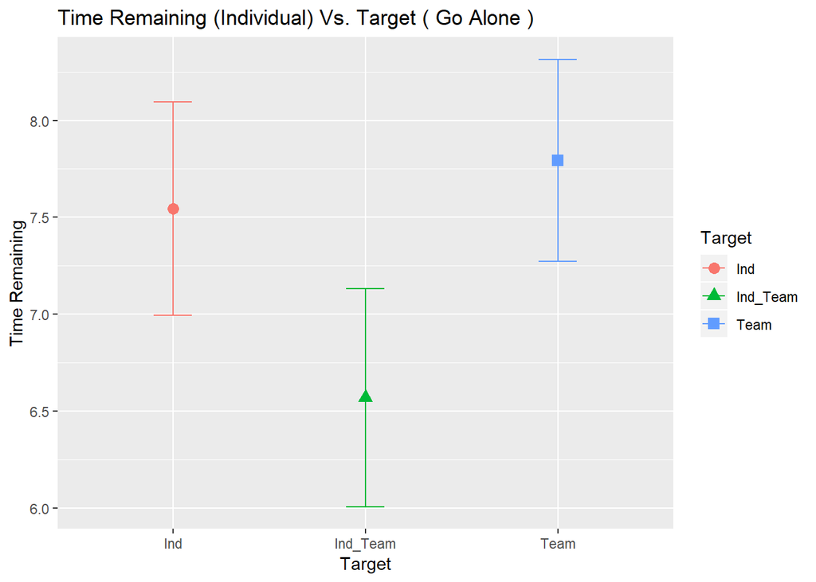

```r
y_label_ind <- params$dependent_response_name_WithSpace
setwd(figure_directory)

plot_data_ind <- ind_data %>%
  select(Target,
         SessionOrder,
         params$dependent_response_ind,
         params$dependent_response_DominateStrategy) %>%
  filter(.data[[params$dependent_response_DominateStrategy]] == params$Strategy_GA_name_WithSpace) %>%
  mutate(sqrt.value = sqrt(ifelse(.data[[params$dependent_response_ind]] < 0, 0, .data[[params$dependent_response_ind]]))) %>%
  group_by(Target) %>%
  summarise(Average = mean(.data[["sqrt.value"]]),
            Stdv =sd(.data[["sqrt.value"]]),
            n = length(.data[["sqrt.value"]]),
            StEr = sd(.data[["sqrt.value"]]) / sqrt(length(.data[["sqrt.value"]])))

ggplot(data = plot_data_ind, aes(x = Target, y = Average, color = Target, shape=Target, label = .data[["n"]])) +
  geom_point(size = 3) +
  geom_errorbar(aes(ymin = Average - StEr, ymax = Average + StEr), width = 0.2) +
  labs(y = y_label_ind, x = "Target", title = paste(params$dependent_response_name_WithSpace, "(Individual) Vs. Target (", params$Strategy_GA_name_WithSpace, ")")) +
  ggsave(filename = paste("InteractionPlot_", params$dependent_response_name_NoSpace, "_ByTarget_Avereaged_Over_SessionOrder", params$Strategy_GA_name_NoSpace, "_Ind.png", sep = ""))
```

```r
plot_data_ind %>%
  kable(caption = paste(params$Strategy_GA_name_WithSpace, "Data")) %>%
  kable_styling()
```

Go Alone Data

| Target | Average | Stdv | n | StEr |
| --- | --- | --- | --- | --- |
| Ind | 7.543771 | 4.673262 | 72 | 0.5507492 |
| Ind_Team | 6.570120 | 4.677772 | 69 | 0.5631375 |
| Team | 7.793989 | 4.426154 | 72 | 0.5216273 |

According to model.NoInteraction, there is a significant difference between Ind_Team and Team condition.

### Go Together interaction plot

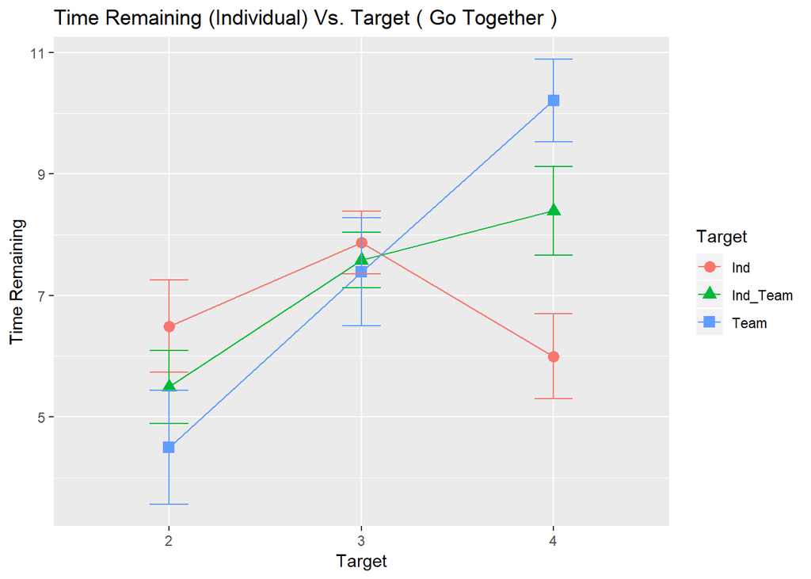

```r
y_label_ind <- params$dependent_response_name_WithSpace
setwd(figure_directory)

plot_data_ind <- ind_data %>%
  select(Target,
         SessionOrder,
         params$dependent_response_ind,
         params$dependent_response_DominateStrategy) %>%
  filter(.data[[params$dependent_response_DominateStrategy]] == params$Strategy_GT_name_WithSpace) %>%
  mutate(sqrt.value = sqrt(ifelse(.data[[params$dependent_response_ind]] < 0, 0, .data[[params$dependent_response_ind]]))) %>%
  group_by(SessionOrder, Target) %>%
  summarise(Average = mean(.data[["sqrt.value"]]),
            Stdv =sd(.data[["sqrt.value"]]),
            n = length(.data[["sqrt.value"]]),
            StEr = sd(.data[["sqrt.value"]]) / sqrt(length(.data[["sqrt.value"]])))

ggplot(data = plot_data_ind, aes(x = SessionOrder, y = Average, color = Target, shape=Target, label = .data[["n"]])) +
  geom_point(size = 3) +
  geom_line(aes(group=Target, color = Target)) +
  geom_errorbar(aes(ymin = Average - StEr, ymax = Average + StEr), width = 0.2) +
  labs(y = y_label_ind, x = "Target", title = paste(params$dependent_response_name_WithSpace, "(Individual) Vs. Target (", params$Strategy_GT_name_WithSpace, ")")) +
  ggsave(filename = paste("InteractionPlot_", params$dependent_response_name_NoSpace, "_BySessionOrder_ByTarget", params$Strategy_GT_name_NoSpace, "_Ind.png", sep = ""))
```

```r
plot_data_ind %>%
  kable(caption = paste(params$Strategy_GT_name_WithSpace, "Data")) %>%
  kable_styling()
```

Go Together Data

| SessionOrder | Target | Average | Stdv | n | StEr |
| --- | --- | --- | --- | --- | --- |
| 2 | Ind | 6.493520 | 3.210845 | 18 | 0.7568033 |
| 2 | Ind_Team | 5.493547 | 1.810104 | 9 | 0.6033678 |
| 2 | Team | 4.498584 | 3.234872 | 12 | 0.9338271 |
| 3 | Ind | 7.868804 | 1.793909 | 12 | 0.5178570 |
| 3 | Ind_Team | 7.581039 | 2.084303 | 21 | 0.4548322 |
| 3 | Team | 7.388527 | 3.454749 | 15 | 0.8920124 |
| 4 | Ind | 5.995766 | 2.709100 | 15 | 0.6994865 |
| 4 | Ind_Team | 8.394476 | 3.098871 | 18 | 0.7304109 |
| 4 | Team | 10.212493 | 2.889903 | 18 | 0.6811567 |

The results show a significant difference in the 4th session. Indicating that the time remaining at the individual level when in the Team condition is significantly higher than both the Ind and Ind_Team condtion.

# References

Field, A. P., & Wilcox, R. R. (2017). Robust statistical methods: A primer for clinical psychology and experimental psychopathology researchers. *Behaviour Research and Therapy*, *98*, 19–38. https://doi.org/10.1016/j.brat.2017.05.013

Galwey, N. W. (2014). Testing the assumptions of the analyses: Inspection of the residual values. In *Introduction to mixed modelling: Beyond regression and analysis of variance* (Second). Chichester, United Kingdom: John Wiley & Sons, Ltd.

Johnson, P. C. (2014). Extension of Nakagawa & Schielzeth’s R 2 GLMM to random slopes models. *Methods in Ecology and Evolution*, *5*(9), 944–946. https://doi.org/10.1111/2041-210X.12225

Nakagawa, S., & Schielzeth, H. (2013). A general and simple method for obtaining R 2 from generalized linear mixed-effects models. *Methods in Ecology and Evolution*, *4*(2), 133–142. https://doi.org/10.1111/j.2041-210x.2012.00261.x

Tukey, J. W. (1977). *Exploratory data analysis*. Reading, Mass.: Addison-Wesley Pub.